$\large\textbf{Future Prediction of Lyme Disease}$  
$\large\textbf{Through Machine Learning and Classification}$  
$\text{Colby Benedict}$  
$\textit{A thesis submitted in fulfillment of the requirements}$  
$\textit{for the degree of Bachelor of Arts}$  
$\textit{in}$  
$\text{Mathematics-Statistics and Individualized: Data Science}$  
$\textit{at the}$  
$\text{University of Connecticut}$  
$\text{June 8, 2020}$

# Acknowledgements

I would like to express my deepest appreciation to Dr. David I. Gregorio for his guidance and patience while serving as my Thesis supervisor. I am extremely grateful for the help and support I recieved from him throughout my research and writing process. My success and completion of my thesis would not have been possible without his encouragement and valuable knowledge. During trying times, he showed me enormous patience and understanding that words cannot do justice for. I truly cannot thank him enough.

I would also like to extend my deepest gratitude to Professor Wei Wei for his extensive knowledge and expertise that greatly assisted my research. His insight and constructive feedback inspired me to think deeper. For this, I am extremely grateful.

My sincere thanks go to Dr. Michael Cunningham for creating opportunities for me and gifting me with his generous wisdom and guidance that made this thesis possible. He is someone who never wavered in his support for my success. He was always available to answer my questions. His belief in me from the start means more to me than he could have ever imagined.

My heartfelt thanks go to Dr. Monica van Beusekom for her assistance with acceptance into the Individualized Major Program and throughout my journey. Her time and efforts are most sincerely appreciated.

Special thanks to my primary Data Science advisor Dr. Jun Yun who gave me useful advice, helped, and supported me, my Data Science and Statistics advisor Dr. Elizabeth Schifano, and Data Science advisor and Computational Genomics Professor Dr. Ion Mandoiu for helping me embark on my voyage and teaching me throughout.

## 1.1 Background

According to the Centers for Disease Control and Prevention (CDC), “Lyme disease is the most common vector-borne disease in the United States." [1] Living organisms that can transmit infectious pathogens, such as the pathogens that cause Lyme Disease, between humans, animals, or both are vectors. Some common vectors of disease include ticks, mosquitoes, and fleas. [2] Lyme Disease is known to be spread by certain hard-bodied ticks of genus Ixodes. According to the CDC, there is no credible evidence that Lyme disease can be transmitted through air, food, water, or from direct person-to-person contact, dogs or cats with Lyme disease directly to their owners, or bites by mosquitoes, flies, fleas, or lice. It is possible, but rare for a mother with untreated Lyme disease during pregnancy to have an infected placenta and spread the disease to the fetus. There is no increased risk of adverse birth outcomes when the pregnant mother with Lyme disease has an appropriate antibiotic treatment. There have been no cases of Lyme disease being linked to blood transfusion, but the Lyme disease bacteria has been found able to live in blood that is stored for donation. [3]

Lyme disease, also called Lyme borreliosis, is a tick-borne disease caused by the infection of bacteria of the genus Borrelia. Lyme disease is primarily caused by the bacterium Borrelia burgdorferi which is found in North America and Europe, Borrelia afzelii which is found in Europe and Asia, and Borrelia garinii which is also found in Europe and Asia. [6] Lyme disease predominantly occurs in temperate regions of the northern hemisphere. [4] In North America, Lyme disease is only known to be caused by Borrelia burgdorferi and Borrelia mayonii. Borrelia mayonii is a newer recognized and much less common Lyme disease causing species than Borrelia burgdorferi. [5,1]

The blacklegged tick Ixodes scapularis, commonly known as the deer tick, is the predominant vector that spreads Lyme disease in the Northeast and Midwest regions of the United States and some areas in middle southern and southeastern Canada. The western blacklegged tick Ixodes pacificus is the predominant vector that spreads Lyme disease on the United States Pacific Coast and West region of the United States. [3,4] Borrelia mayonii is known to be transmitted by the blacklegged tick Ixodes scapularis and found in the upper Midwest region of the United States. [6] Both Ixodes scapularis and Ixodes pacificus, the main tick vectors in North America, transmit Borrelia burgdorferi. [4] The two tick vectors in Europe known to transmit Lyme disease are Ixodes ricinus and Ixodes persulcatus. The main Lyme disease vector in Europe is Ixodes ricinus. While Ixodes ricinus spreads Lyme disease throughout Europe, Ixodes persulcatus spreads Lyme disease in eastern Europe. Ixodes ricinus ticks are known to transmit Borrelia burgdorferi. The tick Ixodes persulcatus is also found in western Russia, the Baltic countries, parts of Finland, central regions of eastern Russia, northern Mongolia, China, and Japan. Ixodes persulcatus transmits Borrelia afzelii and Borrelia garinii, but is not known to transmit Borrelia burgdorferi. [4] "[T]ick abundance and infection prevalence vary widely and are influenced by microclimate, vegetation and the abundance of reservoir vertebrate hosts." [4] The region of the United States with the most intense transmission of B. burgdorferi is the Northeast, "where the prevalence of B. burgdorferi infection among ticks can be as high as 40-50%", whereas, "infection prevalence in the southern United States is less than 1%." [4] The map below shows the prevalence of Lyme disease cases among people residing in the United States.

[figure not shown]

Figure 1. Map of the 2018 reported cases of Lyme Disease in the United States. Image retrieved from the Centers for Disease Control and Prevention [7].

According to annual reported Lyme disease case count data for counties in the United States for the years 2000-2018 retrieved from the CDC, there are approximately 9 reported cases of Lyme disease on average per county per year from 2000-2018. In the Northeast, United States there are approximately 95 reported cases of Lyme disease on average per county per year from 2000-2018 and in Connecticut there are approximately 281 reported cases of Lyme disease on average per county per year from 2000-2018 (shown in 3.2). There are on average approximately 29,406 reported cases of Lyme disease each year in the United States (shown in 2.1.4). While those are the reported cases of Lyme disease from the CDC's public use dataset, research done by the CDC has an estimate that over 300,000 people are likely diagnosed and treated each year in the United States. "Lyme disease is an infection spread by the bite of ticks that causes more than 300,000 illnesses each year in the United States. It is the most commonly occurring vector-borne disease and the sixth most commonly reported notifiable infectious disease." [8] Hence, knowing more about the ticks that spread the disease and how they spread it is useful when trying to come up with factors that might affect the amount of reported cases of Lyme disease. "Improved prevention methods against Lyme disease are one of CDC’s key priorities." [8] One reason the CDC says improved prevention methods are needed because the "number of cases of Lyme disease reported to CDC has increased steadily over the past 25 years." [8] More information on why the CDC is concered about Lyme disease and what they and their partners are doing about it can be found on the CDC's website: https://www.cdc.gov/lyme/why-is-cdc-concerned-about-lyme-disease.html

Lyme disease can produce a wide range of symptoms, which can also depend on the stage of infection. These include fever, rash, facial paralysis, arthritis, heart palpitations or an irregular heart beat (Lyme carditis),and inflammation of the brain and spinal cord. [9] There are treatments for Lyme disease and antibiotics that can get rid of an infection, however, patients can sometimes have symptoms of pain, fatigue, or difficulty thinking that lasts for more than 6 months after they finish treatment. This condition is called Post-Treatment Lyme Disease Syndrome (PTLDS). [10] Also, someone may have a heart attack due to a Lyme disease infection which even though their Lyme disease infection may go away after treatment, they may have permanent damage to the heart.

The CDC states "Ticks live in grassy, brushy, or wooded areas, or even on animals." [11] Activities done outside such as walking a dog, camping, gardening, and hiking could bring people in close contact with ticks. "Many people get ticks in their own yard or neighborhood." [11] Walking in wooded and brushy areas with high grass and leaf litter may also increase the chance of a tick climbing aboard since ticks wait for a host on the tips of grasses and shrubs, and many ticks, such as blacklegged ticks, wait in a position known as “questing”. [11] Ticks can’t fly or jump, but while questing they hold onto leaves and grass by their lower, or third and fourth, pair of legs and hold the upper, or first, pair of legs outstretched, waiting to climb onto the host. When a host brushes the spot where a tick is waiting, it quickly climbs aboard then finds a suitable place to bite its host. [12, 3]

Once a tick has found its feeding spot on a host's body, it grasps onto the skin, cutting into the surface, then inserts its feeding tube into the host. Not only can the feeding tube have barbs that help keep the tick in place, ticks can also secrete small amounts of saliva with anesthetic properties so that its host cannot feel that the tick has attached itself. Ticks can attach to any part of the human body, but prefer warm, moist areas, often found in the groin, armpits, and scalp which can be difficult to see. Consequently, a tiny tick can easily go unnoticed. Unsurprisingly, most humans become infected with the Lyme disease bacteria through the bites of nymphs as they are less than 2 mm in size. Ticks in this stage feed during the spring and summer, while the adult Ixodes ticks are most active during the cooler months of the year any time temperatures are above freezing. Adult ticks can also transmit Lyme disease bacteria, but they are much larger, thus, more likely to be discovered and removed before they have had time to transmit the bacteria. A tick will suck the blood slowly for several days if they are not removed. In most cases, the tick must be attached for at least 36 to 48 hours before the Lyme disease bacterium can be transmitted. After feeding, most ticks will drop off and prepare for the next life stage. [3]

While ticks are sucking on an infected host's (human or animal) blood, they ingest disease-producing microorganisms from their host which they can later transmit into a new host during their subsequent meal as small amounts of saliva from the tick can enter the skin of the host during the feeding process [12]. Once a vector becomes infectious, they are often capable of transmitting the pathogen for the rest of their life to whomever's blood they feed on. [2] The lifecycle of Ixodes scapularis ticks generally lasts two years and the lifecycle of Ixodes pacificus ticks generally lasts three years. These ticks go through four life stages: egg, larva, nymph, and adult. After the tick eggs hatch, they must feed on blood at every stage to survive and need a new host at each stage of their life. These hosts include mammals, birds, reptiles, and amphibians. [12] Diagrams of the lifecycles of these two vectors, Ixodes scapularis and Ixodes pacificus, that spread Lyme disease in the United States can be found in Figure 2 and Figure 3. After hatching, the ticks are very close in appearance between each stage, with size being the primary factor in change of appearance between the stages. [12]

[figure not shown]

Figure 2. Lifecycle of the Ixodes scapularis (blacklegged tick). Image retrieved from the Centers for Disease Control and Prevention [12].

[figure not shown]

Figure 3. Lifecycle of the Ixodes pacificus (Western Blacklegged tick). Image retrieved from the Centers for Disease Control and Prevention [12].

## 1.2 Purpose

The purpose of this project is to apply data science in Lyme disease classification for the future prediction of United States county-level Lyme disease class frequencies and counts through machine learning and modeling, statistical analysis and computing, and data analytics to better understand Lyme disease and its prevelance and to develop a tool that can be grown upon or used to help prepare for the future.

## 1.3 Setup

This project was completed in a Jupyter Notebook hosted by Google Colaboratory (Colab) [13] and finished using Anaconda [14]. "The Jupyter Notebook is an open-source web application that allows [the user] to create and share documents that contain live code, equations, visualizations, and narrative text." [15] With Jupyter Notebooks, I was able to clean, transform, and visualize the data I gathered, and perform statistical modeling and machine learning using the Python [16] programing language for my project's purpose.

The following code is the setup which includes some of the package imports used in this project. The NumPy [17] and pandas [18] packages were for storing and manipulating data, imbalanced-learn (imblearn) [19] was used for resampling, Scikit-learn (sklearn) [20] was used for building models and evaluating them, and matplotlib [21] was used for plotting and visualizations.

```python
# Python ≥3.5
import sys
assert sys.version_info >= (3, 5)

# Scikit-Learn ≥0.20 is required
import sklearn
assert sklearn.__version__ >= "0.20"

# Common imports
import numpy as np
import os
import pandas as pd

# For resampling
import imblearn
# check version number
print(imblearn.__version__)

# To make this notebook's output stable across runs
np.random.seed(42)

# To plot pretty figures
%matplotlib inline
import matplotlib as mpl
import matplotlib.pyplot as plt
mpl.rc('axes', labelsize=14)
mpl.rc('xtick', labelsize=12)
mpl.rc('ytick', labelsize=12)
```

```
0.4.3
```

Note that there were some minor errors found in some of the downloaded data that were fixed manually in excel and code was rerun. Such fixes done in Excel not explicitly shown include fixing the mispelling of 'Lousiana' in the Lyme Disease dataset to 'Louisiana' and removing an extra space in one of the state names in another dataset.

## 2.1 Lyme Disease Case Count Data

### 2.1.1 Gathering and Cleaning

The data for the reported county-level annual case counts of Lyme Disease in the United States was retrieved from the Centers for Disease Control and Prevention. [30] I downloaded their public use dataset that consists of data shared by the National Notifiable Diseases Surveillance System (NNDSS) to the CDC. This dataset the CDC developed provides the number of reported cases by county, or county equivalent, in the United States for the years 2000-2018. "Reports of Lyme disease are collected and verified by state and local health departments in accordance with their legal mandate and surveillance practices." [22] "Final annual case counts are published when the year is over and all states and territories have verified their data, typically in the fall of the following year." [22] How the data is collected, the rules of collection, and Lyme disease case definitions which have changed over the years can be found on the CDC's website with the following link: https://wwwn.cdc.gov/nndss/conditions/lyme-disease/ . "Lyme disease has been a nationally notifiable condition in the United States since 1991." Following its implementation in 1991, the national surveillance case definition for Lyme disease was modified in 1996, 2008, 2011, and 2017. The changes were generally minor, but may have had some impact on surveillance. [22] The dataset's 2000-2007 case counts reflect the surveillance case definition in place during that time. "Data from 2008 to the present reflect the case definition which allowed for reporting of "confirmed" and "probable" cases. County codes of "999" represent "unknown" county of residence within each state. [22]

Some limitations of surveillance data (as described by the CDC):

> 1. Not every case of Lyme disease is reported to the CDC, and some cases that are reported may be due to another cause. Under-reporting is more likely to occur in highly endemic areas, whereas over-reporting is more likely to occur in non-endemic areas. 2. Surveillance data are subject to each state’s abilities to capture and classify cases, which are dependent upon budget and personnel and varies not only between states, but also from year to year within a given state. Consequently, a sudden or marked change in reported cases does not necessarily represent a true change in disease incidence, and should not be construed as such without knowledge of that state’s historical surveillance practices. 3. Surveillance data are captured by county of residence, not county of exposure. 4. States may close their annual surveillance dataset at a different time than CDC. Thus, the final case counts published by CDC may not exactly match numbers published by each state agency for a given year. [22]

The following code block is the code used to read the CDC Lyme disease case counts comma-separated values (CSV) file into a Pandas DataFrame.

```python
LDcounts_df = pd.read_csv("LD-Case-Counts-by-County-00-18.csv",
                          encoding='latin-1')
```

This is what the top part of the Lyme disease case count data retrieved from the CDC looked like:

```python
LDcounts_df.head()
```

|  | Ctyname | Stname | STCODE | CTYCODE | Cases2000 | Cases2001 | Cases2002 | Cases2003 | Cases2004 | Cases2005 | Cases2006 | Cases2007 | Cases2008 | Cases2009 | Cases2010 | Cases2011 | Cases2012 | Cases2013 | Cases2014 | Cases2015 | Cases2016 | Cases2017 | Cases2018 |
| --- | --- | --- | --- | --- | --- | --- | --- | --- | --- | --- | --- | --- | --- | --- | --- | --- | --- | --- | --- | --- | --- | --- | --- |
| 0 | Autauga County | Alabama | 1 | 1 | 0 | 0 | 0 | 0 | 0 | 0 | 0 | 0 | 0 | 0 | 0 | 0 | 0 | 0 | 0 | 0 | 2 | 0 | 0 |
| 1 | Baldwin County | Alabama | 1 | 3 | 1 | 0 | 1 | 0 | 0 | 0 | 0 | 0 | 0 | 1 | 0 | 1 | 1 | 0 | 3 | 1 | 2 | 2 | 0 |
| 2 | Barbour County | Alabama | 1 | 5 | 0 | 0 | 0 | 0 | 0 | 0 | 0 | 0 | 0 | 0 | 0 | 1 | 0 | 0 | 0 | 0 | 0 | 0 | 0 |
| 3 | Bibb County | Alabama | 1 | 7 | 0 | 0 | 0 | 0 | 0 | 0 | 0 | 0 | 0 | 0 | 0 | 0 | 0 | 0 | 1 | 0 | 0 | 0 | 1 |
| 4 | Blount County | Alabama | 1 | 9 | 0 | 0 | 0 | 0 | 0 | 0 | 0 | 0 | 0 | 0 | 0 | 1 | 0 | 0 | 0 | 0 | 0 | 0 | 2 |

There were 23 columns in the dataset. The first column gave the name of the county or county equivalent. The second column gave the state in which the county or county equivalent was in. The third column was the state FIPS code. The fourth column was the county or county equivalent FIPS code. County codes of “999” represented “unknown” county of residence within each state. The fifth through twenty-third columns gave the Lyme disease case counts per year for the years 2000-2018.

Using `LDcounts_df.info()` showed that there was no missing (null) data and that there were 3,193 entries, meaning there was data for 3,143 counties or county equivalents since there are 50 states in United States so had 3,193-50=3,143 counties or county equivalents when state unknowns were removed.

```python
LDcounts_df.info()
```

```
<class 'pandas.core.frame.DataFrame'>
RangeIndex: 3193 entries, 0 to 3192
Data columns (total 23 columns):
 #   Column     Non-Null Count  Dtype
---  ------     --------------  -----
 0   Ctyname    3193 non-null   object
 1   Stname     3193 non-null   object
 2   STCODE     3193 non-null   int64
 3   CTYCODE    3193 non-null   int64
 4   Cases2000  3193 non-null   int64
 5   Cases2001  3193 non-null   int64
 6   Cases2002  3193 non-null   int64
 7   Cases2003  3193 non-null   int64
 8   Cases2004  3193 non-null   int64
 9   Cases2005  3193 non-null   int64
 10  Cases2006  3193 non-null   int64
 11  Cases2007  3193 non-null   int64
 12  Cases2008  3193 non-null   int64
 13  Cases2009  3193 non-null   int64
 14  Cases2010  3193 non-null   int64
 15  Cases2011  3193 non-null   int64
 16  Cases2012  3193 non-null   int64
 17  Cases2013  3193 non-null   int64
 18  Cases2014  3193 non-null   int64
 19  Cases2015  3193 non-null   int64
 20  Cases2016  3193 non-null   int64
 21  Cases2017  3193 non-null   int64
 22  Cases2018  3193 non-null   int64
dtypes: int64(21), object(2)
memory usage: 573.9+ KB
```

The following code created a new dataframe of the Lyme disease dataset where the state "unknowns" were removed.

```python
# Get indices for which column CTYCODE == 999 (indices of unknown)
stateIndices = LDcounts_df[LDcounts_df['CTYCODE'] == 999].index

# Create new dataframe with the unknown data removed
LDcounts_cty_df = LDcounts_df.drop(stateIndices).reset_index(drop=True)
```

```python
print(LDcounts_cty_df.shape) #(number of rows, number of columns)
LDcounts_cty_df.head() #dataframe without unknowns
```

```
(3143, 23)
```

|  | Ctyname | Stname | STCODE | CTYCODE | Cases2000 | Cases2001 | Cases2002 | Cases2003 | Cases2004 | Cases2005 | Cases2006 | Cases2007 | Cases2008 | Cases2009 | Cases2010 | Cases2011 | Cases2012 | Cases2013 | Cases2014 | Cases2015 | Cases2016 | Cases2017 | Cases2018 |
| --- | --- | --- | --- | --- | --- | --- | --- | --- | --- | --- | --- | --- | --- | --- | --- | --- | --- | --- | --- | --- | --- | --- | --- |
| 0 | Autauga County | Alabama | 1 | 1 | 0 | 0 | 0 | 0 | 0 | 0 | 0 | 0 | 0 | 0 | 0 | 0 | 0 | 0 | 0 | 0 | 2 | 0 | 0 |
| 1 | Baldwin County | Alabama | 1 | 3 | 1 | 0 | 1 | 0 | 0 | 0 | 0 | 0 | 0 | 1 | 0 | 1 | 1 | 0 | 3 | 1 | 2 | 2 | 0 |
| 2 | Barbour County | Alabama | 1 | 5 | 0 | 0 | 0 | 0 | 0 | 0 | 0 | 0 | 0 | 0 | 0 | 1 | 0 | 0 | 0 | 0 | 0 | 0 | 0 |
| 3 | Bibb County | Alabama | 1 | 7 | 0 | 0 | 0 | 0 | 0 | 0 | 0 | 0 | 0 | 0 | 0 | 0 | 0 | 0 | 1 | 0 | 0 | 0 | 1 |
| 4 | Blount County | Alabama | 1 | 9 | 0 | 0 | 0 | 0 | 0 | 0 | 0 | 0 | 0 | 0 | 0 | 1 | 0 | 0 | 0 | 0 | 0 | 0 | 2 |

The output of the `shape` function showed there was indeed data for 3,143 counties or county equivalents.

The following code created and displayed the data for each state's cases of unknown residence.

```python
# Create dataframe of only unknowns
LDcounts_uk_df = pd.DataFrame(LDcounts_df[LDcounts_df['CTYCODE'] == 999]) #dataframe of only unknowns
LDcounts_uk_df.reset_index(inplace=True)
LDcounts_uk_df
```

|  | index | Ctyname | Stname | STCODE | CTYCODE | Cases2000 | Cases2001 | Cases2002 | Cases2003 | Cases2004 | Cases2005 | Cases2006 | Cases2007 | Cases2008 | Cases2009 | Cases2010 | Cases2011 | Cases2012 | Cases2013 | Cases2014 | Cases2015 | Cases2016 | Cases2017 | Cases2018 |
| --- | --- | --- | --- | --- | --- | --- | --- | --- | --- | --- | --- | --- | --- | --- | --- | --- | --- | --- | --- | --- | --- | --- | --- | --- |
| 0 | 67 | Alabama | Alabama | 1 | 999 | 0 | 0 | 0 | 0 | 0 | 0 | 0 | 1 | 0 | 0 | 0 | 0 | 0 | 0 | 0 | 0 | 0 | 1 | 0 |
| 1 | 97 | Alaska | Alaska | 2 | 999 | 0 | 0 | 0 | 0 | 0 | 0 | 0 | 0 | 0 | 0 | 0 | 0 | 1 | 1 | 0 | 0 | 0 | 0 | 0 |
| 2 | 113 | Arizona | Arizona | 4 | 999 | 0 | 0 | 0 | 0 | 0 | 0 | 0 | 0 | 0 | 0 | 0 | 0 | 0 | 0 | 0 | 0 | 0 | 0 | 0 |
| 3 | 189 | Arkansas | Arkansas | 5 | 999 | 0 | 0 | 0 | 0 | 0 | 0 | 0 | 0 | 0 | 0 | 0 | 0 | 0 | 0 | 0 | 0 | 0 | 1 | 0 |
| 4 | 248 | California | California | 6 | 999 | 0 | 0 | 0 | 0 | 0 | 0 | 0 | 0 | 0 | 0 | 0 | 0 | 0 | 0 | 0 | 0 | 0 | 0 | 0 |
| 5 | 313 | Colorado | Colorado | 8 | 999 | 0 | 0 | 0 | 0 | 0 | 0 | 0 | 0 | 0 | 0 | 0 | 0 | 0 | 0 | 0 | 0 | 0 | 0 | 0 |
| 6 | 322 | Connecticut | Connecticut | 9 | 999 | 111 | 122 | 135 | 52 | 47 | 57 | 32 | 704 | 1635 | 1126 | 1448 | 1432 | 1402 | 597 | 49 | 33 | 20 | 68 | 16 |
| 7 | 326 | Delaware | Delaware | 10 | 999 | 0 | 0 | 0 | 0 | 66 | 50 | 16 | 27 | 30 | 21 | 37 | 34 | 38 | 29 | 32 | 36 | 59 | 45 | 33 |
| 8 | 395 | Florida | Florida | 12 | 999 | 0 | 0 | 0 | 0 | 0 | 0 | 0 | 0 | 0 | 0 | 0 | 0 | 0 | 0 | 0 | 0 | 0 | 0 | 0 |
| 9 | 555 | Georgia | Georgia | 13 | 999 | 0 | 0 | 0 | 0 | 0 | 0 | 0 | 0 | 0 | 0 | 0 | 1 | 0 | 0 | 0 | 0 | 0 | 0 | 0 |
| 10 | 561 | Hawaii | Hawaii | 15 | 999 | 0 | 0 | 0 | 0 | 0 | 0 | 0 | 0 | 0 | 0 | 0 | 0 | 0 | 0 | 0 | 0 | 0 | 0 | 0 |
| 11 | 606 | Idaho | Idaho | 16 | 999 | 0 | 0 | 0 | 0 | 0 | 0 | 1 | 0 | 0 | 0 | 0 | 0 | 0 | 0 | 0 | 0 | 0 | 0 | 0 |
| 12 | 709 | Illinois | Illinois | 17 | 999 | 0 | 0 | 0 | 0 | 0 | 0 | 0 | 0 | 0 | 0 | 0 | 0 | 0 | 0 | 0 | 0 | 0 | 0 | 0 |
| 13 | 802 | Indiana | Indiana | 18 | 999 | 0 | 0 | 0 | 0 | 0 | 0 | 0 | 0 | 0 | 16 | 12 | 10 | 7 | 19 | 15 | 26 | 32 | 0 | 0 |
| 14 | 902 | Iowa | Iowa | 19 | 999 | 0 | 0 | 0 | 0 | 0 | 0 | 0 | 0 | 0 | 0 | 0 | 0 | 0 | 0 | 0 | 0 | 0 | 0 | 0 |
| 15 | 1008 | Kansas | Kansas | 20 | 999 | 0 | 0 | 0 | 0 | 0 | 0 | 0 | 0 | 0 | 0 | 0 | 0 | 0 | 0 | 0 | 0 | 0 | 0 | 0 |
| 16 | 1129 | Kentucky | Kentucky | 21 | 999 | 0 | 0 | 0 | 0 | 0 | 0 | 0 | 0 | 0 | 0 | 0 | 0 | 9 | 24 | 0 | 1 | 17 | 13 | 11 |
| 17 | 1194 | Louisiana | Louisiana | 22 | 999 | 0 | 1 | 0 | 0 | 0 | 0 | 0 | 0 | 0 | 0 | 0 | 0 | 0 | 0 | 0 | 0 | 0 | 0 | 0 |
| 18 | 1211 | Maine | Maine | 23 | 999 | 1 | 0 | 3 | 2 | 0 | 0 | 2 | 0 | 4 | 0 | 0 | 0 | 0 | 0 | 0 | 0 | 0 | 0 | 3 |
| 19 | 1236 | Maryland | Maryland | 24 | 999 | 0 | 0 | 0 | 0 | 0 | 0 | 1 | 15 | 0 | 3 | 0 | 1 | 3 | 0 | 1 | 0 | 0 | 3 | 0 |
| 20 | 1251 | Massachusetts | Massachusetts | 25 | 999 | 7 | 0 | 16 | 2 | 0 | 18 | 28 | 239 | 587 | 1103 | 711 | 416 | 600 | 224 | 208 | 142 | 0 | 5 | 0 |
| 21 | 1335 | Michigan | Michigan | 26 | 999 | 0 | 0 | 0 | 0 | 0 | 0 | 0 | 0 | 0 | 0 | 0 | 0 | 0 | 0 | 0 | 0 | 0 | 0 | 0 |
| 22 | 1423 | Minnesota | Minnesota | 27 | 999 | 3 | 0 | 0 | 0 | 0 | 0 | 0 | 0 | 0 | 0 | 0 | 87 | 1 | 0 | 0 | 0 | 0 | 1 | 0 |
| 23 | 1506 | Mississippi | Mississippi | 28 | 999 | 0 | 0 | 0 | 0 | 0 | 0 | 0 | 0 | 0 | 0 | 0 | 0 | 0 | 0 | 0 | 0 | 0 | 0 | 0 |
| 24 | 1622 | Missouri | Missouri | 29 | 999 | 0 | 0 | 0 | 0 | 0 | 0 | 0 | 0 | 0 | 0 | 0 | 0 | 0 | 0 | 0 | 0 | 0 | 0 | 0 |
| 25 | 1679 | Montana | Montana | 30 | 999 | 0 | 0 | 0 | 0 | 0 | 0 | 0 | 0 | 0 | 0 | 0 | 0 | 0 | 7 | 2 | 1 | 8 | 3 | 0 |
| 26 | 1773 | Nebraska | Nebraska | 31 | 999 | 0 | 0 | 0 | 0 | 0 | 0 | 0 | 0 | 0 | 1 | 0 | 0 | 0 | 0 | 0 | 1 | 0 | 1 | 0 |
| 27 | 1791 | Nevada | Nevada | 32 | 999 | 0 | 0 | 0 | 0 | 0 | 1 | 0 | 0 | 0 | 0 | 0 | 0 | 4 | 0 | 0 | 0 | 0 | 0 | 1 |
| 28 | 1802 | New Hampshire | New Hampshire | 33 | 999 | 0 | 0 | 0 | 0 | 0 | 0 | 0 | 0 | 7 | 0 | 0 | 0 | 0 | 8 | 50 | 13 | 39 | 63 | 51 |
| 29 | 1824 | New Jersey | New Jersey | 34 | 999 | 0 | 3 | 1 | 0 | 0 | 1 | 2 | 7 | 26 | 6 | 1 | 4 | 3 | 0 | 1 | 1 | 1 | 1 | 0 |
| 30 | 1858 | New Mexico | New Mexico | 35 | 999 | 0 | 0 | 0 | 0 | 0 | 0 | 0 | 0 | 0 | 0 | 0 | 0 | 0 | 0 | 0 | 0 | 0 | 0 | 0 |
| 31 | 1921 | New York | New York | 36 | 999 | 0 | 0 | 0 | 0 | 0 | 0 | 0 | 0 | 0 | 0 | 0 | 0 | 0 | 0 | 0 | 0 | 0 | 0 | 0 |
| 32 | 2022 | North Carolina | North Carolina | 37 | 999 | 0 | 0 | 0 | 0 | 0 | 0 | 0 | 0 | 0 | 0 | 0 | 0 | 0 | 0 | 0 | 0 | 0 | 0 | 0 |
| 33 | 2076 | North Dakota | North Dakota | 38 | 999 | 0 | 0 | 0 | 0 | 0 | 0 | 0 | 0 | 0 | 0 | 0 | 0 | 0 | 0 | 0 | 0 | 0 | 0 | 0 |
| 34 | 2165 | Ohio | Ohio | 39 | 999 | 0 | 0 | 0 | 0 | 0 | 0 | 0 | 0 | 0 | 0 | 1 | 0 | 0 | 0 | 0 | 0 | 0 | 0 | 0 |
| 35 | 2243 | Oklahoma | Oklahoma | 40 | 999 | 0 | 0 | 0 | 0 | 0 | 0 | 0 | 0 | 0 | 0 | 0 | 0 | 0 | 0 | 0 | 0 | 0 | 0 | 0 |
| 36 | 2280 | Oregon | Oregon | 41 | 999 | 0 | 0 | 0 | 0 | 0 | 0 | 0 | 0 | 0 | 0 | 0 | 0 | 0 | 0 | 0 | 0 | 0 | 0 | 0 |
| 37 | 2348 | Pennsylvania | Pennsylvania | 42 | 999 | 13 | 17 | 30 | 0 | 0 | 0 | 0 | 0 | 0 | 0 | 0 | 0 | 0 | 0 | 0 | 0 | 0 | 0 | 0 |
| 38 | 2354 | Rhode Island | Rhode Island | 44 | 999 | 24 | 22 | 111 | 33 | 19 | 4 | 0 | 0 | 40 | 11 | 8 | 0 | 3 | 0 | 0 | 3 | 0 | 0 | 0 |
| 39 | 2401 | South Carolina | South Carolina | 45 | 999 | 0 | 0 | 0 | 0 | 0 | 0 | 1 | 4 | 7 | 18 | 4 | 3 | 1 | 0 | 0 | 0 | 0 | 0 | 0 |
| 40 | 2468 | South Dakota | South Dakota | 46 | 999 | 0 | 0 | 0 | 0 | 0 | 0 | 0 | 0 | 0 | 0 | 0 | 0 | 0 | 0 | 0 | 0 | 0 | 0 | 0 |
| 41 | 2564 | Tennessee | Tennessee | 47 | 999 | 0 | 0 | 0 | 0 | 0 | 0 | 0 | 2 | 0 | 0 | 0 | 4 | 4 | 3 | 0 | 4 | 2 | 5 | 6 |
| 42 | 2819 | Texas | Texas | 48 | 999 | 0 | 0 | 0 | 1 | 7 | 0 | 0 | 0 | 0 | 0 | 0 | 0 | 0 | 4 | 0 | 0 | 0 | 0 | 0 |
| 43 | 2849 | Utah | Utah | 49 | 999 | 0 | 0 | 0 | 0 | 0 | 0 | 0 | 0 | 0 | 0 | 0 | 0 | 0 | 0 | 2 | 1 | 0 | 2 | 0 |
| 44 | 2864 | Vermont | Vermont | 50 | 999 | 0 | 0 | 0 | 0 | 0 | 0 | 0 | 0 | 0 | 0 | 0 | 0 | 0 | 2 | 0 | 0 | 18 | 3 | 1 |
| 45 | 2999 | Virginia | Virginia | 51 | 999 | 0 | 0 | 0 | 0 | 0 | 0 | 0 | 2 | 7 | 58 | 199 | 93 | 0 | 94 | 46 | 93 | 89 | 134 | 34 |
| 46 | 3039 | Washington | Washington | 53 | 999 | 0 | 0 | 0 | 0 | 0 | 0 | 0 | 0 | 0 | 0 | 0 | 0 | 0 | 0 | 0 | 0 | 0 | 0 | 0 |
| 47 | 3095 | West Virginia | West Virginia | 54 | 999 | 0 | 0 | 0 | 0 | 0 | 0 | 0 | 0 | 0 | 0 | 0 | 4 | 4 | 6 | 1 | 125 | 137 | 71 | 148 |
| 48 | 3168 | Wisconsin | Wisconsin | 55 | 999 | 1 | 0 | 1 | 0 | 0 | 0 | 0 | 1 | 36 | 0 | 0 | 0 | 2 | 215 | 2 | 6 | 1 | 2 | 2 |
| 49 | 3192 | Wyoming | Wyoming | 56 | 999 | 0 | 0 | 0 | 0 | 0 | 0 | 0 | 0 | 0 | 0 | 0 | 1 | 1 | 1 | 0 | 0 | 0 | 0 | 0 |

Data for 50 states was shown as expected.

District of Columbia's Lyme disease case counts for the years 2011 and 2012 were 0, while in 2010 there were 42 reported cases and in 2013 there were 35 reported cases and there were always at least 10 cases for each of the other years. I do not believe this necessarily represented a true change in the cases of Lyme disease for the District of Columbia for the years 2011 and 2012. Maybe more cases actually occured during that year and that other data might have had similar situations as well that could affect classification.

```python
LDcounts_df[LDcounts_df["Stname"]=="District of Columbia"]
```

|  | Ctyname | Stname | STCODE | CTYCODE | Cases2000 | Cases2001 | Cases2002 | Cases2003 | Cases2004 | Cases2005 | Cases2006 | Cases2007 | Cases2008 | Cases2009 | Cases2010 | Cases2011 | Cases2012 | Cases2013 | Cases2014 | Cases2015 | Cases2016 | Cases2017 | Cases2018 |
| --- | --- | --- | --- | --- | --- | --- | --- | --- | --- | --- | --- | --- | --- | --- | --- | --- | --- | --- | --- | --- | --- | --- | --- |
| 327 | District of Columbia | District of Columbia | 11 | 1 | 11 | 17 | 25 | 14 | 16 | 10 | 62 | 116 | 74 | 61 | 42 | 0 | 0 | 35 | 40 | 121 | 103 | 84 | 79 |

I thought maybe since Washington, D.C. is not considered part of a state, the "unknowns" in Virginia or Maryland, since they border the District of Columbia,might possibly contain some of the counts for the District of Columbia. The reporting for Virginia's "unknowns" seems somewhat inconsistent as the yearly counts range from 0 to 199 "unknowns". The "unknown" counts for Maryland are mostly 0, 1, or 3, with one year having 15, so definitely not as many "unknown" counts as Virginia. The District of Columbia case counts and Maryland's and Virginia's "unknown" counts are shown below.

```python
LDcounts_df[(LDcounts_df["Stname"]=="District of Columbia") |
            ((LDcounts_df["Stname"]=="Virginia") &
             (LDcounts_df["CTYCODE"]==999)) |
            ((LDcounts_df["Stname"]=="Maryland") &
             (LDcounts_df["CTYCODE"]==999))]
```

|  | Ctyname | Stname | STCODE | CTYCODE | Cases2000 | Cases2001 | Cases2002 | Cases2003 | Cases2004 | Cases2005 | Cases2006 | Cases2007 | Cases2008 | Cases2009 | Cases2010 | Cases2011 | Cases2012 | Cases2013 | Cases2014 | Cases2015 | Cases2016 | Cases2017 | Cases2018 |
| --- | --- | --- | --- | --- | --- | --- | --- | --- | --- | --- | --- | --- | --- | --- | --- | --- | --- | --- | --- | --- | --- | --- | --- |
| 327 | District of Columbia | District of Columbia | 11 | 1 | 11 | 17 | 25 | 14 | 16 | 10 | 62 | 116 | 74 | 61 | 42 | 0 | 0 | 35 | 40 | 121 | 103 | 84 | 79 |
| 1236 | Maryland | Maryland | 24 | 999 | 0 | 0 | 0 | 0 | 0 | 0 | 1 | 15 | 0 | 3 | 0 | 1 | 3 | 0 | 1 | 0 | 0 | 3 | 0 |
| 2999 | Virginia | Virginia | 51 | 999 | 0 | 0 | 0 | 0 | 0 | 0 | 0 | 2 | 7 | 58 | 199 | 93 | 0 | 94 | 46 | 93 | 89 | 134 | 34 |

The code below found the states that have at least one unknown from 2000 to 2018.

```python
i = LDcounts_uk_df[LDcounts_uk_df.loc[:, LDcounts_uk_df.columns[5:]].sum(axis=1) != 0]
print("Number of states who reported at least one unknown from 2000 to 2018:", len(i))
i # state data of unknown county where case count total >0
```

```
Number of states who reported at least one unknown from 2000 to 2018: 31
```

|  | index | Ctyname | Stname | STCODE | CTYCODE | Cases2000 | Cases2001 | Cases2002 | Cases2003 | Cases2004 | Cases2005 | Cases2006 | Cases2007 | Cases2008 | Cases2009 | Cases2010 | Cases2011 | Cases2012 | Cases2013 | Cases2014 | Cases2015 | Cases2016 | Cases2017 | Cases2018 |
| --- | --- | --- | --- | --- | --- | --- | --- | --- | --- | --- | --- | --- | --- | --- | --- | --- | --- | --- | --- | --- | --- | --- | --- | --- |
| 0 | 67 | Alabama | Alabama | 1 | 999 | 0 | 0 | 0 | 0 | 0 | 0 | 0 | 1 | 0 | 0 | 0 | 0 | 0 | 0 | 0 | 0 | 0 | 1 | 0 |
| 1 | 97 | Alaska | Alaska | 2 | 999 | 0 | 0 | 0 | 0 | 0 | 0 | 0 | 0 | 0 | 0 | 0 | 0 | 1 | 1 | 0 | 0 | 0 | 0 | 0 |
| 3 | 189 | Arkansas | Arkansas | 5 | 999 | 0 | 0 | 0 | 0 | 0 | 0 | 0 | 0 | 0 | 0 | 0 | 0 | 0 | 0 | 0 | 0 | 0 | 1 | 0 |
| 6 | 322 | Connecticut | Connecticut | 9 | 999 | 111 | 122 | 135 | 52 | 47 | 57 | 32 | 704 | 1635 | 1126 | 1448 | 1432 | 1402 | 597 | 49 | 33 | 20 | 68 | 16 |
| 7 | 326 | Delaware | Delaware | 10 | 999 | 0 | 0 | 0 | 0 | 66 | 50 | 16 | 27 | 30 | 21 | 37 | 34 | 38 | 29 | 32 | 36 | 59 | 45 | 33 |
| 9 | 555 | Georgia | Georgia | 13 | 999 | 0 | 0 | 0 | 0 | 0 | 0 | 0 | 0 | 0 | 0 | 0 | 1 | 0 | 0 | 0 | 0 | 0 | 0 | 0 |
| 11 | 606 | Idaho | Idaho | 16 | 999 | 0 | 0 | 0 | 0 | 0 | 0 | 1 | 0 | 0 | 0 | 0 | 0 | 0 | 0 | 0 | 0 | 0 | 0 | 0 |
| 13 | 802 | Indiana | Indiana | 18 | 999 | 0 | 0 | 0 | 0 | 0 | 0 | 0 | 0 | 0 | 16 | 12 | 10 | 7 | 19 | 15 | 26 | 32 | 0 | 0 |
| 16 | 1129 | Kentucky | Kentucky | 21 | 999 | 0 | 0 | 0 | 0 | 0 | 0 | 0 | 0 | 0 | 0 | 0 | 0 | 9 | 24 | 0 | 1 | 17 | 13 | 11 |
| 17 | 1194 | Louisiana | Louisiana | 22 | 999 | 0 | 1 | 0 | 0 | 0 | 0 | 0 | 0 | 0 | 0 | 0 | 0 | 0 | 0 | 0 | 0 | 0 | 0 | 0 |
| 18 | 1211 | Maine | Maine | 23 | 999 | 1 | 0 | 3 | 2 | 0 | 0 | 2 | 0 | 4 | 0 | 0 | 0 | 0 | 0 | 0 | 0 | 0 | 0 | 3 |
| 19 | 1236 | Maryland | Maryland | 24 | 999 | 0 | 0 | 0 | 0 | 0 | 0 | 1 | 15 | 0 | 3 | 0 | 1 | 3 | 0 | 1 | 0 | 0 | 3 | 0 |
| 20 | 1251 | Massachusetts | Massachusetts | 25 | 999 | 7 | 0 | 16 | 2 | 0 | 18 | 28 | 239 | 587 | 1103 | 711 | 416 | 600 | 224 | 208 | 142 | 0 | 5 | 0 |
| 22 | 1423 | Minnesota | Minnesota | 27 | 999 | 3 | 0 | 0 | 0 | 0 | 0 | 0 | 0 | 0 | 0 | 0 | 87 | 1 | 0 | 0 | 0 | 0 | 1 | 0 |
| 25 | 1679 | Montana | Montana | 30 | 999 | 0 | 0 | 0 | 0 | 0 | 0 | 0 | 0 | 0 | 0 | 0 | 0 | 0 | 7 | 2 | 1 | 8 | 3 | 0 |
| 26 | 1773 | Nebraska | Nebraska | 31 | 999 | 0 | 0 | 0 | 0 | 0 | 0 | 0 | 0 | 0 | 1 | 0 | 0 | 0 | 0 | 0 | 1 | 0 | 1 | 0 |
| 27 | 1791 | Nevada | Nevada | 32 | 999 | 0 | 0 | 0 | 0 | 0 | 1 | 0 | 0 | 0 | 0 | 0 | 0 | 4 | 0 | 0 | 0 | 0 | 0 | 1 |
| 28 | 1802 | New Hampshire | New Hampshire | 33 | 999 | 0 | 0 | 0 | 0 | 0 | 0 | 0 | 0 | 7 | 0 | 0 | 0 | 0 | 8 | 50 | 13 | 39 | 63 | 51 |
| 29 | 1824 | New Jersey | New Jersey | 34 | 999 | 0 | 3 | 1 | 0 | 0 | 1 | 2 | 7 | 26 | 6 | 1 | 4 | 3 | 0 | 1 | 1 | 1 | 1 | 0 |
| 34 | 2165 | Ohio | Ohio | 39 | 999 | 0 | 0 | 0 | 0 | 0 | 0 | 0 | 0 | 0 | 0 | 1 | 0 | 0 | 0 | 0 | 0 | 0 | 0 | 0 |
| 37 | 2348 | Pennsylvania | Pennsylvania | 42 | 999 | 13 | 17 | 30 | 0 | 0 | 0 | 0 | 0 | 0 | 0 | 0 | 0 | 0 | 0 | 0 | 0 | 0 | 0 | 0 |
| 38 | 2354 | Rhode Island | Rhode Island | 44 | 999 | 24 | 22 | 111 | 33 | 19 | 4 | 0 | 0 | 40 | 11 | 8 | 0 | 3 | 0 | 0 | 3 | 0 | 0 | 0 |
| 39 | 2401 | South Carolina | South Carolina | 45 | 999 | 0 | 0 | 0 | 0 | 0 | 0 | 1 | 4 | 7 | 18 | 4 | 3 | 1 | 0 | 0 | 0 | 0 | 0 | 0 |
| 41 | 2564 | Tennessee | Tennessee | 47 | 999 | 0 | 0 | 0 | 0 | 0 | 0 | 0 | 2 | 0 | 0 | 0 | 4 | 4 | 3 | 0 | 4 | 2 | 5 | 6 |
| 42 | 2819 | Texas | Texas | 48 | 999 | 0 | 0 | 0 | 1 | 7 | 0 | 0 | 0 | 0 | 0 | 0 | 0 | 0 | 4 | 0 | 0 | 0 | 0 | 0 |
| 43 | 2849 | Utah | Utah | 49 | 999 | 0 | 0 | 0 | 0 | 0 | 0 | 0 | 0 | 0 | 0 | 0 | 0 | 0 | 0 | 2 | 1 | 0 | 2 | 0 |
| 44 | 2864 | Vermont | Vermont | 50 | 999 | 0 | 0 | 0 | 0 | 0 | 0 | 0 | 0 | 0 | 0 | 0 | 0 | 0 | 2 | 0 | 0 | 18 | 3 | 1 |
| 45 | 2999 | Virginia | Virginia | 51 | 999 | 0 | 0 | 0 | 0 | 0 | 0 | 0 | 2 | 7 | 58 | 199 | 93 | 0 | 94 | 46 | 93 | 89 | 134 | 34 |
| 47 | 3095 | West Virginia | West Virginia | 54 | 999 | 0 | 0 | 0 | 0 | 0 | 0 | 0 | 0 | 0 | 0 | 0 | 4 | 4 | 6 | 1 | 125 | 137 | 71 | 148 |
| 48 | 3168 | Wisconsin | Wisconsin | 55 | 999 | 1 | 0 | 1 | 0 | 0 | 0 | 0 | 1 | 36 | 0 | 0 | 0 | 2 | 215 | 2 | 6 | 1 | 2 | 2 |
| 49 | 3192 | Wyoming | Wyoming | 56 | 999 | 0 | 0 | 0 | 0 | 0 | 0 | 0 | 0 | 0 | 0 | 0 | 1 | 1 | 1 | 0 | 0 | 0 | 0 | 0 |

High unknown years/states:

- Wisconsin year 2013
- West Virginia year 2015 and up
- Virginia 2007 and up
- Vermont 2016
- South Carolina 2009
- Rhode Island prior to 2005
- Pennsylvania 2000-2002
- New Jersey 2008
- New Hamshire 2014 and on
- Minnesota 2011
- Massachusetts
- Maryland 2007
- Kentucky 2012 and on
- Indiana 2009-2016
- Delaware 2004 and on
- Connecticut

### 2.1.2 Aggregation of Cases in Three-Year Time Periods

```python
per3_df = pd.DataFrame(LDcounts_cty_df.iloc[:,0:4])

per3_df['Cases2000-2002'] = LDcounts_cty_df.loc[:,LDcounts_cty_df.columns[4:7]].sum(axis=1)
per3_df['Cases2003-2005'] = LDcounts_cty_df.loc[:,LDcounts_cty_df.columns[7:10]].sum(axis=1)
per3_df['Cases2006-2008'] = LDcounts_cty_df.loc[:,LDcounts_cty_df.columns[10:13]].sum(axis=1)
per3_df['Cases2009-2011'] = LDcounts_cty_df.loc[:,LDcounts_cty_df.columns[13:16]].sum(axis=1)
per3_df['Cases2012-2014'] = LDcounts_cty_df.loc[:,LDcounts_cty_df.columns[16:19]].sum(axis=1)
per3_df['Cases2015-2017'] = LDcounts_cty_df.loc[:,LDcounts_cty_df.columns[19:22]].sum(axis=1)

per3_df
```

|  | Ctyname | Stname | STCODE | CTYCODE | Cases2000-2002 | Cases2003-2005 | Cases2006-2008 | Cases2009-2011 | Cases2012-2014 | Cases2015-2017 |
| --- | --- | --- | --- | --- | --- | --- | --- | --- | --- | --- |
| 0 | Autauga County | Alabama | 1 | 1 | 0 | 0 | 0 | 0 | 0 | 2 |
| 1 | Baldwin County | Alabama | 1 | 3 | 2 | 0 | 0 | 2 | 4 | 5 |
| 2 | Barbour County | Alabama | 1 | 5 | 0 | 0 | 0 | 1 | 0 | 0 |
| 3 | Bibb County | Alabama | 1 | 7 | 0 | 0 | 0 | 0 | 1 | 0 |
| 4 | Blount County | Alabama | 1 | 9 | 0 | 0 | 0 | 1 | 0 | 0 |
| ... | ... | ... | ... | ... | ... | ... | ... | ... | ... | ... |
| 3138 | Sweetwater County | Wyoming | 56 | 37 | 0 | 2 | 1 | 0 | 1 | 0 |
| 3139 | Teton County | Wyoming | 56 | 39 | 1 | 2 | 2 | 0 | 4 | 2 |
| 3140 | Uinta County | Wyoming | 56 | 41 | 0 | 0 | 0 | 0 | 0 | 0 |
| 3141 | Washakie County | Wyoming | 56 | 43 | 0 | 0 | 0 | 0 | 0 | 0 |
| 3142 | Weston County | Wyoming | 56 | 45 | 0 | 0 | 0 | 0 | 0 | 0 |

3143 rows × 10 columns

#### Correlation Matrix

```python
corr_mat3 = per3_df.iloc[:,4:].corr()
corr_mat3
```

|  | Cases2000-2002 | Cases2003-2005 | Cases2006-2008 | Cases2009-2011 | Cases2012-2014 | Cases2015-2017 |
| --- | --- | --- | --- | --- | --- | --- |
| Cases2000-2002 | 1.000000 | 0.878819 | 0.797426 | 0.676572 | 0.561245 | 0.576855 |
| Cases2003-2005 | 0.878819 | 1.000000 | 0.883260 | 0.758301 | 0.630984 | 0.654856 |
| Cases2006-2008 | 0.797426 | 0.883260 | 1.000000 | 0.914568 | 0.813370 | 0.735040 |
| Cases2009-2011 | 0.676572 | 0.758301 | 0.914568 | 1.000000 | 0.886482 | 0.812160 |
| Cases2012-2014 | 0.561245 | 0.630984 | 0.813370 | 0.886482 | 1.000000 | 0.821487 |
| Cases2015-2017 | 0.576855 | 0.654856 | 0.735040 | 0.812160 | 0.821487 | 1.000000 |

I also created tables that summarize the number of cases per time period (e.g., number of cases in 2000-2002, 2003-2005, etc.) and the number of counties that listed one or more cases during each period.

Table that summarizes the number of cases per time period (e.g., 2000-2002, 2003-2005, etc):

```python
periods3 = ['Cases2000-2002','Cases2003-2005','Cases2006-2008',
           'Cases2009-2011','Cases2012-2014','Cases2015-2017']
tot_case3 = per3_df[periods3].sum()

per3_tot_df = tot_case3.to_frame('Total Cases')
per3_tot_df
```

|  | Total Cases |
| --- | --- |
| Cases2000-2002 | 57900 |
| Cases2003-2005 | 64022 |
| Cases2006-2008 | 79109 |
| Cases2009-2011 | 94849 |
| Cases2012-2014 | 96873 |
| Cases2015-2017 | 115910 |

Table that summarizes the number of counties that listed one or more cases during each period:

```python
tot_cnty3 = per3_df.iloc[:,4:][per3_df.iloc[:,4:] > 0].count()

per3_county1_df = tot_cnty3.to_frame('Total Number of Counties with 1 or More Cases')
per3_county1_df
```

|  | Total Number of Counties with 1 or More Cases |
| --- | --- |
| Cases2000-2002 | 1148 |
| Cases2003-2005 | 1133 |
| Cases2006-2008 | 1227 |
| Cases2009-2011 | 1281 |
| Cases2012-2014 | 1400 |
| Cases2015-2017 | 1505 |

Table that summarizes the number of cases per time period (e.g., number of cases in 2000-2002, 2003-2005, etc.) and the number of counties that listed one or more cases during each period:

```python
table1 = pd.DataFrame([tot_case3,tot_cnty3],
                      ['Total Cases',
                       'Total Number of Counties with 1 or More Cases'])
table1
```

|  | Cases2000-2002 | Cases2003-2005 | Cases2006-2008 | Cases2009-2011 | Cases2012-2014 | Cases2015-2017 |
| --- | --- | --- | --- | --- | --- | --- |
| Total Cases | 57900 | 64022 | 79109 | 94849 | 96873 | 115910 |
| Total Number of Counties with 1 or More Cases | 1148 | 1133 | 1227 | 1281 | 1400 | 1505 |

```python
per5_df = pd.DataFrame(LDcounts_cty_df.iloc[:,0:4])

per5_df['Cases2003-2007'] = LDcounts_cty_df.iloc[:,7:11].sum(axis=1)
per5_df['Cases2008-2012'] = LDcounts_cty_df.iloc[:,12:16].sum(axis=1)
per5_df['Cases2013-2017'] = LDcounts_cty_df.iloc[:,17:21].sum(axis=1)

per5_df
```

|  | Ctyname | Stname | STCODE | CTYCODE | Cases2003-2007 | Cases2008-2012 | Cases2013-2017 |
| --- | --- | --- | --- | --- | --- | --- | --- |
| 0 | Autauga County | Alabama | 1 | 1 | 0 | 0 | 2 |
| 1 | Baldwin County | Alabama | 1 | 3 | 0 | 2 | 6 |
| 2 | Barbour County | Alabama | 1 | 5 | 0 | 1 | 0 |
| 3 | Bibb County | Alabama | 1 | 7 | 0 | 0 | 1 |
| 4 | Blount County | Alabama | 1 | 9 | 0 | 1 | 0 |
| ... | ... | ... | ... | ... | ... | ... | ... |
| 3138 | Sweetwater County | Wyoming | 56 | 37 | 2 | 1 | 1 |
| 3139 | Teton County | Wyoming | 56 | 39 | 2 | 1 | 2 |
| 3140 | Uinta County | Wyoming | 56 | 41 | 0 | 0 | 0 |
| 3141 | Washakie County | Wyoming | 56 | 43 | 0 | 0 | 0 |
| 3142 | Weston County | Wyoming | 56 | 45 | 0 | 0 | 0 |

3143 rows × 7 columns

#### Correlation Matrix

```python
corr_mat5 = per5_df.iloc[:,4:].corr()
corr_mat5
```

|  | Cases2003-2007 | Cases2008-2012 | Cases2013-2017 |
| --- | --- | --- | --- |
| Cases2003-2007 | 1.000000 | 0.820417 | 0.680887 |
| Cases2008-2012 | 0.820417 | 1.000000 | 0.859476 |
| Cases2013-2017 | 0.680887 | 0.859476 | 1.000000 |

Table that summarizes the number of cases per time period (e.g., number of cases in 2003-2007, 2008-2012, etc):

```python
periods5 = ['Cases2003-2007','Cases2008-2012','Cases2013-2017']
tot_case5 = per5_df[periods5].sum()

per5_tot_df = tot_case5.to_frame('Total Cases')
per5_tot_df
```

|  | Total Cases |
| --- | --- |
| Cases2003-2007 | 83870 |
| Cases2008-2012 | 127668 |
| Cases2013-2017 | 141714 |

Table that summarizes how many counties listed one or more cases during each period:

```python
tot_cnty5 = per5_df.iloc[:,4:][per5_df.iloc[:,4:] > 0].count()

per5_county1_df = tot_cnty5.to_frame('Total Number of Counties with 1 or More Cases')
per5_county1_df
```

|  | Total Number of Counties with 1 or More Cases |
| --- | --- |
| Cases2003-2007 | 1256 |
| Cases2008-2012 | 1406 |
| Cases2013-2017 | 1541 |

```python
table2 = pd.DataFrame([tot_case5,tot_cnty5],
                      ['Total Cases',
                       'Total Number of Counties with 1 or More Cases'])
table2
```

|  | Cases2003-2007 | Cases2008-2012 | Cases2013-2017 |
| --- | --- | --- | --- |
| Total Cases | 83870 | 127668 | 141714 |
| Total Number of Counties with 1 or More Cases | 1256 | 1406 | 1541 |

### 2.1.4 Visualization of Lyme Disease Case Counts

Lyme disease case counts excluding "unknowns":

```python
LDcounts_cty_df.info()
```

```
<class 'pandas.core.frame.DataFrame'>
RangeIndex: 3143 entries, 0 to 3142
Data columns (total 23 columns):
 #   Column     Non-Null Count  Dtype
---  ------     --------------  -----
 0   Ctyname    3143 non-null   object
 1   Stname     3143 non-null   object
 2   STCODE     3143 non-null   int64
 3   CTYCODE    3143 non-null   int64
 4   Cases2000  3143 non-null   int64
 5   Cases2001  3143 non-null   int64
 6   Cases2002  3143 non-null   int64
 7   Cases2003  3143 non-null   int64
 8   Cases2004  3143 non-null   int64
 9   Cases2005  3143 non-null   int64
 10  Cases2006  3143 non-null   int64
 11  Cases2007  3143 non-null   int64
 12  Cases2008  3143 non-null   int64
 13  Cases2009  3143 non-null   int64
 14  Cases2010  3143 non-null   int64
 15  Cases2011  3143 non-null   int64
 16  Cases2012  3143 non-null   int64
 17  Cases2013  3143 non-null   int64
 18  Cases2014  3143 non-null   int64
 19  Cases2015  3143 non-null   int64
 20  Cases2016  3143 non-null   int64
 21  Cases2017  3143 non-null   int64
 22  Cases2018  3143 non-null   int64
dtypes: int64(21), object(2)
memory usage: 564.9+ KB
```

```python
years = LDcounts_cty_df.columns[4:]
LDcounts_state_df = pd.DataFrame(columns=years)
for y in years:
    LDcounts_state_df[y] = LDcounts_cty_df.groupby('Stname')[y].sum()
LDcounts_state_df
```

| Stname | Cases2000 | Cases2001 | Cases2002 | Cases2003 | Cases2004 | Cases2005 | Cases2006 | Cases2007 | Cases2008 | Cases2009 | Cases2010 | Cases2011 | Cases2012 | Cases2013 | Cases2014 | Cases2015 | Cases2016 | Cases2017 | Cases2018 |
| --- | --- | --- | --- | --- | --- | --- | --- | --- | --- | --- | --- | --- | --- | --- | --- | --- | --- | --- | --- |
| Alabama | 6 | 10 | 11 | 8 | 6 | 3 | 11 | 12 | 9 | 3 | 2 | 24 | 25 | 24 | 64 | 25 | 38 | 40 | 36 |
| Alaska | 2 | 2 | 3 | 3 | 3 | 4 | 3 | 10 | 6 | 7 | 7 | 11 | 9 | 13 | 8 | 9 | 15 | 10 | 11 |
| Arizona | 2 | 3 | 4 | 4 | 13 | 10 | 10 | 2 | 8 | 7 | 2 | 15 | 13 | 32 | 21 | 12 | 13 | 28 | 7 |
| Arkansas | 7 | 4 | 3 | 0 | 0 | 0 | 0 | 1 | 0 | 0 | 0 | 0 | 0 | 0 | 0 | 0 | 2 | 5 | 4 |
| California | 96 | 95 | 97 | 86 | 48 | 95 | 85 | 75 | 74 | 117 | 129 | 92 | 70 | 112 | 73 | 98 | 134 | 145 | 104 |
| Colorado | 0 | 0 | 1 | 0 | 0 | 0 | 0 | 0 | 3 | 1 | 3 | 0 | 0 | 0 | 0 | 0 | 0 | 4 | 3 |
| Connecticut | 3662 | 3475 | 4496 | 1351 | 1301 | 1753 | 1756 | 2354 | 2261 | 3030 | 1620 | 1607 | 1255 | 2328 | 2311 | 2508 | 1728 | 1983 | 1843 |
| Delaware | 167 | 152 | 194 | 212 | 273 | 596 | 466 | 688 | 742 | 963 | 619 | 839 | 631 | 480 | 385 | 399 | 447 | 563 | 487 |
| District of Columbia | 11 | 17 | 25 | 14 | 16 | 10 | 62 | 116 | 74 | 61 | 42 | 0 | 0 | 35 | 40 | 121 | 103 | 84 | 79 |
| Florida | 54 | 43 | 79 | 43 | 46 | 47 | 34 | 30 | 88 | 110 | 84 | 115 | 118 | 138 | 155 | 166 | 216 | 210 | 169 |
| Georgia | 0 | 0 | 2 | 10 | 12 | 6 | 8 | 11 | 35 | 40 | 10 | 31 | 31 | 8 | 4 | 8 | 4 | 8 | 19 |
| Hawaii | 0 | 0 | 0 | 0 | 0 | 0 | 0 | 0 | 0 | 0 | 0 | 0 | 0 | 0 | 0 | 0 | 0 | 0 | 0 |
| Idaho | 4 | 5 | 4 | 3 | 6 | 2 | 6 | 9 | 9 | 16 | 9 | 4 | 5 | 19 | 9 | 9 | 17 | 20 | 9 |
| Illinois | 35 | 32 | 47 | 71 | 87 | 127 | 110 | 149 | 108 | 136 | 135 | 194 | 204 | 337 | 233 | 287 | 237 | 273 | 276 |
| Indiana | 23 | 26 | 21 | 25 | 32 | 33 | 26 | 55 | 42 | 67 | 66 | 84 | 67 | 91 | 95 | 112 | 120 | 142 | 155 |
| Iowa | 34 | 36 | 42 | 58 | 49 | 89 | 97 | 123 | 109 | 108 | 85 | 100 | 165 | 247 | 194 | 318 | 232 | 255 | 283 |
| Kansas | 17 | 2 | 7 | 4 | 3 | 3 | 4 | 8 | 16 | 18 | 10 | 17 | 19 | 34 | 20 | 23 | 39 | 40 | 30 |
| Kentucky | 13 | 23 | 25 | 17 | 15 | 5 | 7 | 6 | 5 | 1 | 5 | 3 | 5 | 16 | 44 | 48 | 16 | 7 | 11 |
| Louisiana | 8 | 7 | 5 | 7 | 2 | 3 | 1 | 2 | 3 | 0 | 3 | 2 | 7 | 0 | 2 | 3 | 7 | 12 | 4 |
| Maine | 70 | 108 | 216 | 173 | 225 | 247 | 336 | 529 | 904 | 970 | 751 | 1006 | 1111 | 1373 | 1401 | 1201 | 1487 | 1850 | 1402 |
| Maryland | 688 | 608 | 738 | 691 | 891 | 1235 | 1247 | 2561 | 2218 | 2021 | 1617 | 1350 | 1648 | 1197 | 1372 | 1728 | 1866 | 1888 | 1382 |
| Massachusetts | 1151 | 1164 | 1791 | 1530 | 1532 | 2318 | 1404 | 2749 | 3995 | 4153 | 2552 | 2060 | 4538 | 5066 | 5096 | 4082 | 198 | 405 | 16 |
| Michigan | 23 | 21 | 26 | 12 | 27 | 62 | 55 | 51 | 92 | 103 | 95 | 104 | 98 | 168 | 127 | 148 | 221 | 291 | 262 |
| Minnesota | 462 | 461 | 867 | 474 | 1023 | 917 | 914 | 1238 | 1282 | 1543 | 1960 | 2037 | 1514 | 2340 | 1416 | 1805 | 2126 | 2317 | 1541 |
| Mississippi | 3 | 8 | 12 | 21 | 0 | 0 | 3 | 1 | 1 | 0 | 0 | 5 | 1 | 0 | 2 | 4 | 1 | 1 | 4 |
| Missouri | 47 | 37 | 41 | 70 | 25 | 15 | 5 | 10 | 6 | 3 | 4 | 8 | 2 | 3 | 10 | 5 | 10 | 12 | 11 |
| Montana | 0 | 0 | 0 | 0 | 0 | 0 | 1 | 4 | 17 | 3 | 4 | 11 | 6 | 11 | 5 | 4 | 9 | 9 | 7 |
| Nebraska | 5 | 4 | 6 | 2 | 2 | 2 | 11 | 7 | 12 | 4 | 8 | 11 | 15 | 10 | 7 | 10 | 14 | 13 | 15 |
| Nevada | 4 | 4 | 2 | 3 | 1 | 2 | 4 | 15 | 12 | 13 | 2 | 5 | 6 | 16 | 6 | 7 | 15 | 17 | 13 |
| New Hampshire | 84 | 129 | 261 | 190 | 226 | 265 | 617 | 896 | 1594 | 1415 | 1339 | 1299 | 1450 | 1679 | 674 | 516 | 852 | 1318 | 1377 |
| New Jersey | 2459 | 2017 | 2348 | 2887 | 2698 | 3362 | 2430 | 3127 | 3459 | 4967 | 3711 | 4258 | 3573 | 3766 | 3285 | 4854 | 4349 | 5091 | 4000 |
| New Mexico | 0 | 1 | 1 | 1 | 1 | 3 | 3 | 5 | 8 | 5 | 5 | 6 | 1 | 6 | 0 | 0 | 1 | 3 | 2 |
| New York | 4329 | 4083 | 5535 | 5399 | 5100 | 5565 | 4460 | 4165 | 7794 | 5651 | 3425 | 4490 | 2998 | 4615 | 3736 | 4314 | 3882 | 5155 | 3638 |
| North Carolina | 47 | 41 | 137 | 156 | 122 | 49 | 31 | 53 | 47 | 96 | 82 | 88 | 122 | 180 | 170 | 230 | 272 | 295 | 212 |
| North Dakota | 2 | 0 | 1 | 0 | 0 | 3 | 7 | 12 | 10 | 15 | 33 | 27 | 15 | 29 | 14 | 33 | 32 | 56 | 33 |
| Ohio | 61 | 44 | 82 | 66 | 50 | 58 | 43 | 33 | 45 | 58 | 43 | 53 | 67 | 93 | 119 | 154 | 160 | 270 | 293 |
| Oklahoma | 1 | 0 | 0 | 0 | 3 | 0 | 0 | 1 | 2 | 2 | 0 | 2 | 4 | 3 | 0 | 0 | 0 | 1 | 0 |
| Oregon | 13 | 15 | 12 | 16 | 11 | 3 | 7 | 6 | 38 | 38 | 39 | 38 | 48 | 43 | 45 | 31 | 61 | 84 | 70 |
| Pennsylvania | 2330 | 2789 | 3959 | 5730 | 3985 | 4287 | 3242 | 3994 | 3818 | 5722 | 3805 | 5362 | 5033 | 5758 | 7487 | 9048 | 11443 | 11900 | 10208 |
| Rhode Island | 651 | 488 | 741 | 703 | 230 | 35 | 308 | 177 | 170 | 224 | 173 | 159 | 214 | 724 | 904 | 901 | 903 | 1132 | 1111 |
| South Carolina | 25 | 6 | 26 | 18 | 22 | 15 | 19 | 27 | 22 | 24 | 25 | 34 | 43 | 42 | 37 | 42 | 51 | 21 | 39 |
| South Dakota | 0 | 0 | 2 | 1 | 1 | 2 | 1 | 0 | 3 | 1 | 1 | 4 | 4 | 4 | 2 | 5 | 11 | 12 | 7 |
| Tennessee | 28 | 31 | 28 | 20 | 20 | 8 | 15 | 29 | 31 | 37 | 36 | 33 | 26 | 22 | 17 | 22 | 23 | 42 | 23 |
| Texas | 77 | 75 | 139 | 84 | 91 | 69 | 29 | 87 | 153 | 276 | 142 | 74 | 75 | 78 | 40 | 54 | 71 | 58 | 47 |
| Utah | 3 | 1 | 5 | 2 | 1 | 2 | 5 | 7 | 5 | 9 | 3 | 9 | 5 | 15 | 11 | 6 | 19 | 23 | 27 |
| Vermont | 40 | 18 | 37 | 43 | 50 | 54 | 105 | 138 | 404 | 408 | 356 | 623 | 522 | 891 | 599 | 710 | 743 | 1089 | 575 |
| Virginia | 149 | 156 | 259 | 195 | 216 | 274 | 357 | 957 | 926 | 850 | 1046 | 930 | 1110 | 1213 | 1300 | 1446 | 1261 | 1523 | 1105 |
| Washington | 9 | 9 | 11 | 7 | 14 | 13 | 8 | 12 | 23 | 16 | 16 | 19 | 15 | 18 | 15 | 24 | 31 | 37 | 20 |
| West Virginia | 35 | 16 | 26 | 31 | 38 | 61 | 28 | 84 | 135 | 201 | 145 | 114 | 93 | 137 | 135 | 164 | 231 | 577 | 523 |
| Wisconsin | 630 | 597 | 1089 | 740 | 1144 | 1459 | 1466 | 1813 | 1998 | 2589 | 3488 | 3649 | 1764 | 1657 | 1359 | 1888 | 2294 | 2998 | 1867 |
| Wyoming | 3 | 1 | 2 | 2 | 4 | 3 | 1 | 3 | 3 | 3 | 0 | 1 | 3 | 2 | 3 | 1 | 1 | 4 | 0 |

```python
LDcounts_state_transp = LDcounts_state_df.transpose()
LDcounts_state_transp
```

| Stname | Alabama | Alaska | Arizona | Arkansas | California | Colorado | Connecticut | Delaware | District of Columbia | Florida | Georgia | Hawaii | Idaho | Illinois | Indiana | Iowa | Kansas | Kentucky | Louisiana | Maine | Maryland | Massachusetts | Michigan | Minnesota | Mississippi | Missouri | Montana | Nebraska | Nevada | … |
| --- | --- | --- | --- | --- | --- | --- | --- | --- | --- | --- | --- | --- | --- | --- | --- | --- | --- | --- | --- | --- | --- | --- | --- | --- | --- | --- | --- | --- | --- | --- |
| Cases2000 | 6 | 2 | 2 | 7 | 96 | 0 | 3662 | 167 | 11 | 54 | 0 | 0 | 4 | 35 | 23 | 34 | 17 | 13 | 8 | 70 | 688 | 1151 | 23 | 462 | 3 | 47 | 0 | 5 | 4 | … |
| Cases2001 | 10 | 2 | 3 | 4 | 95 | 0 | 3475 | 152 | 17 | 43 | 0 | 0 | 5 | 32 | 26 | 36 | 2 | 23 | 7 | 108 | 608 | 1164 | 21 | 461 | 8 | 37 | 0 | 4 | 4 | … |
| Cases2002 | 11 | 3 | 4 | 3 | 97 | 1 | 4496 | 194 | 25 | 79 | 2 | 0 | 4 | 47 | 21 | 42 | 7 | 25 | 5 | 216 | 738 | 1791 | 26 | 867 | 12 | 41 | 0 | 6 | 2 | … |
| Cases2003 | 8 | 3 | 4 | 0 | 86 | 0 | 1351 | 212 | 14 | 43 | 10 | 0 | 3 | 71 | 25 | 58 | 4 | 17 | 7 | 173 | 691 | 1530 | 12 | 474 | 21 | 70 | 0 | 2 | 3 | … |
| Cases2004 | 6 | 3 | 13 | 0 | 48 | 0 | 1301 | 273 | 16 | 46 | 12 | 0 | 6 | 87 | 32 | 49 | 3 | 15 | 2 | 225 | 891 | 1532 | 27 | 1023 | 0 | 25 | 0 | 2 | 1 | … |
| Cases2005 | 3 | 4 | 10 | 0 | 95 | 0 | 1753 | 596 | 10 | 47 | 6 | 0 | 2 | 127 | 33 | 89 | 3 | 5 | 3 | 247 | 1235 | 2318 | 62 | 917 | 0 | 15 | 0 | 2 | 2 | … |
| Cases2006 | 11 | 3 | 10 | 0 | 85 | 0 | 1756 | 466 | 62 | 34 | 8 | 0 | 6 | 110 | 26 | 97 | 4 | 7 | 1 | 336 | 1247 | 1404 | 55 | 914 | 3 | 5 | 1 | 11 | 4 | … |
| Cases2007 | 12 | 10 | 2 | 1 | 75 | 0 | 2354 | 688 | 116 | 30 | 11 | 0 | 9 | 149 | 55 | 123 | 8 | 6 | 2 | 529 | 2561 | 2749 | 51 | 1238 | 1 | 10 | 4 | 7 | 15 | … |
| Cases2008 | 9 | 6 | 8 | 0 | 74 | 3 | 2261 | 742 | 74 | 88 | 35 | 0 | 9 | 108 | 42 | 109 | 16 | 5 | 3 | 904 | 2218 | 3995 | 92 | 1282 | 1 | 6 | 17 | 12 | 12 | … |
| Cases2009 | 3 | 7 | 7 | 0 | 117 | 1 | 3030 | 963 | 61 | 110 | 40 | 0 | 16 | 136 | 67 | 108 | 18 | 1 | 0 | 970 | 2021 | 4153 | 103 | 1543 | 0 | 3 | 3 | 4 | 13 | … |
| Cases2010 | 2 | 7 | 2 | 0 | 129 | 3 | 1620 | 619 | 42 | 84 | 10 | 0 | 9 | 135 | 66 | 85 | 10 | 5 | 3 | 751 | 1617 | 2552 | 95 | 1960 | 0 | 4 | 4 | 8 | 2 | … |
| Cases2011 | 24 | 11 | 15 | 0 | 92 | 0 | 1607 | 839 | 0 | 115 | 31 | 0 | 4 | 194 | 84 | 100 | 17 | 3 | 2 | 1006 | 1350 | 2060 | 104 | 2037 | 5 | 8 | 11 | 11 | 5 | … |
| Cases2012 | 25 | 9 | 13 | 0 | 70 | 0 | 1255 | 631 | 0 | 118 | 31 | 0 | 5 | 204 | 67 | 165 | 19 | 5 | 7 | 1111 | 1648 | 4538 | 98 | 1514 | 1 | 2 | 6 | 15 | 6 | … |
| Cases2013 | 24 | 13 | 32 | 0 | 112 | 0 | 2328 | 480 | 35 | 138 | 8 | 0 | 19 | 337 | 91 | 247 | 34 | 16 | 0 | 1373 | 1197 | 5066 | 168 | 2340 | 0 | 3 | 11 | 10 | 16 | … |
| Cases2014 | 64 | 8 | 21 | 0 | 73 | 0 | 2311 | 385 | 40 | 155 | 4 | 0 | 9 | 233 | 95 | 194 | 20 | 44 | 2 | 1401 | 1372 | 5096 | 127 | 1416 | 2 | 10 | 5 | 7 | 6 | … |
| Cases2015 | 25 | 9 | 12 | 0 | 98 | 0 | 2508 | 399 | 121 | 166 | 8 | 0 | 9 | 287 | 112 | 318 | 23 | 48 | 3 | 1201 | 1728 | 4082 | 148 | 1805 | 4 | 5 | 4 | 10 | 7 | … |
| Cases2016 | 38 | 15 | 13 | 2 | 134 | 0 | 1728 | 447 | 103 | 216 | 4 | 0 | 17 | 237 | 120 | 232 | 39 | 16 | 7 | 1487 | 1866 | 198 | 221 | 2126 | 1 | 10 | 9 | 14 | 15 | … |
| Cases2017 | 40 | 10 | 28 | 5 | 145 | 4 | 1983 | 563 | 84 | 210 | 8 | 0 | 20 | 273 | 142 | 255 | 40 | 7 | 12 | 1850 | 1888 | 405 | 291 | 2317 | 1 | 12 | 9 | 13 | 17 | … |
| Cases2018 | 36 | 11 | 7 | 4 | 104 | 3 | 1843 | 487 | 79 | 169 | 19 | 0 | 9 | 276 | 155 | 283 | 30 | 11 | 4 | 1402 | 1382 | 16 | 262 | 1541 | 4 | 11 | 7 | 15 | 13 | … |

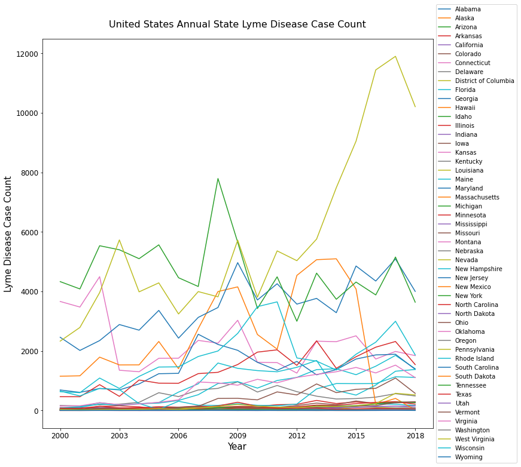

```python
import matplotlib.pyplot as plt
%matplotlib inline

# Figure
fig, ax1 = plt.subplots()
fig.set_size_inches(13, 10)

# Plot
LDcounts_state_transp.plot(ax=ax1)

# Labels
ax1.set_title('United States Annual State Lyme Disease Case Count',
              fontsize=16, y=1.02)
ax1.set_xlabel('Year',
              fontsize=15)
ax1.set_ylabel('Lyme Disease Case Count',
              fontsize=15)
ax1.set_xticks(np.arange(0,21, step=3))
ax1.set_xticklabels(list(range(2000,2021))[::3])

box = ax1.get_position()
ax1.set_position([box.x0, box.y0, box.width * 0.9, box.height* 1.2])

ax1.legend(loc='center left', bbox_to_anchor=(1, 0.5))

plt.show()
```

Below are the yearly total case counts of all the counties, and county equivalents for the years 2000-2018 with "unknowns" not included in those counts.

```python
LDcounts_state_transp["All"] = LDcounts_state_transp.sum(axis=1)
LDcounts_state_transp[["All"]] # column of yearly reported cases of Lyme disease totals
```

| Stname | All |
| --- | --- |
| Cases2000 | 17570 |
| Cases2001 | 16864 |
| Cases2002 | 23466 |
| Cases2003 | 21183 |
| Cases2004 | 19665 |
| Cases2005 | 23174 |
| Cases2006 | 19848 |
| Cases2007 | 26442 |
| Cases2008 | 32819 |
| Cases2009 | 36105 |
| Cases2010 | 27737 |
| Cases2011 | 31007 |
| Cases2012 | 28748 |
| Cases2013 | 35073 |
| Cases2014 | 33052 |
| Cases2015 | 37583 |
| Cases2016 | 36006 |
| Cases2017 | 42321 |
| Cases2018 | 33360 |

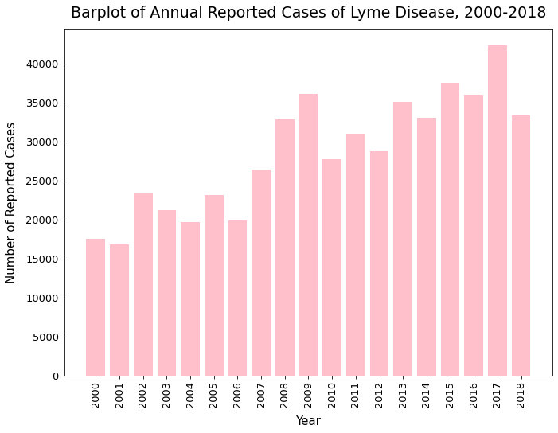

```python
#### Barplot of Annual Lyme Disease Cases ###
import matplotlib.pyplot as plt
%matplotlib inline

labels  = (str(e) for e in list(range(2000,2019)))
height = LDcounts_state_transp["All"].values

# Figure
fig, ax1 = plt.subplots()
fig.set_size_inches(11, 8)

# Plot
ax1.bar(x=LDcounts_state_transp.index, height=height,
        color=['pink'])

# Labels
ax1.set_title('Barplot of Annual Reported Cases of Lyme Disease, 2000-2018', fontsize=19, y=1.02)
ax1.set_xlabel('Year', fontsize=15, labelpad=10)
ax1.set_ylabel('Number of Reported Cases', fontsize=15, labelpad=10)
ax1.tick_params(axis='both', which='major', labelsize=13)
ax1.set_xticklabels(labels, rotation='vertical')

plt.show()
```

Lyme disease case counts including "unknowns":

```python
years = LDcounts_df.columns[4:]
LDcounts_state_uk_df = pd.DataFrame(columns=years)
for y in years:
    LDcounts_state_uk_df[y] = LDcounts_df.groupby('Stname')[y].sum()
LDcounts_state_uk_df
```

| Stname | Cases2000 | Cases2001 | Cases2002 | Cases2003 | Cases2004 | Cases2005 | Cases2006 | Cases2007 | Cases2008 | Cases2009 | Cases2010 | Cases2011 | Cases2012 | Cases2013 | Cases2014 | Cases2015 | Cases2016 | Cases2017 | Cases2018 |
| --- | --- | --- | --- | --- | --- | --- | --- | --- | --- | --- | --- | --- | --- | --- | --- | --- | --- | --- | --- |
| Alabama | 6 | 10 | 11 | 8 | 6 | 3 | 11 | 13 | 9 | 3 | 2 | 24 | 25 | 24 | 64 | 25 | 38 | 41 | 36 |
| Alaska | 2 | 2 | 3 | 3 | 3 | 4 | 3 | 10 | 6 | 7 | 7 | 11 | 10 | 14 | 8 | 9 | 15 | 10 | 11 |
| Arizona | 2 | 3 | 4 | 4 | 13 | 10 | 10 | 2 | 8 | 7 | 2 | 15 | 13 | 32 | 21 | 12 | 13 | 28 | 7 |
| Arkansas | 7 | 4 | 3 | 0 | 0 | 0 | 0 | 1 | 0 | 0 | 0 | 0 | 0 | 0 | 0 | 0 | 2 | 6 | 4 |
| California | 96 | 95 | 97 | 86 | 48 | 95 | 85 | 75 | 74 | 117 | 129 | 92 | 70 | 112 | 73 | 98 | 134 | 145 | 104 |
| Colorado | 0 | 0 | 1 | 0 | 0 | 0 | 0 | 0 | 3 | 1 | 3 | 0 | 0 | 0 | 0 | 0 | 0 | 4 | 3 |
| Connecticut | 3773 | 3597 | 4631 | 1403 | 1348 | 1810 | 1788 | 3058 | 3896 | 4156 | 3068 | 3039 | 2657 | 2925 | 2360 | 2541 | 1748 | 2051 | 1859 |
| Delaware | 167 | 152 | 194 | 212 | 339 | 646 | 482 | 715 | 772 | 984 | 656 | 873 | 669 | 509 | 417 | 435 | 506 | 608 | 520 |
| District of Columbia | 11 | 17 | 25 | 14 | 16 | 10 | 62 | 116 | 74 | 61 | 42 | 0 | 0 | 35 | 40 | 121 | 103 | 84 | 79 |
| Florida | 54 | 43 | 79 | 43 | 46 | 47 | 34 | 30 | 88 | 110 | 84 | 115 | 118 | 138 | 155 | 166 | 216 | 210 | 169 |
| Georgia | 0 | 0 | 2 | 10 | 12 | 6 | 8 | 11 | 35 | 40 | 10 | 32 | 31 | 8 | 4 | 8 | 4 | 8 | 19 |
| Hawaii | 0 | 0 | 0 | 0 | 0 | 0 | 0 | 0 | 0 | 0 | 0 | 0 | 0 | 0 | 0 | 0 | 0 | 0 | 0 |
| Idaho | 4 | 5 | 4 | 3 | 6 | 2 | 7 | 9 | 9 | 16 | 9 | 4 | 5 | 19 | 9 | 9 | 17 | 20 | 9 |
| Illinois | 35 | 32 | 47 | 71 | 87 | 127 | 110 | 149 | 108 | 136 | 135 | 194 | 204 | 337 | 233 | 287 | 237 | 273 | 276 |
| Indiana | 23 | 26 | 21 | 25 | 32 | 33 | 26 | 55 | 42 | 83 | 78 | 94 | 74 | 110 | 110 | 138 | 152 | 142 | 155 |
| Iowa | 34 | 36 | 42 | 58 | 49 | 89 | 97 | 123 | 109 | 108 | 85 | 100 | 165 | 247 | 194 | 318 | 232 | 255 | 283 |
| Kansas | 17 | 2 | 7 | 4 | 3 | 3 | 4 | 8 | 16 | 18 | 10 | 17 | 19 | 34 | 20 | 23 | 39 | 40 | 30 |
| Kentucky | 13 | 23 | 25 | 17 | 15 | 5 | 7 | 6 | 5 | 1 | 5 | 3 | 14 | 40 | 44 | 49 | 33 | 20 | 22 |
| Louisiana | 8 | 8 | 5 | 7 | 2 | 3 | 1 | 2 | 3 | 0 | 3 | 2 | 7 | 0 | 2 | 3 | 7 | 12 | 4 |
| Maine | 71 | 108 | 219 | 175 | 225 | 247 | 338 | 529 | 908 | 970 | 751 | 1006 | 1111 | 1373 | 1401 | 1201 | 1487 | 1850 | 1405 |
| Maryland | 688 | 608 | 738 | 691 | 891 | 1235 | 1248 | 2576 | 2218 | 2024 | 1617 | 1351 | 1651 | 1197 | 1373 | 1728 | 1866 | 1891 | 1382 |
| Massachusetts | 1158 | 1164 | 1807 | 1532 | 1532 | 2336 | 1432 | 2988 | 4582 | 5256 | 3263 | 2476 | 5138 | 5290 | 5304 | 4224 | 198 | 410 | 16 |
| Michigan | 23 | 21 | 26 | 12 | 27 | 62 | 55 | 51 | 92 | 103 | 95 | 104 | 98 | 168 | 127 | 148 | 221 | 291 | 262 |
| Minnesota | 465 | 461 | 867 | 474 | 1023 | 917 | 914 | 1238 | 1282 | 1543 | 1960 | 2124 | 1515 | 2340 | 1416 | 1805 | 2126 | 2318 | 1541 |
| Mississippi | 3 | 8 | 12 | 21 | 0 | 0 | 3 | 1 | 1 | 0 | 0 | 5 | 1 | 0 | 2 | 4 | 1 | 1 | 4 |
| Missouri | 47 | 37 | 41 | 70 | 25 | 15 | 5 | 10 | 6 | 3 | 4 | 8 | 2 | 3 | 10 | 5 | 10 | 12 | 11 |
| Montana | 0 | 0 | 0 | 0 | 0 | 0 | 1 | 4 | 17 | 3 | 4 | 11 | 6 | 18 | 7 | 5 | 17 | 12 | 7 |
| Nebraska | 5 | 4 | 6 | 2 | 2 | 2 | 11 | 7 | 12 | 5 | 8 | 11 | 15 | 10 | 7 | 11 | 14 | 14 | 15 |
| Nevada | 4 | 4 | 2 | 3 | 1 | 3 | 4 | 15 | 12 | 13 | 2 | 5 | 10 | 16 | 6 | 7 | 15 | 17 | 14 |
| New Hampshire | 84 | 129 | 261 | 190 | 226 | 265 | 617 | 896 | 1601 | 1415 | 1339 | 1299 | 1450 | 1687 | 724 | 529 | 891 | 1381 | 1428 |
| New Jersey | 2459 | 2020 | 2349 | 2887 | 2698 | 3363 | 2432 | 3134 | 3485 | 4973 | 3712 | 4262 | 3576 | 3766 | 3286 | 4855 | 4350 | 5092 | 4000 |
| New Mexico | 0 | 1 | 1 | 1 | 1 | 3 | 3 | 5 | 8 | 5 | 5 | 6 | 1 | 6 | 0 | 0 | 1 | 3 | 2 |
| New York | 4329 | 4083 | 5535 | 5399 | 5100 | 5565 | 4460 | 4165 | 7794 | 5651 | 3425 | 4490 | 2998 | 4615 | 3736 | 4314 | 3882 | 5155 | 3638 |
| North Carolina | 47 | 41 | 137 | 156 | 122 | 49 | 31 | 53 | 47 | 96 | 82 | 88 | 122 | 180 | 170 | 230 | 272 | 295 | 212 |
| North Dakota | 2 | 0 | 1 | 0 | 0 | 3 | 7 | 12 | 10 | 15 | 33 | 27 | 15 | 29 | 14 | 33 | 32 | 56 | 33 |
| Ohio | 61 | 44 | 82 | 66 | 50 | 58 | 43 | 33 | 45 | 58 | 44 | 53 | 67 | 93 | 119 | 154 | 160 | 270 | 293 |
| Oklahoma | 1 | 0 | 0 | 0 | 3 | 0 | 0 | 1 | 2 | 2 | 0 | 2 | 4 | 3 | 0 | 0 | 0 | 1 | 0 |
| Oregon | 13 | 15 | 12 | 16 | 11 | 3 | 7 | 6 | 38 | 38 | 39 | 38 | 48 | 43 | 45 | 31 | 61 | 84 | 70 |
| Pennsylvania | 2343 | 2806 | 3989 | 5730 | 3985 | 4287 | 3242 | 3994 | 3818 | 5722 | 3805 | 5362 | 5033 | 5758 | 7487 | 9048 | 11443 | 11900 | 10208 |
| Rhode Island | 675 | 510 | 852 | 736 | 249 | 39 | 308 | 177 | 210 | 235 | 181 | 159 | 217 | 724 | 904 | 904 | 903 | 1132 | 1111 |
| South Carolina | 25 | 6 | 26 | 18 | 22 | 15 | 20 | 31 | 29 | 42 | 29 | 37 | 44 | 42 | 37 | 42 | 51 | 21 | 39 |
| South Dakota | 0 | 0 | 2 | 1 | 1 | 2 | 1 | 0 | 3 | 1 | 1 | 4 | 4 | 4 | 2 | 5 | 11 | 12 | 7 |
| Tennessee | 28 | 31 | 28 | 20 | 20 | 8 | 15 | 31 | 31 | 37 | 36 | 37 | 30 | 25 | 17 | 26 | 25 | 47 | 29 |
| Texas | 77 | 75 | 139 | 85 | 98 | 69 | 29 | 87 | 153 | 276 | 142 | 74 | 75 | 82 | 40 | 54 | 71 | 58 | 47 |
| Utah | 3 | 1 | 5 | 2 | 1 | 2 | 5 | 7 | 5 | 9 | 3 | 9 | 5 | 15 | 13 | 7 | 19 | 25 | 27 |
| Vermont | 40 | 18 | 37 | 43 | 50 | 54 | 105 | 138 | 404 | 408 | 356 | 623 | 522 | 893 | 599 | 710 | 761 | 1092 | 576 |
| Virginia | 149 | 156 | 259 | 195 | 216 | 274 | 357 | 959 | 933 | 908 | 1245 | 1023 | 1110 | 1307 | 1346 | 1539 | 1350 | 1657 | 1139 |
| Washington | 9 | 9 | 11 | 7 | 14 | 13 | 8 | 12 | 23 | 16 | 16 | 19 | 15 | 18 | 15 | 24 | 31 | 37 | 20 |
| West Virginia | 35 | 16 | 26 | 31 | 38 | 61 | 28 | 84 | 135 | 201 | 145 | 118 | 97 | 143 | 136 | 289 | 368 | 648 | 671 |
| Wisconsin | 631 | 597 | 1090 | 740 | 1144 | 1459 | 1466 | 1814 | 2034 | 2589 | 3488 | 3649 | 1766 | 1872 | 1361 | 1894 | 2295 | 3000 | 1869 |
| Wyoming | 3 | 1 | 2 | 2 | 4 | 3 | 1 | 3 | 3 | 3 | 0 | 2 | 4 | 3 | 3 | 1 | 1 | 4 | 0 |

```python
LDcounts_state_uk_transp = LDcounts_state_uk_df.transpose()
LDcounts_state_uk_transp
```

| Stname | Alabama | Alaska | Arizona | Arkansas | California | Colorado | Connecticut | Delaware | District of Columbia | Florida | Georgia | Hawaii | Idaho | Illinois | Indiana | Iowa | Kansas | Kentucky | Louisiana | Maine | Maryland | Massachusetts | Michigan | Minnesota | Mississippi | Missouri | Montana | Nebraska | Nevada | … |
| --- | --- | --- | --- | --- | --- | --- | --- | --- | --- | --- | --- | --- | --- | --- | --- | --- | --- | --- | --- | --- | --- | --- | --- | --- | --- | --- | --- | --- | --- | --- |
| Cases2000 | 6 | 2 | 2 | 7 | 96 | 0 | 3773 | 167 | 11 | 54 | 0 | 0 | 4 | 35 | 23 | 34 | 17 | 13 | 8 | 71 | 688 | 1158 | 23 | 465 | 3 | 47 | 0 | 5 | 4 | … |
| Cases2001 | 10 | 2 | 3 | 4 | 95 | 0 | 3597 | 152 | 17 | 43 | 0 | 0 | 5 | 32 | 26 | 36 | 2 | 23 | 8 | 108 | 608 | 1164 | 21 | 461 | 8 | 37 | 0 | 4 | 4 | … |
| Cases2002 | 11 | 3 | 4 | 3 | 97 | 1 | 4631 | 194 | 25 | 79 | 2 | 0 | 4 | 47 | 21 | 42 | 7 | 25 | 5 | 219 | 738 | 1807 | 26 | 867 | 12 | 41 | 0 | 6 | 2 | … |
| Cases2003 | 8 | 3 | 4 | 0 | 86 | 0 | 1403 | 212 | 14 | 43 | 10 | 0 | 3 | 71 | 25 | 58 | 4 | 17 | 7 | 175 | 691 | 1532 | 12 | 474 | 21 | 70 | 0 | 2 | 3 | … |
| Cases2004 | 6 | 3 | 13 | 0 | 48 | 0 | 1348 | 339 | 16 | 46 | 12 | 0 | 6 | 87 | 32 | 49 | 3 | 15 | 2 | 225 | 891 | 1532 | 27 | 1023 | 0 | 25 | 0 | 2 | 1 | … |
| Cases2005 | 3 | 4 | 10 | 0 | 95 | 0 | 1810 | 646 | 10 | 47 | 6 | 0 | 2 | 127 | 33 | 89 | 3 | 5 | 3 | 247 | 1235 | 2336 | 62 | 917 | 0 | 15 | 0 | 2 | 3 | … |
| Cases2006 | 11 | 3 | 10 | 0 | 85 | 0 | 1788 | 482 | 62 | 34 | 8 | 0 | 7 | 110 | 26 | 97 | 4 | 7 | 1 | 338 | 1248 | 1432 | 55 | 914 | 3 | 5 | 1 | 11 | 4 | … |
| Cases2007 | 13 | 10 | 2 | 1 | 75 | 0 | 3058 | 715 | 116 | 30 | 11 | 0 | 9 | 149 | 55 | 123 | 8 | 6 | 2 | 529 | 2576 | 2988 | 51 | 1238 | 1 | 10 | 4 | 7 | 15 | … |
| Cases2008 | 9 | 6 | 8 | 0 | 74 | 3 | 3896 | 772 | 74 | 88 | 35 | 0 | 9 | 108 | 42 | 109 | 16 | 5 | 3 | 908 | 2218 | 4582 | 92 | 1282 | 1 | 6 | 17 | 12 | 12 | … |
| Cases2009 | 3 | 7 | 7 | 0 | 117 | 1 | 4156 | 984 | 61 | 110 | 40 | 0 | 16 | 136 | 83 | 108 | 18 | 1 | 0 | 970 | 2024 | 5256 | 103 | 1543 | 0 | 3 | 3 | 5 | 13 | … |
| Cases2010 | 2 | 7 | 2 | 0 | 129 | 3 | 3068 | 656 | 42 | 84 | 10 | 0 | 9 | 135 | 78 | 85 | 10 | 5 | 3 | 751 | 1617 | 3263 | 95 | 1960 | 0 | 4 | 4 | 8 | 2 | … |
| Cases2011 | 24 | 11 | 15 | 0 | 92 | 0 | 3039 | 873 | 0 | 115 | 32 | 0 | 4 | 194 | 94 | 100 | 17 | 3 | 2 | 1006 | 1351 | 2476 | 104 | 2124 | 5 | 8 | 11 | 11 | 5 | … |
| Cases2012 | 25 | 10 | 13 | 0 | 70 | 0 | 2657 | 669 | 0 | 118 | 31 | 0 | 5 | 204 | 74 | 165 | 19 | 14 | 7 | 1111 | 1651 | 5138 | 98 | 1515 | 1 | 2 | 6 | 15 | 10 | … |
| Cases2013 | 24 | 14 | 32 | 0 | 112 | 0 | 2925 | 509 | 35 | 138 | 8 | 0 | 19 | 337 | 110 | 247 | 34 | 40 | 0 | 1373 | 1197 | 5290 | 168 | 2340 | 0 | 3 | 18 | 10 | 16 | … |
| Cases2014 | 64 | 8 | 21 | 0 | 73 | 0 | 2360 | 417 | 40 | 155 | 4 | 0 | 9 | 233 | 110 | 194 | 20 | 44 | 2 | 1401 | 1373 | 5304 | 127 | 1416 | 2 | 10 | 7 | 7 | 6 | … |
| Cases2015 | 25 | 9 | 12 | 0 | 98 | 0 | 2541 | 435 | 121 | 166 | 8 | 0 | 9 | 287 | 138 | 318 | 23 | 49 | 3 | 1201 | 1728 | 4224 | 148 | 1805 | 4 | 5 | 5 | 11 | 7 | … |
| Cases2016 | 38 | 15 | 13 | 2 | 134 | 0 | 1748 | 506 | 103 | 216 | 4 | 0 | 17 | 237 | 152 | 232 | 39 | 33 | 7 | 1487 | 1866 | 198 | 221 | 2126 | 1 | 10 | 17 | 14 | 15 | … |
| Cases2017 | 41 | 10 | 28 | 6 | 145 | 4 | 2051 | 608 | 84 | 210 | 8 | 0 | 20 | 273 | 142 | 255 | 40 | 20 | 12 | 1850 | 1891 | 410 | 291 | 2318 | 1 | 12 | 12 | 14 | 17 | … |
| Cases2018 | 36 | 11 | 7 | 4 | 104 | 3 | 1859 | 520 | 79 | 169 | 19 | 0 | 9 | 276 | 155 | 283 | 30 | 22 | 4 | 1405 | 1382 | 16 | 262 | 1541 | 4 | 11 | 7 | 15 | 14 | … |

Below are the annual total case counts of all the states, counties, and county equivalents for the years 2000-2018 with "unknowns" included in those counts.

```python
LDcounts_state_uk_transp["All"] = LDcounts_state_uk_transp.sum(axis=1)
LDcounts_state_uk_transp[["All"]] # column of yearly reported cases of Lyme disease totals
```

| Stname | All |
| --- | --- |
| Cases2000 | 17730 |
| Cases2001 | 17029 |
| Cases2002 | 23763 |
| Cases2003 | 21273 |
| Cases2004 | 19804 |
| Cases2005 | 23305 |
| Cases2006 | 19931 |
| Cases2007 | 27444 |
| Cases2008 | 35198 |
| Cases2009 | 38468 |
| Cases2010 | 30158 |
| Cases2011 | 33097 |
| Cases2012 | 30831 |
| Cases2013 | 36307 |
| Cases2014 | 33461 |
| Cases2015 | 38069 |
| Cases2016 | 36429 |
| Cases2017 | 42743 |
| Cases2018 | 33666 |

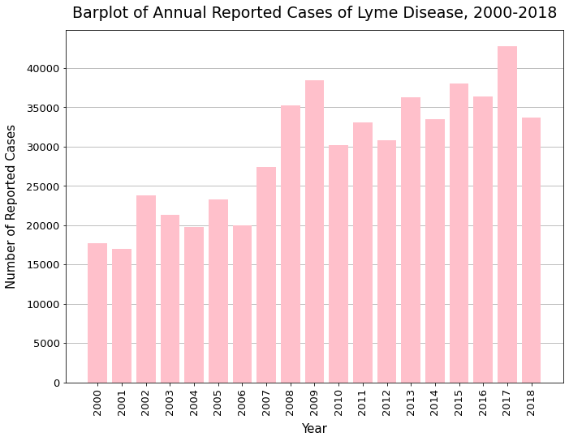

```python
#### Barplot of Annual Lyme Disease Cases ###
import matplotlib.pyplot as plt
%matplotlib inline

labels  = (str(e) for e in list(range(2000,2019)))
height = LDcounts_state_uk_transp["All"].values

# Figure
fig, ax1 = plt.subplots()
fig.set_size_inches(11, 8)

# Plot
ax1.bar(x=LDcounts_state_uk_transp.index, height=height,
        color=['pink'])

# Labels
ax1.set_title('Barplot of Annual Reported Cases of Lyme Disease, 2000-2018', fontsize=19, y=1.02)
ax1.set_xlabel('Year', fontsize=15, labelpad=10)
ax1.set_ylabel('Number of Reported Cases', fontsize=15, labelpad=10)
ax1.tick_params(axis='both', which='major', labelsize=13)
ax1.set_xticklabels(labels, rotation='vertical')

# Grid lines
ax1.set_axisbelow(True)
plt.grid(b=True, which='major', axis='y')

plt.show()
```

```python
LDcounts_state_uk_transp['All'].mean(axis=0)
```

```
29405.57894736842
```

There are on average approximately 29,406 reported cases of Lyme disease each year in the United States.

## 2.2 Feature Data

### 2.2.1 Population Data

The population data was retrieved from the Census Bureau. [23][24] Two Census datasets for annual population total were downloaded. The first one was for the population from 2000-2010 by county or county equivalent. The second one was for the population from 2010-2018 by county or county equivalent.

Population data was used as a feature and for the population density feature. Population was a chosen feature because a county or county equivalent cannot have more reported cases of Lyme disease than the number of people living in the county or county equivalent. An increase in population might increase case counts, but an increase in population might also increase population density. Population density was used to help represent the amount of backyard space each person might have had because ticks can be found in backyards.

Population data for 2000-2010:

```python
pop00_df = pd.read_csv("co-est00int-tot.csv",
                        encoding='latin-1')
```

This is what the top part of the population data for 2000-2010 retrieved from the Census Bureau looked like:

```python
pop00_df.head()
```

|  | SUMLEV | REGION | DIVISION | STATE | COUNTY | STNAME | CTYNAME | ESTIMATESBASE2000 | POPESTIMATE2000 | POPESTIMATE2001 | POPESTIMATE2002 | POPESTIMATE2003 | POPESTIMATE2004 | POPESTIMATE2005 | POPESTIMATE2006 | POPESTIMATE2007 | POPESTIMATE2008 | POPESTIMATE2009 | CENSUS2010POP | POPESTIMATE2010 |
| --- | --- | --- | --- | --- | --- | --- | --- | --- | --- | --- | --- | --- | --- | --- | --- | --- | --- | --- | --- | --- |
| 0 | 40 | 3 | 6 | 1 | 0 | Alabama | Alabama | 4447207 | 4452173 | 4467634 | 4480089 | 4503491 | 4530729 | 4569805 | 4628981 | 4672840 | 4718206 | 4757938 | 4779736 | 4785298 |
| 1 | 50 | 3 | 6 | 1 | 1 | Alabama | Autauga County | 43751 | 44021 | 44889 | 45909 | 46800 | 48366 | 49676 | 51328 | 52405 | 53277 | 54135 | 54571 | 54632 |
| 2 | 50 | 3 | 6 | 1 | 3 | Alabama | Baldwin County | 140416 | 141342 | 144875 | 147957 | 151509 | 156266 | 162183 | 168121 | 172404 | 175827 | 179406 | 182265 | 183195 |
| 3 | 50 | 3 | 6 | 1 | 5 | Alabama | Barbour County | 29042 | 29015 | 28863 | 28653 | 28594 | 28287 | 28027 | 27861 | 27757 | 27808 | 27657 | 27457 | 27411 |
| 4 | 50 | 3 | 6 | 1 | 7 | Alabama | Bibb County | 19856 | 19913 | 21028 | 21199 | 21399 | 21721 | 22042 | 22099 | 22438 | 22705 | 22941 | 22915 | 22867 |

There were twenty columns in the dataset. The first column gave the SUMLEV. SUMLEV is a Census Bureau geographic summary level code. According to the United States Census Bureau, states have a sumlev code of 40 while counties within a state have a sumlev code of 50. The second column gave the region (four census regions in total). The third column gave the division (nine census divisions in total). [25] The fourth column gave the state FIPS code. The fifth column gave the county or county equivalent FIPS code. Populations where the county code was '0' represented state totals. The sixth column gave the state. The seventh column gave the name of the county or county equivalent. If the population represented state totals, then the name of the state would be used as the value in the county name column. The eighth through twentieth columns gave the annual population estimates (and census for 2010) for the years 2000-2010.

`pop00_df.info()` showed that there was no missing (null) data and that there were 3,194 entries.

```python
pop00_df.info()
```

```
<class 'pandas.core.frame.DataFrame'>
RangeIndex: 3194 entries, 0 to 3193
Data columns (total 20 columns):
 #   Column             Non-Null Count  Dtype
---  ------             --------------  -----
 0   SUMLEV             3194 non-null   int64
 1   REGION             3194 non-null   int64
 2   DIVISION           3194 non-null   int64
 3   STATE              3194 non-null   int64
 4   COUNTY             3194 non-null   int64
 5   STNAME             3194 non-null   object
 6   CTYNAME            3194 non-null   object
 7   ESTIMATESBASE2000  3194 non-null   int64
 8   POPESTIMATE2000    3194 non-null   int64
 9   POPESTIMATE2001    3194 non-null   int64
 10  POPESTIMATE2002    3194 non-null   int64
 11  POPESTIMATE2003    3194 non-null   int64
 12  POPESTIMATE2004    3194 non-null   int64
 13  POPESTIMATE2005    3194 non-null   int64
 14  POPESTIMATE2006    3194 non-null   int64
 15  POPESTIMATE2007    3194 non-null   int64
 16  POPESTIMATE2008    3194 non-null   int64
 17  POPESTIMATE2009    3194 non-null   int64
 18  CENSUS2010POP      3194 non-null   int64
 19  POPESTIMATE2010    3194 non-null   int64
dtypes: int64(18), object(2)
memory usage: 499.2+ KB
```

Population data for 2010-2018:

```python
pop18_df = pd.read_csv("co-est2018-alldata.csv",
                        encoding='latin-1')
```

```python
pop18_df.iloc[:,:18].info()
```

```
<class 'pandas.core.frame.DataFrame'>
RangeIndex: 3193 entries, 0 to 3192
Data columns (total 18 columns):
 #   Column             Non-Null Count  Dtype
---  ------             --------------  -----
 0   SUMLEV             3193 non-null   int64
 1   REGION             3193 non-null   int64
 2   DIVISION           3193 non-null   int64
 3   STATE              3193 non-null   int64
 4   COUNTY             3193 non-null   int64
 5   STNAME             3193 non-null   object
 6   CTYNAME            3193 non-null   object
 7   CENSUS2010POP      3193 non-null   int64
 8   ESTIMATESBASE2010  3193 non-null   int64
 9   POPESTIMATE2010    3193 non-null   int64
 10  POPESTIMATE2011    3193 non-null   int64
 11  POPESTIMATE2012    3193 non-null   int64
 12  POPESTIMATE2013    3193 non-null   int64
 13  POPESTIMATE2014    3193 non-null   int64
 14  POPESTIMATE2015    3193 non-null   int64
 15  POPESTIMATE2016    3193 non-null   int64
 16  POPESTIMATE2017    3193 non-null   int64
 17  POPESTIMATE2018    3193 non-null   int64
dtypes: int64(16), object(2)
memory usage: 449.1+ KB
```

There were no missing (null) data. There were 3,193 rows. 50 of them were the state totals (50 states in United States). There would be 3,143 counties or county equivalents when state totals are taken out.

```python
pop18_df.head()
```

|  | SUMLEV | REGION | DIVISION | STATE | COUNTY | STNAME | CTYNAME | CENSUS2010POP | ESTIMATESBASE2010 | POPESTIMATE2010 | POPESTIMATE2011 | POPESTIMATE2012 | POPESTIMATE2013 | POPESTIMATE2014 | POPESTIMATE2015 | POPESTIMATE2016 | POPESTIMATE2017 | POPESTIMATE2018 | NPOPCHG_2010 | NPOPCHG_2011 | NPOPCHG_2012 | NPOPCHG_2013 | NPOPCHG_2014 | NPOPCHG_2015 | NPOPCHG_2016 | NPOPCHG_2017 | NPOPCHG_2018 | BIRTHS2010 | BIRTHS2011 | … |
| --- | --- | --- | --- | --- | --- | --- | --- | --- | --- | --- | --- | --- | --- | --- | --- | --- | --- | --- | --- | --- | --- | --- | --- | --- | --- | --- | --- | --- | --- | --- |
| 0 | 40 | 3 | 6 | 1 | 0 | Alabama | Alabama | 4779736 | 4780138 | 4785448 | 4798834 | 4815564 | 4830460 | 4842481 | 4853160 | 4864745 | 4875120 | 4887871 | 5310 | 13386 | 16730 | 14896 | 12021 | 10679 | 11585 | 10375 | 12751 | 14227 | 59689 | … |
| 1 | 50 | 3 | 6 | 1 | 1 | Alabama | Autauga County | 54571 | 54574 | 54754 | 55208 | 54936 | 54713 | 54876 | 54838 | 55242 | 55443 | 55601 | 180 | 454 | -272 | -223 | 163 | -38 | 404 | 201 | 158 | 151 | 636 | … |
| 2 | 50 | 3 | 6 | 1 | 3 | Alabama | Baldwin County | 182265 | 182264 | 183111 | 186540 | 190143 | 194886 | 199189 | 202995 | 207712 | 212619 | 218022 | 847 | 3429 | 3603 | 4743 | 4303 | 3806 | 4717 | 4907 | 5403 | 516 | 2188 | … |
| 3 | 50 | 3 | 6 | 1 | 5 | Alabama | Barbour County | 27457 | 27457 | 27330 | 27350 | 27174 | 26944 | 26758 | 26294 | 25819 | 25158 | 24881 | -127 | 20 | -176 | -230 | -186 | -464 | -475 | -661 | -277 | 70 | 334 | … |
| 4 | 50 | 3 | 6 | 1 | 7 | Alabama | Bibb County | 22915 | 22920 | 22872 | 22747 | 22664 | 22516 | 22541 | 22562 | 22576 | 22555 | 22400 | -48 | -125 | -83 | -148 | 25 | 21 | 14 | -21 | -155 | 44 | 266 | … |

5 rows × 148 columns

I removed all unneccesary columns. I kept the 2010 Census since it looked the same in both datasets unlike the 2010 population estimates. I dropped the base estimates.

```python
pop00_df = pop00_df.iloc[:,:20].drop(['ESTIMATESBASE2000', 'POPESTIMATE2010'], axis=1)
pop00_df.head()
```

|  | SUMLEV | REGION | DIVISION | STATE | COUNTY | STNAME | CTYNAME | POPESTIMATE2000 | POPESTIMATE2001 | POPESTIMATE2002 | POPESTIMATE2003 | POPESTIMATE2004 | POPESTIMATE2005 | POPESTIMATE2006 | POPESTIMATE2007 | POPESTIMATE2008 | POPESTIMATE2009 | CENSUS2010POP |
| --- | --- | --- | --- | --- | --- | --- | --- | --- | --- | --- | --- | --- | --- | --- | --- | --- | --- | --- |
| 0 | 40 | 3 | 6 | 1 | 0 | Alabama | Alabama | 4452173 | 4467634 | 4480089 | 4503491 | 4530729 | 4569805 | 4628981 | 4672840 | 4718206 | 4757938 | 4779736 |
| 1 | 50 | 3 | 6 | 1 | 1 | Alabama | Autauga County | 44021 | 44889 | 45909 | 46800 | 48366 | 49676 | 51328 | 52405 | 53277 | 54135 | 54571 |
| 2 | 50 | 3 | 6 | 1 | 3 | Alabama | Baldwin County | 141342 | 144875 | 147957 | 151509 | 156266 | 162183 | 168121 | 172404 | 175827 | 179406 | 182265 |
| 3 | 50 | 3 | 6 | 1 | 5 | Alabama | Barbour County | 29015 | 28863 | 28653 | 28594 | 28287 | 28027 | 27861 | 27757 | 27808 | 27657 | 27457 |
| 4 | 50 | 3 | 6 | 1 | 7 | Alabama | Bibb County | 19913 | 21028 | 21199 | 21399 | 21721 | 22042 | 22099 | 22438 | 22705 | 22941 | 22915 |

```python
pop18_df = pop18_df.iloc[:,:18].drop(['ESTIMATESBASE2010', 'POPESTIMATE2010'], axis=1)
pop18_df.head()
```

|  | SUMLEV | REGION | DIVISION | STATE | COUNTY | STNAME | CTYNAME | CENSUS2010POP | POPESTIMATE2011 | POPESTIMATE2012 | POPESTIMATE2013 | POPESTIMATE2014 | POPESTIMATE2015 | POPESTIMATE2016 | POPESTIMATE2017 | POPESTIMATE2018 |
| --- | --- | --- | --- | --- | --- | --- | --- | --- | --- | --- | --- | --- | --- | --- | --- | --- |
| 0 | 40 | 3 | 6 | 1 | 0 | Alabama | Alabama | 4779736 | 4798834 | 4815564 | 4830460 | 4842481 | 4853160 | 4864745 | 4875120 | 4887871 |
| 1 | 50 | 3 | 6 | 1 | 1 | Alabama | Autauga County | 54571 | 55208 | 54936 | 54713 | 54876 | 54838 | 55242 | 55443 | 55601 |
| 2 | 50 | 3 | 6 | 1 | 3 | Alabama | Baldwin County | 182265 | 186540 | 190143 | 194886 | 199189 | 202995 | 207712 | 212619 | 218022 |
| 3 | 50 | 3 | 6 | 1 | 5 | Alabama | Barbour County | 27457 | 27350 | 27174 | 26944 | 26758 | 26294 | 25819 | 25158 | 24881 |
| 4 | 50 | 3 | 6 | 1 | 7 | Alabama | Bibb County | 22915 | 22747 | 22664 | 22516 | 22541 | 22562 | 22576 | 22555 | 22400 |

I combined the two datasets into one so that I would have 2000-2018 population estimates in one dataset. I also made the values the same data type (integer).

```python
pop00_df.iloc[:, :5] = pop00_df.iloc[:, :5].apply(pd.to_numeric, downcast='integer')
pop18_df.iloc[:, :5] = pop18_df.iloc[:, :5].apply(pd.to_numeric, downcast='integer')
pop00_df.iloc[:, 7:] = pop00_df.iloc[:, 7:].apply(pd.to_numeric, downcast='integer')
pop18_df.iloc[:, 7:] = pop18_df.iloc[:, 7:].apply(pd.to_numeric, downcast='integer')
```

```python
pop0018_df = pd.merge(pop00_df, pop18_df,
                         on=['SUMLEV','REGION','DIVISION','STATE','COUNTY',
                          'STNAME','CTYNAME', 'CENSUS2010POP'],
                         how='outer')
pop0018_df.head()
```

|  | SUMLEV | REGION | DIVISION | STATE | COUNTY | STNAME | CTYNAME | POPESTIMATE2000 | POPESTIMATE2001 | POPESTIMATE2002 | POPESTIMATE2003 | POPESTIMATE2004 | POPESTIMATE2005 | POPESTIMATE2006 | POPESTIMATE2007 | POPESTIMATE2008 | POPESTIMATE2009 | CENSUS2010POP | POPESTIMATE2011 | POPESTIMATE2012 | POPESTIMATE2013 | POPESTIMATE2014 | POPESTIMATE2015 | POPESTIMATE2016 | POPESTIMATE2017 | POPESTIMATE2018 |
| --- | --- | --- | --- | --- | --- | --- | --- | --- | --- | --- | --- | --- | --- | --- | --- | --- | --- | --- | --- | --- | --- | --- | --- | --- | --- | --- |
| 0 | 40 | 3 | 6 | 1 | 0 | Alabama | Alabama | 4452173.0 | 4467634.0 | 4480089.0 | 4503491.0 | 4530729.0 | 4569805.0 | 4628981.0 | 4672840.0 | 4718206.0 | 4757938.0 | 4779736 | 4798834.0 | 4815564.0 | 4830460.0 | 4842481.0 | 4853160.0 | 4864745.0 | 4875120.0 | 4887871.0 |
| 1 | 50 | 3 | 6 | 1 | 1 | Alabama | Autauga County | 44021.0 | 44889.0 | 45909.0 | 46800.0 | 48366.0 | 49676.0 | 51328.0 | 52405.0 | 53277.0 | 54135.0 | 54571 | 55208.0 | 54936.0 | 54713.0 | 54876.0 | 54838.0 | 55242.0 | 55443.0 | 55601.0 |
| 2 | 50 | 3 | 6 | 1 | 3 | Alabama | Baldwin County | 141342.0 | 144875.0 | 147957.0 | 151509.0 | 156266.0 | 162183.0 | 168121.0 | 172404.0 | 175827.0 | 179406.0 | 182265 | 186540.0 | 190143.0 | 194886.0 | 199189.0 | 202995.0 | 207712.0 | 212619.0 | 218022.0 |
| 3 | 50 | 3 | 6 | 1 | 5 | Alabama | Barbour County | 29015.0 | 28863.0 | 28653.0 | 28594.0 | 28287.0 | 28027.0 | 27861.0 | 27757.0 | 27808.0 | 27657.0 | 27457 | 27350.0 | 27174.0 | 26944.0 | 26758.0 | 26294.0 | 25819.0 | 25158.0 | 24881.0 |
| 4 | 50 | 3 | 6 | 1 | 7 | Alabama | Bibb County | 19913.0 | 21028.0 | 21199.0 | 21399.0 | 21721.0 | 22042.0 | 22099.0 | 22438.0 | 22705.0 | 22941.0 | 22915 | 22747.0 | 22664.0 | 22516.0 | 22541.0 | 22562.0 | 22576.0 | 22555.0 | 22400.0 |

```python
pop0018_df.info()
```

```
<class 'pandas.core.frame.DataFrame'>
Int64Index: 3198 entries, 0 to 3197
Data columns (total 26 columns):
 #   Column           Non-Null Count  Dtype
---  ------           --------------  -----
 0   SUMLEV           3198 non-null   int64
 1   REGION           3198 non-null   int64
 2   DIVISION         3198 non-null   int64
 3   STATE            3198 non-null   int64
 4   COUNTY           3198 non-null   int64
 5   STNAME           3198 non-null   object
 6   CTYNAME          3198 non-null   object
 7   POPESTIMATE2000  3194 non-null   float64
 8   POPESTIMATE2001  3194 non-null   float64
 9   POPESTIMATE2002  3194 non-null   float64
```

[output cut: 18 more lines]

```python
pop0018_df[pop0018_df.isnull().any(axis=1)]
```

|  | SUMLEV | REGION | DIVISION | STATE | COUNTY | STNAME | CTYNAME | POPESTIMATE2000 | POPESTIMATE2001 | POPESTIMATE2002 | POPESTIMATE2003 | POPESTIMATE2004 | POPESTIMATE2005 | POPESTIMATE2006 | POPESTIMATE2007 | POPESTIMATE2008 | POPESTIMATE2009 | CENSUS2010POP | POPESTIMATE2011 | POPESTIMATE2012 | POPESTIMATE2013 | POPESTIMATE2014 | POPESTIMATE2015 | POPESTIMATE2016 | POPESTIMATE2017 | POPESTIMATE2018 |
| --- | --- | --- | --- | --- | --- | --- | --- | --- | --- | --- | --- | --- | --- | --- | --- | --- | --- | --- | --- | --- | --- | --- | --- | --- | --- | --- |
| 88 | 50 | 4 | 9 | 2 | 195 | Alaska | Petersburg Census Area | 4249.0 | 4198.0 | 4112.0 | 4022.0 | 4059.0 | 3959.0 | 3886.0 | 3898.0 | 3817.0 | 3775.0 | 3815 | NaN | NaN | NaN | NaN | NaN | NaN | NaN | NaN |
| 94 | 50 | 4 | 9 | 2 | 270 | Alaska | Wade Hampton Census Area | 7033.0 | 7051.0 | 7103.0 | 7201.0 | 7330.0 | 7313.0 | 7292.0 | 7372.0 | 7392.0 | 7469.0 | 7459 | NaN | NaN | NaN | NaN | NaN | NaN | NaN | NaN |
| 1161 | 50 | 3 | 7 | 22 | 59 | Louisiana | La Salle Parish | 14271.0 | 14207.0 | 14359.0 | 14356.0 | 14366.0 | 14313.0 | 14519.0 | 14570.0 | 14667.0 | 14717.0 | 14890 | NaN | NaN | NaN | NaN | NaN | NaN | NaN | NaN |
| 2459 | 50 | 2 | 4 | 46 | 113 | South Dakota | Shannon County | 12542.0 | 12602.0 | 12872.0 | 12993.0 | 12983.0 | 13150.0 | 13404.0 | 13345.0 | 13368.0 | 13425.0 | 13586 | NaN | NaN | NaN | NaN | NaN | NaN | NaN | NaN |
| 2963 | 50 | 3 | 5 | 51 | 515 | Virginia | Bedford city | 6425.0 | 6400.0 | 6320.0 | 6237.0 | 6198.0 | 6186.0 | 6147.0 | 6169.0 | 6150.0 | 6174.0 | 6222 | NaN | NaN | NaN | NaN | NaN | NaN | NaN | NaN |
| 3194 | 50 | 4 | 9 | 2 | 158 | Alaska | Kusilvak Census Area | NaN | NaN | NaN | NaN | NaN | NaN | NaN | NaN | NaN | NaN | 7459 | 7648.0 | 7791.0 | 7972.0 | 8098.0 | 8187.0 | 8174.0 | 8230.0 | 8303.0 |
| 3195 | 50 | 4 | 9 | 2 | 195 | Alaska | Petersburg Borough | NaN | NaN | NaN | NaN | NaN | NaN | NaN | NaN | NaN | NaN | 3815 | 3254.0 | 3278.0 | 3293.0 | 3265.0 | 3259.0 | 3270.0 | 3259.0 | 3221.0 |
| 3196 | 50 | 3 | 7 | 22 | 59 | Louisiana | LaSalle Parish | NaN | NaN | NaN | NaN | NaN | NaN | NaN | NaN | NaN | NaN | 14890 | 14939.0 | 14861.0 | 14822.0 | 14876.0 | 14985.0 | 15036.0 | 14929.0 | 14917.0 |
| 3197 | 50 | 2 | 4 | 46 | 102 | South Dakota | Oglala Lakota County | NaN | NaN | NaN | NaN | NaN | NaN | NaN | NaN | NaN | NaN | 13586 | 13897.0 | 14038.0 | 14127.0 | 14213.0 | 14360.0 | 14430.0 | 14364.0 | 14309.0 |

- I fixed the name of La Salle to LaSalle (22-059). The name of LaSalle Parish, Louisiana was corrected from La Salle Parish (name correction reported in 2011). [26]
- Oglala Lakota County, South Dakota (46-102) was formerly known as Shannon County, South Dakota (46-113) (effective May 1, 2015). [26] I fixed name and code.
- Kusilvak Census Area, Alaska (02-158) was formerly known as Wade Hampton Census Area, Alaska (02-270) (effective July 1, 2015). [26] I fixed name and code.
- Prince of Wales-Hyder Census Area, Alaska (02-198) added part of the former Petersburg Census Area (02-195) effective January 3, 2013. [26]
- Part of Hoonah-Angoon Census Area, Alaska (02-105) was taken to create new Petersburg Borough (02-195) effective January 3, 2013. [26]
- Petersburg Borough, Alaska (02-195) created from part of Petersburg Census Area, Alaska (02-195) and part of Hoonah-Angoon Census Area, Alaska (02-105) (effective January 3, 2013). [26] I took out Petersburg Borough, Alaska (02-195), Petersburg Census Area, Alaska (02-195), and Hoonah-Angoon Census Area, Alaska (02-105) since data would not be as accurate for it since inconstistanet labeling for population, counts, temperatures, location, and land area, and already have enough low counts data and their data is all low counts.
- Bedford City, Virginia (51-515) is a town and former independent city located within Bedford County, Virginia (51-019) (rejoined county in 2013 that's why NA for population dataset after the 2010 census). (Changed to town status and added to Bedford County (51-019) effective July 1, 2013.) [26]

I called the counties with changed names by their current name and moved former name's data to the current names data row. I took out the rest of the missing data if county didn't exist then or didn't have data for it.

```python
pop0018_clean_df = pop0018_df.copy()
```

```python
# Fixing LaSalle Parish, Louisiana data
LaSal_popVal = pop0018_clean_df.loc[pop0018_clean_df['CTYNAME']=='La Salle Parish',
                                    'POPESTIMATE2000':'CENSUS2010POP'].values
pop0018_clean_df.loc[pop0018_clean_df['CTYNAME']=='LaSalle Parish',
                     'POPESTIMATE2000':'CENSUS2010POP'] = LaSal_popVal

pop0018_clean_df.loc[pop0018_clean_df['CTYNAME']=='LaSalle Parish']
```

|  | SUMLEV | REGION | DIVISION | STATE | COUNTY | STNAME | CTYNAME | POPESTIMATE2000 | POPESTIMATE2001 | POPESTIMATE2002 | POPESTIMATE2003 | POPESTIMATE2004 | POPESTIMATE2005 | POPESTIMATE2006 | POPESTIMATE2007 | POPESTIMATE2008 | POPESTIMATE2009 | CENSUS2010POP | POPESTIMATE2011 | POPESTIMATE2012 | POPESTIMATE2013 | POPESTIMATE2014 | POPESTIMATE2015 | POPESTIMATE2016 | POPESTIMATE2017 | POPESTIMATE2018 |
| --- | --- | --- | --- | --- | --- | --- | --- | --- | --- | --- | --- | --- | --- | --- | --- | --- | --- | --- | --- | --- | --- | --- | --- | --- | --- | --- |
| 3196 | 50 | 3 | 7 | 22 | 59 | Louisiana | LaSalle Parish | 14271.0 | 14207.0 | 14359.0 | 14356.0 | 14366.0 | 14313.0 | 14519.0 | 14570.0 | 14667.0 | 14717.0 | 14890.0 | 14939.0 | 14861.0 | 14822.0 | 14876.0 | 14985.0 | 15036.0 | 14929.0 | 14917.0 |

```python
#checking what STCODE=22 and CTYCODE=59 county name is in Lyme disease dataset
LDcounts_cty_df.loc[(LDcounts_cty_df['CTYCODE']==59) &
                    (LDcounts_cty_df['STCODE']==22)]
```

|  | Ctyname | Stname | STCODE | CTYCODE | Cases2000 | Cases2001 | Cases2002 | Cases2003 | Cases2004 | Cases2005 | Cases2006 | Cases2007 | Cases2008 | Cases2009 | Cases2010 | Cases2011 | Cases2012 | Cases2013 | Cases2014 | Cases2015 | Cases2016 | Cases2017 | Cases2018 |
| --- | --- | --- | --- | --- | --- | --- | --- | --- | --- | --- | --- | --- | --- | --- | --- | --- | --- | --- | --- | --- | --- | --- | --- |
| 1142 | LaSalle Parish | Louisiana | 22 | 59 | 0 | 0 | 0 | 0 | 0 | 0 | 0 | 0 | 0 | 0 | 0 | 0 | 0 | 0 | 0 | 0 | 0 | 0 | 0 |

I did not need to change the Lyme disease counts dataset's name for LaSalle Parish, Louisiana since it already had the correct name for LaSalle Parish, Louisiana.

```python
pop0018_clean_df.drop(
    pop0018_clean_df[pop0018_clean_df.CTYNAME == 'La Salle Parish'].index,
    inplace=True)
pop0018_clean_df.reset_index(drop=True, inplace=True)

print(len(pop0018_clean_df))
```

```
3197
```

The length of the dataset is 3,197, meaning there is 3,197 rows, 1 less than 3,198 which was the number of rows before droppping the repeat county, La Salle Parish, which is what expected.

```python
ShanSD_popVal = pop0018_clean_df.loc[(pop0018_clean_df['CTYNAME']=='Shannon County') &
                                     (pop0018_clean_df['STNAME']=='South Dakota'),
                                     'POPESTIMATE2000':'CENSUS2010POP'].values
pop0018_clean_df.loc[(pop0018_clean_df['CTYNAME']=='Oglala Lakota County') &
                     (pop0018_clean_df['STNAME']=='South Dakota'),
                     'POPESTIMATE2000':'CENSUS2010POP'] = ShanSD_popVal

pop0018_clean_df.drop(
    pop0018_clean_df[(pop0018_clean_df.CTYNAME == 'Shannon County') &
                     (pop0018_clean_df.STNAME == 'South Dakota')].index,
                      inplace=True)
pop0018_clean_df.reset_index(drop=True, inplace=True)

pop0018_clean_df.loc[pop0018_clean_df['CTYNAME']=='Oglala Lakota County']
```

|  | SUMLEV | REGION | DIVISION | STATE | COUNTY | STNAME | CTYNAME | POPESTIMATE2000 | POPESTIMATE2001 | POPESTIMATE2002 | POPESTIMATE2003 | POPESTIMATE2004 | POPESTIMATE2005 | POPESTIMATE2006 | POPESTIMATE2007 | POPESTIMATE2008 | POPESTIMATE2009 | CENSUS2010POP | POPESTIMATE2011 | POPESTIMATE2012 | POPESTIMATE2013 | POPESTIMATE2014 | POPESTIMATE2015 | POPESTIMATE2016 | POPESTIMATE2017 | POPESTIMATE2018 |
| --- | --- | --- | --- | --- | --- | --- | --- | --- | --- | --- | --- | --- | --- | --- | --- | --- | --- | --- | --- | --- | --- | --- | --- | --- | --- | --- |
| 3195 | 50 | 2 | 4 | 46 | 102 | South Dakota | Oglala Lakota County | 12542.0 | 12602.0 | 12872.0 | 12993.0 | 12983.0 | 13150.0 | 13404.0 | 13345.0 | 13368.0 | 13425.0 | 13586.0 | 13897.0 | 14038.0 | 14127.0 | 14213.0 | 14360.0 | 14430.0 | 14364.0 | 14309.0 |

```python
WadHam_popVal = pop0018_clean_df.loc[(pop0018_clean_df['CTYNAME']=='Wade Hampton Census Area') &
                     (pop0018_clean_df['STNAME']=='Alaska'),
                     'POPESTIMATE2000':'CENSUS2010POP'].values

pop0018_clean_df.loc[(pop0018_clean_df['CTYNAME']=='Kusilvak Census Area') &
                     (pop0018_clean_df['STNAME']=='Alaska'),
                     'POPESTIMATE2000':'CENSUS2010POP'] = WadHam_popVal

pop0018_clean_df.drop(
    pop0018_clean_df[(pop0018_clean_df.CTYNAME == 'Wade Hampton Census Area') &
                     (pop0018_clean_df.STNAME == 'Alaska')].index, inplace=True)
pop0018_clean_df.reset_index(drop=True, inplace=True)

pop0018_clean_df.loc[pop0018_clean_df['CTYNAME']=='Kusilvak Census Area']
```

|  | SUMLEV | REGION | DIVISION | STATE | COUNTY | STNAME | CTYNAME | POPESTIMATE2000 | POPESTIMATE2001 | POPESTIMATE2002 | POPESTIMATE2003 | POPESTIMATE2004 | POPESTIMATE2005 | POPESTIMATE2006 | POPESTIMATE2007 | POPESTIMATE2008 | POPESTIMATE2009 | CENSUS2010POP | POPESTIMATE2011 | POPESTIMATE2012 | POPESTIMATE2013 | POPESTIMATE2014 | POPESTIMATE2015 | POPESTIMATE2016 | POPESTIMATE2017 | POPESTIMATE2018 |
| --- | --- | --- | --- | --- | --- | --- | --- | --- | --- | --- | --- | --- | --- | --- | --- | --- | --- | --- | --- | --- | --- | --- | --- | --- | --- | --- |
| 3191 | 50 | 4 | 9 | 2 | 158 | Alaska | Kusilvak Census Area | 7033.0 | 7051.0 | 7103.0 | 7201.0 | 7330.0 | 7313.0 | 7292.0 | 7372.0 | 7392.0 | 7469.0 | 7459.0 | 7648.0 | 7791.0 | 7972.0 | 8098.0 | 8187.0 | 8174.0 | 8230.0 | 8303.0 |

```python
pop0018_clean_df[pop0018_clean_df.isnull().any(axis=1)]
```

|  | SUMLEV | REGION | DIVISION | STATE | COUNTY | STNAME | CTYNAME | POPESTIMATE2000 | POPESTIMATE2001 | POPESTIMATE2002 | POPESTIMATE2003 | POPESTIMATE2004 | POPESTIMATE2005 | POPESTIMATE2006 | POPESTIMATE2007 | POPESTIMATE2008 | POPESTIMATE2009 | CENSUS2010POP | POPESTIMATE2011 | POPESTIMATE2012 | POPESTIMATE2013 | POPESTIMATE2014 | POPESTIMATE2015 | POPESTIMATE2016 | POPESTIMATE2017 | POPESTIMATE2018 |
| --- | --- | --- | --- | --- | --- | --- | --- | --- | --- | --- | --- | --- | --- | --- | --- | --- | --- | --- | --- | --- | --- | --- | --- | --- | --- | --- |
| 88 | 50 | 4 | 9 | 2 | 195 | Alaska | Petersburg Census Area | 4249.0 | 4198.0 | 4112.0 | 4022.0 | 4059.0 | 3959.0 | 3886.0 | 3898.0 | 3817.0 | 3775.0 | 3815.0 | NaN | NaN | NaN | NaN | NaN | NaN | NaN | NaN |
| 2960 | 50 | 3 | 5 | 51 | 515 | Virginia | Bedford city | 6425.0 | 6400.0 | 6320.0 | 6237.0 | 6198.0 | 6186.0 | 6147.0 | 6169.0 | 6150.0 | 6174.0 | 6222.0 | NaN | NaN | NaN | NaN | NaN | NaN | NaN | NaN |
| 3192 | 50 | 4 | 9 | 2 | 195 | Alaska | Petersburg Borough | NaN | NaN | NaN | NaN | NaN | NaN | NaN | NaN | NaN | NaN | 3815.0 | 3254.0 | 3278.0 | 3293.0 | 3265.0 | 3259.0 | 3270.0 | 3259.0 | 3221.0 |

I looked at what the counties with null data in population dataset looked like in Lyme disease dataset plus Bedford County, Virginia to compare to Bedford City, Virginia.

```python
LDcounts_cty_df.loc[((LDcounts_cty_df['CTYCODE']==195) & # Petersburg Borough
                    (LDcounts_cty_df['STCODE']==2)) |
                    ((LDcounts_cty_df['CTYCODE']==270) & #Wade Hampton Census Area
                    (LDcounts_cty_df['STCODE']==2)) |
                    ((LDcounts_cty_df['CTYCODE']==113) & #Shannon County
                    (LDcounts_cty_df['STCODE']==46)) |
                    ((LDcounts_cty_df['CTYCODE']==515) & #Bedford city
                    (LDcounts_cty_df['STCODE']==51)) |
                    ((LDcounts_cty_df['CTYCODE']==158) & #Kusilvak Census Area
                    (LDcounts_cty_df['STCODE']==2)) |
                    ((LDcounts_cty_df['CTYCODE']==102) & #Oglala Lakota County
                    (LDcounts_cty_df['STCODE']==46)) |
                    ((LDcounts_cty_df['CTYCODE']==19) & #Bedford County
                    (LDcounts_cty_df['STCODE']==51))]
```

|  | Ctyname | Stname | STCODE | CTYCODE | Cases2000 | Cases2001 | Cases2002 | Cases2003 | Cases2004 | Cases2005 | Cases2006 | Cases2007 | Cases2008 | Cases2009 | Cases2010 | Cases2011 | Cases2012 | Cases2013 | Cases2014 | Cases2015 | Cases2016 | Cases2017 | Cases2018 |
| --- | --- | --- | --- | --- | --- | --- | --- | --- | --- | --- | --- | --- | --- | --- | --- | --- | --- | --- | --- | --- | --- | --- | --- |
| 81 | Kusilvak Census Area | Alaska | 2 | 158 | 0 | 0 | 0 | 0 | 0 | 0 | 0 | 0 | 0 | 0 | 0 | 0 | 0 | 0 | 0 | 0 | 0 | 0 | 0 |
| 87 | Petersburg Borough | Alaska | 2 | 195 | 0 | 0 | 0 | 0 | 0 | 0 | 0 | 0 | 0 | 0 | 0 | 0 | 0 | 0 | 0 | 0 | 0 | 0 | 0 |
| 2412 | Oglala Lakota County | South Dakota | 46 | 102 | 0 | 0 | 0 | 0 | 0 | 0 | 0 | 0 | 0 | 0 | 0 | 0 | 0 | 0 | 0 | 0 | 1 | 0 | 0 |
| 2829 | Bedford County | Virginia | 51 | 19 | 3 | 0 | 0 | 0 | 0 | 1 | 2 | 3 | 2 | 0 | 5 | 11 | 19 | 10 | 5 | 10 | 14 | 6 | 5 |
| 2916 | Bedford city | Virginia | 51 | 515 | 0 | 0 | 0 | 0 | 0 | 0 | 0 | 0 | 0 | 0 | 0 | 0 | 0 | 1 | 0 | 0 | 0 | 0 | 0 |

Bedford City in Virginia did have data for every year 2000-2018 in the Lyme disease case count dataset. Since Bedford City rejoined Bedford County, Virginia after 2010 and the population data for Bedford City in Virginia goes up to 2010, I added the case counts for Bedford City, Virginia to the case counts of Bedford County, Virginia. The population data for Bedford County, Virginia looked like the population of Bedford City was added to it starting in 2011. Thus, I put Bedford City into Bedford County for all years and data.

```python
pop0018_clean_df.loc[((pop0018_clean_df['CTYNAME']=='Bedford County') |
                      (pop0018_clean_df['CTYNAME']=='Bedford city')) &
                     (pop0018_clean_df['STNAME']=='Virginia')]
```

|  | SUMLEV | REGION | DIVISION | STATE | COUNTY | STNAME | CTYNAME | POPESTIMATE2000 | POPESTIMATE2001 | POPESTIMATE2002 | POPESTIMATE2003 | POPESTIMATE2004 | POPESTIMATE2005 | POPESTIMATE2006 | POPESTIMATE2007 | POPESTIMATE2008 | POPESTIMATE2009 | CENSUS2010POP | POPESTIMATE2011 | POPESTIMATE2012 | POPESTIMATE2013 | POPESTIMATE2014 | POPESTIMATE2015 | POPESTIMATE2016 | POPESTIMATE2017 | POPESTIMATE2018 |
| --- | --- | --- | --- | --- | --- | --- | --- | --- | --- | --- | --- | --- | --- | --- | --- | --- | --- | --- | --- | --- | --- | --- | --- | --- | --- | --- |
| 2873 | 50 | 3 | 5 | 51 | 19 | Virginia | Bedford County | 60472.0 | 60985.0 | 61580.0 | 62441.0 | 63563.0 | 64825.0 | 66363.0 | 67392.0 | 67594.0 | 68399.0 | 68676.0 | 75557.0 | 75759.0 | 76187.0 | 77046.0 | 77598.0 | 77911.0 | 78239.0 | 78747.0 |
| 2960 | 50 | 3 | 5 | 51 | 515 | Virginia | Bedford city | 6425.0 | 6400.0 | 6320.0 | 6237.0 | 6198.0 | 6186.0 | 6147.0 | 6169.0 | 6150.0 | 6174.0 | 6222.0 | NaN | NaN | NaN | NaN | NaN | NaN | NaN | NaN |

Adding Bedford City population to Bedford County population for years 2000 to 2010.

```python
BedfVA_popVal = pop0018_clean_df.loc[(pop0018_clean_df['CTYNAME'] == 'Bedford city') &
                                     (pop0018_clean_df['STNAME'] == 'Virginia'),
                                     'POPESTIMATE2000':'CENSUS2010POP'].values

pop0018_clean_df.loc[(pop0018_clean_df['CTYNAME'] == 'Bedford County') &
                     (pop0018_clean_df['STNAME'] == 'Virginia'),
                     'POPESTIMATE2000':'CENSUS2010POP'] += BedfVA_popVal

pop0018_clean_df.loc[(pop0018_clean_df['CTYNAME'] == 'Bedford County') &
                     (pop0018_clean_df['STNAME'] == 'Virginia')]
```

|  | SUMLEV | REGION | DIVISION | STATE | COUNTY | STNAME | CTYNAME | POPESTIMATE2000 | POPESTIMATE2001 | POPESTIMATE2002 | POPESTIMATE2003 | POPESTIMATE2004 | POPESTIMATE2005 | POPESTIMATE2006 | POPESTIMATE2007 | POPESTIMATE2008 | POPESTIMATE2009 | CENSUS2010POP | POPESTIMATE2011 | POPESTIMATE2012 | POPESTIMATE2013 | POPESTIMATE2014 | POPESTIMATE2015 | POPESTIMATE2016 | POPESTIMATE2017 | POPESTIMATE2018 |
| --- | --- | --- | --- | --- | --- | --- | --- | --- | --- | --- | --- | --- | --- | --- | --- | --- | --- | --- | --- | --- | --- | --- | --- | --- | --- | --- |
| 2873 | 50 | 3 | 5 | 51 | 19 | Virginia | Bedford County | 66897.0 | 67385.0 | 67900.0 | 68678.0 | 69761.0 | 71011.0 | 72510.0 | 73561.0 | 73744.0 | 74573.0 | 74898.0 | 75557.0 | 75759.0 | 76187.0 | 77046.0 | 77598.0 | 77911.0 | 78239.0 | 78747.0 |

```python
pop0018_clean_df[pop0018_clean_df.isnull().any(axis=1)]
```

|  | SUMLEV | REGION | DIVISION | STATE | COUNTY | STNAME | CTYNAME | POPESTIMATE2000 | POPESTIMATE2001 | POPESTIMATE2002 | POPESTIMATE2003 | POPESTIMATE2004 | POPESTIMATE2005 | POPESTIMATE2006 | POPESTIMATE2007 | POPESTIMATE2008 | POPESTIMATE2009 | CENSUS2010POP | POPESTIMATE2011 | POPESTIMATE2012 | POPESTIMATE2013 | POPESTIMATE2014 | POPESTIMATE2015 | POPESTIMATE2016 | POPESTIMATE2017 | POPESTIMATE2018 |
| --- | --- | --- | --- | --- | --- | --- | --- | --- | --- | --- | --- | --- | --- | --- | --- | --- | --- | --- | --- | --- | --- | --- | --- | --- | --- | --- |
| 88 | 50 | 4 | 9 | 2 | 195 | Alaska | Petersburg Census Area | 4249.0 | 4198.0 | 4112.0 | 4022.0 | 4059.0 | 3959.0 | 3886.0 | 3898.0 | 3817.0 | 3775.0 | 3815.0 | NaN | NaN | NaN | NaN | NaN | NaN | NaN | NaN |
| 2960 | 50 | 3 | 5 | 51 | 515 | Virginia | Bedford city | 6425.0 | 6400.0 | 6320.0 | 6237.0 | 6198.0 | 6186.0 | 6147.0 | 6169.0 | 6150.0 | 6174.0 | 6222.0 | NaN | NaN | NaN | NaN | NaN | NaN | NaN | NaN |
| 3192 | 50 | 4 | 9 | 2 | 195 | Alaska | Petersburg Borough | NaN | NaN | NaN | NaN | NaN | NaN | NaN | NaN | NaN | NaN | 3815.0 | 3254.0 | 3278.0 | 3293.0 | 3265.0 | 3259.0 | 3270.0 | 3259.0 | 3221.0 |

```python
pop0018_clean_df.dropna(inplace=True)
pop0018_clean_df.reset_index(drop=True, inplace=True)
```

```python
pop0018_clean_df.info()
```

```
<class 'pandas.core.frame.DataFrame'>
RangeIndex: 3192 entries, 0 to 3191
Data columns (total 26 columns):
 #   Column           Non-Null Count  Dtype
---  ------           --------------  -----
 0   SUMLEV           3192 non-null   int64
 1   REGION           3192 non-null   int64
 2   DIVISION         3192 non-null   int64
 3   STATE            3192 non-null   int64
 4   COUNTY           3192 non-null   int64
 5   STNAME           3192 non-null   object
 6   CTYNAME          3192 non-null   object
 7   POPESTIMATE2000  3192 non-null   float64
 8   POPESTIMATE2001  3192 non-null   float64
 9   POPESTIMATE2002  3192 non-null   float64
```

[output cut: 18 more lines]

There were 3,192 rows in the dataset after the removal of those two counties. The next cleaning of the data was to remove the state totals from the population dataset. SUMLEV is a Census Bureau summary level code. According to the United States Census Bureau, states have a sumlev code of 40 while counties within a state have a sumlev code of 50. Since the District of Columbia might be considered its own state under the summary level codes, the District of Columbia's representation in the dataset was checked.

```python
pop0018_clean_df.loc[pop0018_clean_df['CTYNAME'] == 'District of Columbia']
```

|  | SUMLEV | REGION | DIVISION | STATE | COUNTY | STNAME | CTYNAME | POPESTIMATE2000 | POPESTIMATE2001 | POPESTIMATE2002 | POPESTIMATE2003 | POPESTIMATE2004 | POPESTIMATE2005 | POPESTIMATE2006 | POPESTIMATE2007 | POPESTIMATE2008 | POPESTIMATE2009 | CENSUS2010POP | POPESTIMATE2011 | POPESTIMATE2012 | POPESTIMATE2013 | POPESTIMATE2014 | POPESTIMATE2015 | POPESTIMATE2016 | POPESTIMATE2017 | POPESTIMATE2018 |
| --- | --- | --- | --- | --- | --- | --- | --- | --- | --- | --- | --- | --- | --- | --- | --- | --- | --- | --- | --- | --- | --- | --- | --- | --- | --- | --- |
| 325 | 40 | 3 | 5 | 11 | 0 | District of Columbia | District of Columbia | 572046.0 | 574504.0 | 573158.0 | 568502.0 | 567754.0 | 567136.0 | 570681.0 | 574404.0 | 580236.0 | 592228.0 | 601723.0 | 619602.0 | 634725.0 | 650431.0 | 662513.0 | 675254.0 | 686575.0 | 695691.0 | 702455.0 |
| 326 | 50 | 3 | 5 | 11 | 1 | District of Columbia | District of Columbia | 572046.0 | 574504.0 | 573158.0 | 568502.0 | 567754.0 | 567136.0 | 570681.0 | 574404.0 | 580236.0 | 592228.0 | 601723.0 | 619602.0 | 634725.0 | 650431.0 | 662513.0 | 675254.0 | 686575.0 | 695691.0 | 702455.0 |

Since the population data for District of Columbia was the same in both rows, it was in a sense a duplicate so only one of those rows was kept. The focus is case count by county, so the row with the sumlev of 50 was kept and the row with the sumlev of 40 was removed. The following code created a new population dataset for only data from counties.

```python
pop0018_cty_df = pop0018_clean_df.loc[pop0018_clean_df['SUMLEV'] == 50].reset_index(drop=True)
pop0018_cty_df.info()
```

```
<class 'pandas.core.frame.DataFrame'>
RangeIndex: 3141 entries, 0 to 3140
Data columns (total 26 columns):
 #   Column           Non-Null Count  Dtype
---  ------           --------------  -----
 0   SUMLEV           3141 non-null   int64
 1   REGION           3141 non-null   int64
 2   DIVISION         3141 non-null   int64
 3   STATE            3141 non-null   int64
 4   COUNTY           3141 non-null   int64
 5   STNAME           3141 non-null   object
 6   CTYNAME          3141 non-null   object
 7   POPESTIMATE2000  3141 non-null   float64
 8   POPESTIMATE2001  3141 non-null   float64
 9   POPESTIMATE2002  3141 non-null   float64
```

[output cut: 18 more lines]

There are indeed 3141 rows as expected (3194-2-51=3141).

```python
pop0018_cty_df.head()
```

|  | SUMLEV | REGION | DIVISION | STATE | COUNTY | STNAME | CTYNAME | POPESTIMATE2000 | POPESTIMATE2001 | POPESTIMATE2002 | POPESTIMATE2003 | POPESTIMATE2004 | POPESTIMATE2005 | POPESTIMATE2006 | POPESTIMATE2007 | POPESTIMATE2008 | POPESTIMATE2009 | CENSUS2010POP | POPESTIMATE2011 | POPESTIMATE2012 | POPESTIMATE2013 | POPESTIMATE2014 | POPESTIMATE2015 | POPESTIMATE2016 | POPESTIMATE2017 | POPESTIMATE2018 |
| --- | --- | --- | --- | --- | --- | --- | --- | --- | --- | --- | --- | --- | --- | --- | --- | --- | --- | --- | --- | --- | --- | --- | --- | --- | --- | --- |
| 0 | 50 | 3 | 6 | 1 | 1 | Alabama | Autauga County | 44021.0 | 44889.0 | 45909.0 | 46800.0 | 48366.0 | 49676.0 | 51328.0 | 52405.0 | 53277.0 | 54135.0 | 54571.0 | 55208.0 | 54936.0 | 54713.0 | 54876.0 | 54838.0 | 55242.0 | 55443.0 | 55601.0 |
| 1 | 50 | 3 | 6 | 1 | 3 | Alabama | Baldwin County | 141342.0 | 144875.0 | 147957.0 | 151509.0 | 156266.0 | 162183.0 | 168121.0 | 172404.0 | 175827.0 | 179406.0 | 182265.0 | 186540.0 | 190143.0 | 194886.0 | 199189.0 | 202995.0 | 207712.0 | 212619.0 | 218022.0 |
| 2 | 50 | 3 | 6 | 1 | 5 | Alabama | Barbour County | 29015.0 | 28863.0 | 28653.0 | 28594.0 | 28287.0 | 28027.0 | 27861.0 | 27757.0 | 27808.0 | 27657.0 | 27457.0 | 27350.0 | 27174.0 | 26944.0 | 26758.0 | 26294.0 | 25819.0 | 25158.0 | 24881.0 |
| 3 | 50 | 3 | 6 | 1 | 7 | Alabama | Bibb County | 19913.0 | 21028.0 | 21199.0 | 21399.0 | 21721.0 | 22042.0 | 22099.0 | 22438.0 | 22705.0 | 22941.0 | 22915.0 | 22747.0 | 22664.0 | 22516.0 | 22541.0 | 22562.0 | 22576.0 | 22555.0 | 22400.0 |
| 4 | 50 | 3 | 6 | 1 | 9 | Alabama | Blount County | 51107.0 | 51845.0 | 52551.0 | 53457.0 | 54124.0 | 54624.0 | 55485.0 | 56240.0 | 57055.0 | 57341.0 | 57322.0 | 57554.0 | 57570.0 | 57611.0 | 57521.0 | 57522.0 | 57517.0 | 57827.0 | 57840.0 |

```python
LDcounts_cty_df.info()
```

```
<class 'pandas.core.frame.DataFrame'>
RangeIndex: 3143 entries, 0 to 3142
Data columns (total 23 columns):
 #   Column     Non-Null Count  Dtype
---  ------     --------------  -----
 0   Ctyname    3143 non-null   object
 1   Stname     3143 non-null   object
 2   STCODE     3143 non-null   int64
 3   CTYCODE    3143 non-null   int64
 4   Cases2000  3143 non-null   int64
 5   Cases2001  3143 non-null   int64
 6   Cases2002  3143 non-null   int64
 7   Cases2003  3143 non-null   int64
 8   Cases2004  3143 non-null   int64
 9   Cases2005  3143 non-null   int64
 10  Cases2006  3143 non-null   int64
 11  Cases2007  3143 non-null   int64
 12  Cases2008  3143 non-null   int64
 13  Cases2009  3143 non-null   int64
 14  Cases2010  3143 non-null   int64
 15  Cases2011  3143 non-null   int64
 16  Cases2012  3143 non-null   int64
 17  Cases2013  3143 non-null   int64
 18  Cases2014  3143 non-null   int64
 19  Cases2015  3143 non-null   int64
 20  Cases2016  3143 non-null   int64
 21  Cases2017  3143 non-null   int64
 22  Cases2018  3143 non-null   int64
dtypes: int64(21), object(2)
memory usage: 564.9+ KB
```

```python
print(len(LDcounts_cty_df))
LDcounts_cty_df.head()
```

```
3143
```

|  | Ctyname | Stname | STCODE | CTYCODE | Cases2000 | Cases2001 | Cases2002 | Cases2003 | Cases2004 | Cases2005 | Cases2006 | Cases2007 | Cases2008 | Cases2009 | Cases2010 | Cases2011 | Cases2012 | Cases2013 | Cases2014 | Cases2015 | Cases2016 | Cases2017 | Cases2018 |
| --- | --- | --- | --- | --- | --- | --- | --- | --- | --- | --- | --- | --- | --- | --- | --- | --- | --- | --- | --- | --- | --- | --- | --- |
| 0 | Autauga County | Alabama | 1 | 1 | 0 | 0 | 0 | 0 | 0 | 0 | 0 | 0 | 0 | 0 | 0 | 0 | 0 | 0 | 0 | 0 | 2 | 0 | 0 |
| 1 | Baldwin County | Alabama | 1 | 3 | 1 | 0 | 1 | 0 | 0 | 0 | 0 | 0 | 0 | 1 | 0 | 1 | 1 | 0 | 3 | 1 | 2 | 2 | 0 |
| 2 | Barbour County | Alabama | 1 | 5 | 0 | 0 | 0 | 0 | 0 | 0 | 0 | 0 | 0 | 0 | 0 | 1 | 0 | 0 | 0 | 0 | 0 | 0 | 0 |
| 3 | Bibb County | Alabama | 1 | 7 | 0 | 0 | 0 | 0 | 0 | 0 | 0 | 0 | 0 | 0 | 0 | 0 | 0 | 0 | 1 | 0 | 0 | 0 | 1 |
| 4 | Blount County | Alabama | 1 | 9 | 0 | 0 | 0 | 0 | 0 | 0 | 0 | 0 | 0 | 0 | 0 | 1 | 0 | 0 | 0 | 0 | 0 | 0 | 2 |

Transposed dataset would have 3143*19=59717 rows.

3143 counties and 19 years so 59,717 total rows in new Lyme disease dataset.

```python
colnames = {'Cases2000':2000,'Cases2001':2001,'Cases2002':2002,'Cases2003':2003,
            'Cases2004':2004,'Cases2005':2005,'Cases2006':2006,'Cases2007':2007,
            'Cases2008':2008,'Cases2009':2009,'Cases2010':2010,'Cases2011':2011,
            'Cases2012':2012,'Cases2013':2013,'Cases2014':2014,'Cases2015':2015,
            'Cases2016':2016,'Cases2017':2017,'Cases2018':2018}


caseYears = [2000,2001,2002,2003,2004,2005,2006,2007,2008,2009,2010,2011,2012,
             2013,2014,2015,2016,2017,2018]

LDcases_df = pd.melt(LDcounts_cty_df.rename(columns=colnames),
                     id_vars=['Ctyname','Stname','STCODE','CTYCODE'],
                     value_vars=caseYears, var_name='Year',
                     value_name='CaseCount')
LDcases_df
```

|  | Ctyname | Stname | STCODE | CTYCODE | Year | CaseCount |
| --- | --- | --- | --- | --- | --- | --- |
| 0 | Autauga County | Alabama | 1 | 1 | 2000 | 0 |
| 1 | Baldwin County | Alabama | 1 | 3 | 2000 | 1 |
| 2 | Barbour County | Alabama | 1 | 5 | 2000 | 0 |
| 3 | Bibb County | Alabama | 1 | 7 | 2000 | 0 |
| 4 | Blount County | Alabama | 1 | 9 | 2000 | 0 |
| ... | ... | ... | ... | ... | ... | ... |
| 59712 | Sweetwater County | Wyoming | 56 | 37 | 2018 | 0 |
| 59713 | Teton County | Wyoming | 56 | 39 | 2018 | 0 |
| 59714 | Uinta County | Wyoming | 56 | 41 | 2018 | 0 |
| 59715 | Washakie County | Wyoming | 56 | 43 | 2018 | 0 |
| 59716 | Weston County | Wyoming | 56 | 45 | 2018 | 0 |

59717 rows × 6 columns

District of Columbia CTYCODE is 1 in Lyme Disease dataset, whereas, 0 in pop dataset so change pop dataset CTYCODE value for District of Columbia to 1 to match Lyme Disease dataset.

3141*19=59679

3141 counties and 19 years so 59,679 total rows in new population dataset

```python
i = pop0018_cty_df.loc[pop0018_cty_df['CTYNAME']=='District of Columbia'].index [0]
pop0018_cty_df.loc[i,'COUNTY'] = 1

colnames={'CTYNAME':'Ctyname','STNAME':'Stname','STATE':'STCODE',
          'COUNTY':'CTYCODE','POPESTIMATE2000':2000,'POPESTIMATE2001':2001,
          'POPESTIMATE2002':2002,'POPESTIMATE2003':2003,'POPESTIMATE2004':2004,
          'POPESTIMATE2005':2005,'POPESTIMATE2006':2006,'POPESTIMATE2007':2007,
          'POPESTIMATE2008':2008,'POPESTIMATE2009':2009,'CENSUS2010POP':2010,
          'POPESTIMATE2011':2011,'POPESTIMATE2012':2012,'POPESTIMATE2013':2013,
          'POPESTIMATE2014':2014,'POPESTIMATE2015':2015,'POPESTIMATE2016':2016,
          'POPESTIMATE2017':2017,'POPESTIMATE2018':2018}

pop_df = pd.melt(pop0018_cty_df.rename(columns=colnames),
        id_vars=['Ctyname','Stname','STCODE','CTYCODE'], value_vars=caseYears,
        var_name='Year', value_name='Population')
pop_df
```

|  | Ctyname | Stname | STCODE | CTYCODE | Year | Population |
| --- | --- | --- | --- | --- | --- | --- |
| 0 | Autauga County | Alabama | 1 | 1 | 2000 | 44021.0 |
| 1 | Baldwin County | Alabama | 1 | 3 | 2000 | 141342.0 |
| 2 | Barbour County | Alabama | 1 | 5 | 2000 | 29015.0 |
| 3 | Bibb County | Alabama | 1 | 7 | 2000 | 19913.0 |
| 4 | Blount County | Alabama | 1 | 9 | 2000 | 51107.0 |
| ... | ... | ... | ... | ... | ... | ... |
| 59674 | Washakie County | Wyoming | 56 | 43 | 2018 | 7885.0 |
| 59675 | Weston County | Wyoming | 56 | 45 | 2018 | 6967.0 |
| 59676 | Kusilvak Census Area | Alaska | 2 | 158 | 2018 | 8303.0 |
| 59677 | LaSalle Parish | Louisiana | 22 | 59 | 2018 | 14917.0 |
| 59678 | Oglala Lakota County | South Dakota | 46 | 102 | 2018 | 14309.0 |

59679 rows × 6 columns

```python
LD_merged1_df = pd.merge(LDcases_df, pop_df,
                 on=['Ctyname','Stname','STCODE','CTYCODE','Year'], how='outer')
LD_merged1_df['Year'] = LD_merged1_df['Year'].astype(int)
print(len(LD_merged1_df))
LD_merged1_df.head()
```

```
59717
```

|  | Ctyname | Stname | STCODE | CTYCODE | Year | CaseCount | Population |
| --- | --- | --- | --- | --- | --- | --- | --- |
| 0 | Autauga County | Alabama | 1 | 1 | 2000 | 0 | 44021.0 |
| 1 | Baldwin County | Alabama | 1 | 3 | 2000 | 1 | 141342.0 |
| 2 | Barbour County | Alabama | 1 | 5 | 2000 | 0 | 29015.0 |
| 3 | Bibb County | Alabama | 1 | 7 | 2000 | 0 | 19913.0 |
| 4 | Blount County | Alabama | 1 | 9 | 2000 | 0 | 51107.0 |

```python
LD_merged1_df.info()
```

```
<class 'pandas.core.frame.DataFrame'>
Int64Index: 59717 entries, 0 to 59716
Data columns (total 7 columns):
 #   Column      Non-Null Count  Dtype
---  ------      --------------  -----
 0   Ctyname     59717 non-null  object
 1   Stname      59717 non-null  object
 2   STCODE      59717 non-null  int64
 3   CTYCODE     59717 non-null  int64
 4   Year        59717 non-null  int64
 5   CaseCount   59717 non-null  int64
 6   Population  59679 non-null  float64
dtypes: float64(1), int64(4), object(2)
memory usage: 3.6+ MB
```

```python
LD_merged1_df[LD_merged1_df.isnull().any(axis=1)]
```

|  | Ctyname | Stname | STCODE | CTYCODE | Year | CaseCount | Population |
| --- | --- | --- | --- | --- | --- | --- | --- |
| 87 | Petersburg Borough | Alaska | 2 | 195 | 2000 | 0 | NaN |
| 2916 | Bedford city | Virginia | 51 | 515 | 2000 | 0 | NaN |
| 3230 | Petersburg Borough | Alaska | 2 | 195 | 2001 | 0 | NaN |
| 6059 | Bedford city | Virginia | 51 | 515 | 2001 | 0 | NaN |
| 6373 | Petersburg Borough | Alaska | 2 | 195 | 2002 | 0 | NaN |
| 9202 | Bedford city | Virginia | 51 | 515 | 2002 | 0 | NaN |
| 9516 | Petersburg Borough | Alaska | 2 | 195 | 2003 | 0 | NaN |
| 12345 | Bedford city | Virginia | 51 | 515 | 2003 | 0 | NaN |
| 12659 | Petersburg Borough | Alaska | 2 | 195 | 2004 | 0 | NaN |
| 15488 | Bedford city | Virginia | 51 | 515 | 2004 | 0 | NaN |
| 15802 | Petersburg Borough | Alaska | 2 | 195 | 2005 | 0 | NaN |
| 18631 | Bedford city | Virginia | 51 | 515 | 2005 | 0 | NaN |
| 18945 | Petersburg Borough | Alaska | 2 | 195 | 2006 | 0 | NaN |
| 21774 | Bedford city | Virginia | 51 | 515 | 2006 | 0 | NaN |
| 22088 | Petersburg Borough | Alaska | 2 | 195 | 2007 | 0 | NaN |
| 24917 | Bedford city | Virginia | 51 | 515 | 2007 | 0 | NaN |
| 25231 | Petersburg Borough | Alaska | 2 | 195 | 2008 | 0 | NaN |
| 28060 | Bedford city | Virginia | 51 | 515 | 2008 | 0 | NaN |
| 28374 | Petersburg Borough | Alaska | 2 | 195 | 2009 | 0 | NaN |
| 31203 | Bedford city | Virginia | 51 | 515 | 2009 | 0 | NaN |
| 31517 | Petersburg Borough | Alaska | 2 | 195 | 2010 | 0 | NaN |
| 34346 | Bedford city | Virginia | 51 | 515 | 2010 | 0 | NaN |
| 34660 | Petersburg Borough | Alaska | 2 | 195 | 2011 | 0 | NaN |
| 37489 | Bedford city | Virginia | 51 | 515 | 2011 | 0 | NaN |
| 37803 | Petersburg Borough | Alaska | 2 | 195 | 2012 | 0 | NaN |
| 40632 | Bedford city | Virginia | 51 | 515 | 2012 | 0 | NaN |
| 40946 | Petersburg Borough | Alaska | 2 | 195 | 2013 | 0 | NaN |
| 43775 | Bedford city | Virginia | 51 | 515 | 2013 | 1 | NaN |
| 44089 | Petersburg Borough | Alaska | 2 | 195 | 2014 | 0 | NaN |
| 46918 | Bedford city | Virginia | 51 | 515 | 2014 | 0 | NaN |
| 47232 | Petersburg Borough | Alaska | 2 | 195 | 2015 | 0 | NaN |
| 50061 | Bedford city | Virginia | 51 | 515 | 2015 | 0 | NaN |
| 50375 | Petersburg Borough | Alaska | 2 | 195 | 2016 | 0 | NaN |
| 53204 | Bedford city | Virginia | 51 | 515 | 2016 | 0 | NaN |
| 53518 | Petersburg Borough | Alaska | 2 | 195 | 2017 | 0 | NaN |
| 56347 | Bedford city | Virginia | 51 | 515 | 2017 | 0 | NaN |
| 56661 | Petersburg Borough | Alaska | 2 | 195 | 2018 | 0 | NaN |
| 59490 | Bedford city | Virginia | 51 | 515 | 2018 | 0 | NaN |

```python
LD_clean1_df = LD_merged1_df.copy()
```

Then I added all years case counts of Bedford City to Bedford County case counts. Since only 1 count to be added, only had to do that 1 instead of add all since rest is zeros. Bedford County case count in 2013 was 10, so after adding the 1 case count in Bedford City, the Bedford County case count in 2013 changed to 11.

```python
BedfVA_caseVal = LD_clean1_df.loc[(LD_clean1_df['Ctyname'] == 'Bedford city') &
                                  (LD_clean1_df['Stname'] == 'Virginia') &
                                  (LD_clean1_df['Year'] == 2013), 'CaseCount'].values

LD_clean1_df.loc[(LD_clean1_df['Ctyname'] == 'Bedford County') &
                 (LD_clean1_df['Stname'] == 'Virginia') &
                 (LD_clean1_df['Year'] == 2013), 'CaseCount'] += BedfVA_caseVal

LD_clean1_df.loc[(LD_clean1_df['Ctyname'] == 'Bedford County') &
                 (LD_clean1_df['Stname'] == 'Virginia') &
                 (LD_clean1_df['Year'] == 2013)]
```

|  | Ctyname | Stname | STCODE | CTYCODE | Year | CaseCount | Population |
| --- | --- | --- | --- | --- | --- | --- | --- |
| 43688 | Bedford County | Virginia | 51 | 19 | 2013 | 11 | 76187.0 |

I removed NANs since accounted for Bedford City (where there were NAs) in Bedford County and took out Petersburg Borough and Petersburg Census Area already not included in Lyme Disease dataset.

```python
LD_clean1_df.dropna(inplace=True)
LD_clean1_df.reset_index(drop=True, inplace=True)
LD_clean1_df
```

|  | Ctyname | Stname | STCODE | CTYCODE | Year | CaseCount | Population |
| --- | --- | --- | --- | --- | --- | --- | --- |
| 0 | Autauga County | Alabama | 1 | 1 | 2000 | 0 | 44021.0 |
| 1 | Baldwin County | Alabama | 1 | 3 | 2000 | 1 | 141342.0 |
| 2 | Barbour County | Alabama | 1 | 5 | 2000 | 0 | 29015.0 |
| 3 | Bibb County | Alabama | 1 | 7 | 2000 | 0 | 19913.0 |
| 4 | Blount County | Alabama | 1 | 9 | 2000 | 0 | 51107.0 |
| ... | ... | ... | ... | ... | ... | ... | ... |
| 59674 | Sweetwater County | Wyoming | 56 | 37 | 2018 | 0 | 43051.0 |
| 59675 | Teton County | Wyoming | 56 | 39 | 2018 | 0 | 23081.0 |
| 59676 | Uinta County | Wyoming | 56 | 41 | 2018 | 0 | 20299.0 |
| 59677 | Washakie County | Wyoming | 56 | 43 | 2018 | 0 | 7885.0 |
| 59678 | Weston County | Wyoming | 56 | 45 | 2018 | 0 | 6967.0 |

59679 rows × 7 columns

#### Frequency of Lyme Disease

Now that the population data was cleaned and in the Lyme disease dataset, the frequency of Lyme disease cases was found. The frequency column in the Lyme disease dataset was added by dividing the number of cases of Lyme disease for each county and county equivalent by the population of the county or county equivalent as shown in the code below.

```python
LD_clean1_df['Frequency'] = LD_clean1_df['CaseCount'] / LD_clean1_df['Population']
```

The new dataset with the Lyme disease frequencies included had 59,679 rows and 8 columns. The top of the dataset along with its dimensions are shown below.

```python
print(LD_clean1_df.shape)
LD_clean1_df.head()
```

```
(59679, 8)
```

|  | Ctyname | Stname | STCODE | CTYCODE | Year | CaseCount | Population | Frequency |
| --- | --- | --- | --- | --- | --- | --- | --- | --- |
| 0 | Autauga County | Alabama | 1 | 1 | 2000 | 0 | 44021.0 | 0.000000 |
| 1 | Baldwin County | Alabama | 1 | 3 | 2000 | 1 | 141342.0 | 0.000007 |
| 2 | Barbour County | Alabama | 1 | 5 | 2000 | 0 | 29015.0 | 0.000000 |
| 3 | Bibb County | Alabama | 1 | 7 | 2000 | 0 | 19913.0 | 0.000000 |
| 4 | Blount County | Alabama | 1 | 9 | 2000 | 0 | 51107.0 | 0.000000 |

The maximum frequency of Lyme disease cases in a county or county equivalent in the United States was approximately 0.0158 in Columbia County , New York. The county with the highest frequency belonged to the Northeast region.

```python
i = LD_clean1_df['Frequency'].argmax()
print(LD_clean1_df.loc[i,'Ctyname'], ',' , LD_clean1_df.loc[i,'Stname'])
print('Frequency:', LD_clean1_df['Frequency'].max())
```

```
Columbia County , New York
Frequency: 0.015811465290747364
```

In addition to the information above, the year the maximum frequency occured, number of cases, and population of Columbia County, New York for that year is shown below.

```python
LD_clean1_df.iloc[[i]]
```

|  | Ctyname | Stname | STCODE | CTYCODE | Year | CaseCount | Population | Frequency |
| --- | --- | --- | --- | --- | --- | --- | --- | --- |
| 8119 | Columbia County | New York | 36 | 21 | 2002 | 999 | 63182.0 | 0.015811 |

Since Connnecticut is known to have high frequencies of Lyme disease, the data for Connecticut in 2018 is displayed below.

```python
LD_clean1_df.loc[(LD_clean1_df.Stname=='Connecticut') & (LD_clean1_df.Year==2018)]
```

|  | Ctyname | Stname | STCODE | CTYCODE | Year | CaseCount | Population | Frequency |
| --- | --- | --- | --- | --- | --- | --- | --- | --- |
| 56845 | Fairfield County | Connecticut | 9 | 1 | 2018 | 289 | 943823.0 | 0.000306 |
| 56846 | Hartford County | Connecticut | 9 | 3 | 2018 | 217 | 892697.0 | 0.000243 |
| 56847 | Litchfield County | Connecticut | 9 | 5 | 2018 | 130 | 181111.0 | 0.000718 |
| 56848 | Middlesex County | Connecticut | 9 | 7 | 2018 | 200 | 162682.0 | 0.001229 |
| 56849 | New Haven County | Connecticut | 9 | 9 | 2018 | 333 | 857620.0 | 0.000388 |
| 56850 | New London County | Connecticut | 9 | 11 | 2018 | 387 | 266784.0 | 0.001451 |
| 56851 | Tolland County | Connecticut | 9 | 13 | 2018 | 138 | 150921.0 | 0.000914 |
| 56852 | Windham County | Connecticut | 9 | 15 | 2018 | 149 | 117027.0 | 0.001273 |

The mean frequency for all the years is approximately 0.000082. The mean frequency for 2018 is approximately 0.00011. The mean frequency for 2002 is approximately 0.000053. The mean frequency for the year the maximum frequency occurred, 2002, is less than the mean frequency for all the years and less than the mean frequency for 2018. The maximum frequency is a lot higher than the mean frequency, about 194 times greater than the mean frequency.

```python
import statistics

print(statistics.mean(LD_clean1_df['Frequency']))
print(statistics.mean(LD_clean1_df.loc[LD_clean1_df['Year']==2018, 'Frequency']))
print(statistics.mean(LD_clean1_df.loc[LD_clean1_df['Year']==2002, 'Frequency']))
```

```
8.164692130436347e-05
0.0001063287166323128
5.3351553986552735e-05
```

```python
LD_clean1_df['Frequency'].max()/statistics.mean(LD_clean1_df['Frequency'])
```

```
193.65660135310392
```

### 2.2.2 Geographical Data

#### 2.2.2.1 Land Area

Land area and latitude and longitude were used as there is a clear distinction on the map provided by the CDC that location matters in Lyme disease cases and regardinig forest area, the percentage of forest area within the state the county belonged in was calculated since ticks like wooded areas.

The data was retrieved from tigerweb [27] which the Census Bureau refers to for that data. The data was for the year 2010.

Some definitions:

- STATE: State FIPS Code
- COUNTY: County FIPS Code
- BASENAME: Base name Portion of the Standardized Name
- NAME: Base Name with Translated Legal/Statistical Area Description
- AREALAND: Land Area (Square Meters)
- AREAWATER: Water Areas (Square Meters)
- CENTLAT: Centroid Latitude
- CENTLON: Centroid Longitude

More definitions can be found at: https://tigerweb.geo.census.gov/tigerwebmain/TIGERweb_attribute_glossary.html

```python
area_df = pd.read_excel("Tiger County Land Area.xlsx",
                           encoding='latin-1')
```

```python
area_df.head()
```

|  | MTFCC | OID | GEOID | STATE | COUNTY | COUNTYNS | BASENAME | NAME | LSADC | FUNCSTAT | COUSUBCC | POP100 | HU100 | AREALAND | AREAWATER | UR | CSA | CBSA | METDIV | CENTLAT | CENTLON | INTPTLAT | INTPTLON |
| --- | --- | --- | --- | --- | --- | --- | --- | --- | --- | --- | --- | --- | --- | --- | --- | --- | --- | --- | --- | --- | --- | --- | --- |
| 0 | State of Alabama Counties - 2010 Census - Data... | NaN | NaN | NaN | NaN | NaN | NaN | NaN | NaN | NaN | NaN | NaN | NaN | NaN | NaN | NaN | NaN | NaN | NaN | NaN | NaN | NaN | NaN |
| 1 | G4020 | 2.754054e+13 | 1001.0 | 1.0 | 1.0 | 161526.0 | Autauga | Autauga County | 6.0 | A | H1 | 54571.0 | 22135.0 | 1.539602e+09 | 2.570696e+07 | M | 388.0 | 33860.0 | NaN | 32.534897 | -86.642761 | 32.532237 | -86.646439 |
| 2 | G4020 | 2.754011e+13 | 1003.0 | 1.0 | 3.0 | 161527.0 | Baldwin | Baldwin County | 6.0 | A | H1 | 182265.0 | 104061.0 | 4.117626e+09 | 1.132977e+09 | M | 380.0 | 19300.0 | NaN | 30.660178 | -87.749784 | 30.659218 | -87.746067 |
| 3 | G4020 | 2.754054e+13 | 1005.0 | 1.0 | 5.0 | 161528.0 | Barbour | Barbour County | 6.0 | A | H1 | 27457.0 | 11829.0 | 2.292160e+09 | 5.052321e+07 | M | NaN | 21640.0 | NaN | 31.869522 | -85.393415 | 31.870253 | -85.405103 |
| 4 | G4020 | 2.754100e+12 | 1007.0 | 1.0 | 7.0 | 161529.0 | Bibb | Bibb County | 6.0 | A | H1 | 22915.0 | 8981.0 | 1.612160e+09 | 9.601400e+06 | M | 142.0 | 13820.0 | NaN | 32.998601 | -87.126462 | 33.015893 | -87.127148 |

```python
area_df.info()
```

```
<class 'pandas.core.frame.DataFrame'>
RangeIndex: 3194 entries, 0 to 3193
Data columns (total 23 columns):
 #   Column     Non-Null Count  Dtype
---  ------     --------------  -----
 0   MTFCC      3194 non-null   object
 1   OID        3143 non-null   float64
 2   GEOID      3143 non-null   float64
 3   STATE      3143 non-null   float64
 4   COUNTY     3143 non-null   float64
 5   COUNTYNS   3143 non-null   float64
 6   BASENAME   3143 non-null   object
 7   NAME       3143 non-null   object
 8   LSADC      3143 non-null   float64
 9   FUNCSTAT   3143 non-null   object
 10  COUSUBCC   3143 non-null   object
 11  POP100     3143 non-null   float64
 12  HU100      3143 non-null   float64
 13  AREALAND   3143 non-null   float64
 14  AREAWATER  3142 non-null   float64
 15  UR         3143 non-null   object
 16  CSA        843 non-null    float64
 17  CBSA       1788 non-null   float64
 18  METDIV     108 non-null    float64
 19  CENTLAT    3143 non-null   float64
 20  CENTLON    3143 non-null   float64
 21  INTPTLAT   3143 non-null   float64
 22  INTPTLON   3143 non-null   float64
dtypes: float64(17), object(6)
memory usage: 574.0+ KB
```

```python
area_cen_df = area_df.loc[:,['STATE','COUNTY','NAME','AREALAND','CENTLAT',
                             'CENTLON']].dropna().reset_index(drop=True)
```

```python
print(area_cen_df.shape)
area_cen_df.head()
```

```
(3143, 6)
```

|  | STATE | COUNTY | NAME | AREALAND | CENTLAT | CENTLON |
| --- | --- | --- | --- | --- | --- | --- |
| 0 | 1.0 | 1.0 | Autauga County | 1.539602e+09 | 32.534897 | -86.642761 |
| 1 | 1.0 | 3.0 | Baldwin County | 4.117626e+09 | 30.660178 | -87.749784 |
| 2 | 1.0 | 5.0 | Barbour County | 2.292160e+09 | 31.869522 | -85.393415 |
| 3 | 1.0 | 7.0 | Bibb County | 1.612160e+09 | 32.998601 | -87.126462 |
| 4 | 1.0 | 9.0 | Blount County | 1.670128e+09 | 33.980805 | -86.567538 |

The names of the columns for the Lyme disease case counts dataset were "STCODE", "CTYCODE", and "Ctyname".

```python
LD_clean1_df.head()
```

|  | Ctyname | Stname | STCODE | CTYCODE | Year | CaseCount | Population | Frequency |
| --- | --- | --- | --- | --- | --- | --- | --- | --- |
| 0 | Autauga County | Alabama | 1 | 1 | 2000 | 0 | 44021.0 | 0.000000 |
| 1 | Baldwin County | Alabama | 1 | 3 | 2000 | 1 | 141342.0 | 0.000007 |
| 2 | Barbour County | Alabama | 1 | 5 | 2000 | 0 | 29015.0 | 0.000000 |
| 3 | Bibb County | Alabama | 1 | 7 | 2000 | 0 | 19913.0 | 0.000000 |
| 4 | Blount County | Alabama | 1 | 9 | 2000 | 0 | 51107.0 | 0.000000 |

```python
area_cen_df.rename(columns={"NAME": "Ctyname", "STATE": "STCODE", "COUNTY": "CTYCODE"},
                   inplace=True)
print(area_cen_df.shape)
area_cen_df.head()
```

```
(3143, 6)
```

|  | STCODE | CTYCODE | Ctyname | AREALAND | CENTLAT | CENTLON |
| --- | --- | --- | --- | --- | --- | --- |
| 0 | 1.0 | 1.0 | Autauga County | 1.539602e+09 | 32.534897 | -86.642761 |
| 1 | 1.0 | 3.0 | Baldwin County | 4.117626e+09 | 30.660178 | -87.749784 |
| 2 | 1.0 | 5.0 | Barbour County | 2.292160e+09 | 31.869522 | -85.393415 |
| 3 | 1.0 | 7.0 | Bibb County | 1.612160e+09 | 32.998601 | -87.126462 |
| 4 | 1.0 | 9.0 | Blount County | 1.670128e+09 | 33.980805 | -86.567538 |

#### 2.2.2.2 Population Density

Population density was created by dividing the population for each year and county by the land area.

```python
LD_merged2_df = pd.merge(LD_clean1_df, area_cen_df,
                         on=['Ctyname','STCODE','CTYCODE'], how='outer')
#LD_merged2_df['Year'] = LD_merged2_df['Year'].astype(int) #can't cuz of NAs
print(LD_merged2_df.shape)
LD_merged2_df.head()
```

```
(59684, 11)
```

|  | Ctyname | Stname | STCODE | CTYCODE | Year | CaseCount | Population | Frequency | AREALAND | CENTLAT | CENTLON |
| --- | --- | --- | --- | --- | --- | --- | --- | --- | --- | --- | --- |
| 0 | Autauga County | Alabama | 1 | 1 | 2000.0 | 0.0 | 44021.0 | 0.0 | 1.539602e+09 | 32.534897 | -86.642761 |
| 1 | Autauga County | Alabama | 1 | 1 | 2001.0 | 0.0 | 44889.0 | 0.0 | 1.539602e+09 | 32.534897 | -86.642761 |
| 2 | Autauga County | Alabama | 1 | 1 | 2002.0 | 0.0 | 45909.0 | 0.0 | 1.539602e+09 | 32.534897 | -86.642761 |
| 3 | Autauga County | Alabama | 1 | 1 | 2003.0 | 0.0 | 46800.0 | 0.0 | 1.539602e+09 | 32.534897 | -86.642761 |
| 4 | Autauga County | Alabama | 1 | 1 | 2004.0 | 0.0 | 48366.0 | 0.0 | 1.539602e+09 | 32.534897 | -86.642761 |

```python
LD_merged2_df.info()
```

```
<class 'pandas.core.frame.DataFrame'>
Int64Index: 59684 entries, 0 to 59683
Data columns (total 11 columns):
 #   Column      Non-Null Count  Dtype
---  ------      --------------  -----
 0   Ctyname     59684 non-null  object
 1   Stname      59679 non-null  object
 2   STCODE      59684 non-null  int64
 3   CTYCODE     59684 non-null  int64
 4   Year        59679 non-null  float64
 5   CaseCount   59679 non-null  float64
 6   Population  59679 non-null  float64
 7   Frequency   59679 non-null  float64
 8   AREALAND    59627 non-null  float64
 9   CENTLAT     59627 non-null  float64
 10  CENTLON     59627 non-null  float64
dtypes: float64(7), int64(2), object(2)
memory usage: 5.5+ MB
```

```python
LD_merged2_df[LD_merged2_df.isnull().any(axis=1)]
```

|  | Ctyname | Stname | STCODE | CTYCODE | Year | CaseCount | Population | Frequency | AREALAND | CENTLAT | CENTLON |
| --- | --- | --- | --- | --- | --- | --- | --- | --- | --- | --- | --- |
| 1539 | Kusilvak Census Area | Alaska | 2 | 158 | 2000.0 | 0.0 | 7033.0 | 0.0 | NaN | NaN | NaN |
| 1540 | Kusilvak Census Area | Alaska | 2 | 158 | 2001.0 | 0.0 | 7051.0 | 0.0 | NaN | NaN | NaN |
| 1541 | Kusilvak Census Area | Alaska | 2 | 158 | 2002.0 | 0.0 | 7103.0 | 0.0 | NaN | NaN | NaN |
| 1542 | Kusilvak Census Area | Alaska | 2 | 158 | 2003.0 | 0.0 | 7201.0 | 0.0 | NaN | NaN | NaN |
| 1543 | Kusilvak Census Area | Alaska | 2 | 158 | 2004.0 | 0.0 | 7330.0 | 0.0 | NaN | NaN | NaN |
| ... | ... | ... | ... | ... | ... | ... | ... | ... | ... | ... | ... |
| 59679 | Petersburg Census Area | NaN | 2 | 195 | NaN | NaN | NaN | NaN | 8.459934e+09 | 56.682865 | -133.529895 |
| 59680 | Wade Hampton Census Area | NaN | 2 | 270 | NaN | NaN | NaN | NaN | 4.422939e+10 | 62.156950 | -163.540582 |
| 59681 | La Salle Parish | NaN | 22 | 59 | NaN | NaN | NaN | NaN | 1.618302e+09 | 31.676571 | -92.160372 |
| 59682 | Shannon County | NaN | 46 | 113 | NaN | NaN | NaN | NaN | 5.422405e+09 | 43.335224 | -102.551611 |
| 59683 | Bedford city | NaN | 51 | 515 | NaN | NaN | NaN | NaN | 1.781397e+07 | 37.337848 | -79.520267 |

62 rows × 11 columns

```python
LD_clean2_df = LD_merged2_df.copy()
```

I did the same thing as before for Kusilvak Census Area (Alaska) Oglala Lakota County (South Dakota).

```python
ShanSD_areaVal = LD_clean2_df.loc[(LD_clean2_df['Ctyname']=='Shannon County') &
                                  (LD_clean2_df['STCODE']==46),
                                  'AREALAND':'CENTLON'].values

LD_clean2_df.loc[(LD_clean2_df['Ctyname']=='Oglala Lakota County') &
                 (LD_clean2_df['Stname']=='South Dakota'),
                 'AREALAND':'CENTLON'] = ShanSD_areaVal
```

```python
WadHam_areaVal = LD_clean2_df.loc[(LD_clean2_df['Ctyname']=='Wade Hampton Census Area') &
                                  (LD_clean2_df['STCODE']==2),
                                  'AREALAND':'CENTLON'].values

LD_clean2_df.loc[(LD_clean2_df['Ctyname']=='Kusilvak Census Area') &
                 (LD_clean2_df['Stname']=='Alaska'),
                 'AREALAND':'CENTLON'] = WadHam_areaVal
```

```python
# Fixing LaSalle Parish, Louisiana data
LaSal_areaVal = LD_clean2_df.loc[(LD_clean2_df['Ctyname']=='La Salle Parish') &
                                 (LD_clean2_df['STCODE']==22),
                                 'AREALAND':'CENTLON'].values

LD_clean2_df.loc[(LD_clean2_df['Ctyname']=='LaSalle Parish') &
                 (LD_clean2_df['Stname']=='Louisiana'),
                 'AREALAND':'CENTLON'] = LaSal_areaVal

LD_clean2_df.loc[LD_clean2_df['Ctyname']=='LaSalle Parish']
```

|  | Ctyname | Stname | STCODE | CTYCODE | Year | CaseCount | Population | Frequency | AREALAND | CENTLAT | CENTLON |
| --- | --- | --- | --- | --- | --- | --- | --- | --- | --- | --- | --- |
| 21679 | LaSalle Parish | Louisiana | 22 | 59 | 2000.0 | 0.0 | 14271.0 | 0.0 | 1.618302e+09 | 31.676571 | -92.160372 |
| 21680 | LaSalle Parish | Louisiana | 22 | 59 | 2001.0 | 0.0 | 14207.0 | 0.0 | 1.618302e+09 | 31.676571 | -92.160372 |
| 21681 | LaSalle Parish | Louisiana | 22 | 59 | 2002.0 | 0.0 | 14359.0 | 0.0 | 1.618302e+09 | 31.676571 | -92.160372 |
| 21682 | LaSalle Parish | Louisiana | 22 | 59 | 2003.0 | 0.0 | 14356.0 | 0.0 | 1.618302e+09 | 31.676571 | -92.160372 |
| 21683 | LaSalle Parish | Louisiana | 22 | 59 | 2004.0 | 0.0 | 14366.0 | 0.0 | 1.618302e+09 | 31.676571 | -92.160372 |
| 21684 | LaSalle Parish | Louisiana | 22 | 59 | 2005.0 | 0.0 | 14313.0 | 0.0 | 1.618302e+09 | 31.676571 | -92.160372 |
| 21685 | LaSalle Parish | Louisiana | 22 | 59 | 2006.0 | 0.0 | 14519.0 | 0.0 | 1.618302e+09 | 31.676571 | -92.160372 |
| 21686 | LaSalle Parish | Louisiana | 22 | 59 | 2007.0 | 0.0 | 14570.0 | 0.0 | 1.618302e+09 | 31.676571 | -92.160372 |
| 21687 | LaSalle Parish | Louisiana | 22 | 59 | 2008.0 | 0.0 | 14667.0 | 0.0 | 1.618302e+09 | 31.676571 | -92.160372 |
| 21688 | LaSalle Parish | Louisiana | 22 | 59 | 2009.0 | 0.0 | 14717.0 | 0.0 | 1.618302e+09 | 31.676571 | -92.160372 |
| 21689 | LaSalle Parish | Louisiana | 22 | 59 | 2010.0 | 0.0 | 14890.0 | 0.0 | 1.618302e+09 | 31.676571 | -92.160372 |
| 21690 | LaSalle Parish | Louisiana | 22 | 59 | 2011.0 | 0.0 | 14939.0 | 0.0 | 1.618302e+09 | 31.676571 | -92.160372 |
| 21691 | LaSalle Parish | Louisiana | 22 | 59 | 2012.0 | 0.0 | 14861.0 | 0.0 | 1.618302e+09 | 31.676571 | -92.160372 |
| 21692 | LaSalle Parish | Louisiana | 22 | 59 | 2013.0 | 0.0 | 14822.0 | 0.0 | 1.618302e+09 | 31.676571 | -92.160372 |
| 21693 | LaSalle Parish | Louisiana | 22 | 59 | 2014.0 | 0.0 | 14876.0 | 0.0 | 1.618302e+09 | 31.676571 | -92.160372 |
| 21694 | LaSalle Parish | Louisiana | 22 | 59 | 2015.0 | 0.0 | 14985.0 | 0.0 | 1.618302e+09 | 31.676571 | -92.160372 |
| 21695 | LaSalle Parish | Louisiana | 22 | 59 | 2016.0 | 0.0 | 15036.0 | 0.0 | 1.618302e+09 | 31.676571 | -92.160372 |
| 21696 | LaSalle Parish | Louisiana | 22 | 59 | 2017.0 | 0.0 | 14929.0 | 0.0 | 1.618302e+09 | 31.676571 | -92.160372 |
| 21697 | LaSalle Parish | Louisiana | 22 | 59 | 2018.0 | 0.0 | 14917.0 | 0.0 | 1.618302e+09 | 31.676571 | -92.160372 |

```python
nl = LD_clean2_df[LD_clean2_df.isnull().any(axis=1)]  #maybe do function that just checks if any null
print(len(LD_clean2_df))
print(len(nl))
nl
```

```
59684
5
```

|  | Ctyname | Stname | STCODE | CTYCODE | Year | CaseCount | Population | Frequency | AREALAND | CENTLAT | CENTLON |
| --- | --- | --- | --- | --- | --- | --- | --- | --- | --- | --- | --- |
| 59679 | Petersburg Census Area | NaN | 2 | 195 | NaN | NaN | NaN | NaN | 8.459934e+09 | 56.682865 | -133.529895 |
| 59680 | Wade Hampton Census Area | NaN | 2 | 270 | NaN | NaN | NaN | NaN | 4.422939e+10 | 62.156950 | -163.540582 |
| 59681 | La Salle Parish | NaN | 22 | 59 | NaN | NaN | NaN | NaN | 1.618302e+09 | 31.676571 | -92.160372 |
| 59682 | Shannon County | NaN | 46 | 113 | NaN | NaN | NaN | NaN | 5.422405e+09 | 43.335224 | -102.551611 |
| 59683 | Bedford city | NaN | 51 | 515 | NaN | NaN | NaN | NaN | 1.781397e+07 | 37.337848 | -79.520267 |

I added Bedford City land area to Bedford County land area. I also checked Bedford County's latitude and longitude and the values were close enough to the dataset's values so I did not change those values.

$1.950252e+09 + 17813969 = 1968065969.0$

```python
LD_clean2_df.loc[(LD_clean2_df['Ctyname'] == 'Bedford County') &
                 (LD_clean2_df['Stname'] == 'Virginia'),
                 'AREALAND']
```

```
53732    1.950252e+09
53733    1.950252e+09
53734    1.950252e+09
53735    1.950252e+09
53736    1.950252e+09
53737    1.950252e+09
53738    1.950252e+09
53739    1.950252e+09
53740    1.950252e+09
53741    1.950252e+09
53742    1.950252e+09
53743    1.950252e+09
53744    1.950252e+09
53745    1.950252e+09
53746    1.950252e+09
53747    1.950252e+09
53748    1.950252e+09
53749    1.950252e+09
53750    1.950252e+09
Name: AREALAND, dtype: float64
```

```python
LD_clean2_df.loc[(LD_clean2_df['Ctyname'] == 'Bedford city') &
                 (LD_clean2_df['STCODE'] == 51), 'AREALAND'].values
```

```
array([17813969.])
```

```python
1.950252e+09 	+ 17813969
```

```
1968065969.0
```

```python
rowIndex = LD_clean2_df.index[(LD_clean2_df['Ctyname'] == 'Bedford County') &
                              (LD_clean2_df['Stname'] == 'Virginia')]
LD_clean2_df.loc[rowIndex]
```

|  | Ctyname | Stname | STCODE | CTYCODE | Year | CaseCount | Population | Frequency | AREALAND | CENTLAT | CENTLON |
| --- | --- | --- | --- | --- | --- | --- | --- | --- | --- | --- | --- |
| 53732 | Bedford County | Virginia | 51 | 19 | 2000.0 | 3.0 | 66897.0 | 0.000045 | 1.950252e+09 | 37.314804 | -79.524384 |
| 53733 | Bedford County | Virginia | 51 | 19 | 2001.0 | 0.0 | 67385.0 | 0.000000 | 1.950252e+09 | 37.314804 | -79.524384 |
| 53734 | Bedford County | Virginia | 51 | 19 | 2002.0 | 0.0 | 67900.0 | 0.000000 | 1.950252e+09 | 37.314804 | -79.524384 |
| 53735 | Bedford County | Virginia | 51 | 19 | 2003.0 | 0.0 | 68678.0 | 0.000000 | 1.950252e+09 | 37.314804 | -79.524384 |
| 53736 | Bedford County | Virginia | 51 | 19 | 2004.0 | 0.0 | 69761.0 | 0.000000 | 1.950252e+09 | 37.314804 | -79.524384 |
| 53737 | Bedford County | Virginia | 51 | 19 | 2005.0 | 1.0 | 71011.0 | 0.000014 | 1.950252e+09 | 37.314804 | -79.524384 |
| 53738 | Bedford County | Virginia | 51 | 19 | 2006.0 | 2.0 | 72510.0 | 0.000028 | 1.950252e+09 | 37.314804 | -79.524384 |
| 53739 | Bedford County | Virginia | 51 | 19 | 2007.0 | 3.0 | 73561.0 | 0.000041 | 1.950252e+09 | 37.314804 | -79.524384 |
| 53740 | Bedford County | Virginia | 51 | 19 | 2008.0 | 2.0 | 73744.0 | 0.000027 | 1.950252e+09 | 37.314804 | -79.524384 |
| 53741 | Bedford County | Virginia | 51 | 19 | 2009.0 | 0.0 | 74573.0 | 0.000000 | 1.950252e+09 | 37.314804 | -79.524384 |
| 53742 | Bedford County | Virginia | 51 | 19 | 2010.0 | 5.0 | 74898.0 | 0.000067 | 1.950252e+09 | 37.314804 | -79.524384 |
| 53743 | Bedford County | Virginia | 51 | 19 | 2011.0 | 11.0 | 75557.0 | 0.000146 | 1.950252e+09 | 37.314804 | -79.524384 |
| 53744 | Bedford County | Virginia | 51 | 19 | 2012.0 | 19.0 | 75759.0 | 0.000251 | 1.950252e+09 | 37.314804 | -79.524384 |
| 53745 | Bedford County | Virginia | 51 | 19 | 2013.0 | 11.0 | 76187.0 | 0.000144 | 1.950252e+09 | 37.314804 | -79.524384 |
| 53746 | Bedford County | Virginia | 51 | 19 | 2014.0 | 5.0 | 77046.0 | 0.000065 | 1.950252e+09 | 37.314804 | -79.524384 |
| 53747 | Bedford County | Virginia | 51 | 19 | 2015.0 | 10.0 | 77598.0 | 0.000129 | 1.950252e+09 | 37.314804 | -79.524384 |
| 53748 | Bedford County | Virginia | 51 | 19 | 2016.0 | 14.0 | 77911.0 | 0.000180 | 1.950252e+09 | 37.314804 | -79.524384 |
| 53749 | Bedford County | Virginia | 51 | 19 | 2017.0 | 6.0 | 78239.0 | 0.000077 | 1.950252e+09 | 37.314804 | -79.524384 |
| 53750 | Bedford County | Virginia | 51 | 19 | 2018.0 | 5.0 | 78747.0 | 0.000063 | 1.950252e+09 | 37.314804 | -79.524384 |

```python
Bedf_areaVal = LD_clean2_df.loc[(LD_clean2_df['Ctyname'] == 'Bedford city') &
                                (LD_clean2_df['STCODE'] == 51), 'AREALAND'].values

LD_clean2_df.loc[rowIndex, 'AREALAND'] += Bedf_areaVal
```

```python
LD_clean2_df.loc[(LD_clean2_df['Ctyname']=='Bedford County') &
                 (LD_clean2_df['Stname'] == 'Virginia')]
```

|  | Ctyname | Stname | STCODE | CTYCODE | Year | CaseCount | Population | Frequency | AREALAND | CENTLAT | CENTLON |
| --- | --- | --- | --- | --- | --- | --- | --- | --- | --- | --- | --- |
| 53732 | Bedford County | Virginia | 51 | 19 | 2000.0 | 3.0 | 66897.0 | 0.000045 | 1.968066e+09 | 37.314804 | -79.524384 |
| 53733 | Bedford County | Virginia | 51 | 19 | 2001.0 | 0.0 | 67385.0 | 0.000000 | 1.968066e+09 | 37.314804 | -79.524384 |
| 53734 | Bedford County | Virginia | 51 | 19 | 2002.0 | 0.0 | 67900.0 | 0.000000 | 1.968066e+09 | 37.314804 | -79.524384 |
| 53735 | Bedford County | Virginia | 51 | 19 | 2003.0 | 0.0 | 68678.0 | 0.000000 | 1.968066e+09 | 37.314804 | -79.524384 |
| 53736 | Bedford County | Virginia | 51 | 19 | 2004.0 | 0.0 | 69761.0 | 0.000000 | 1.968066e+09 | 37.314804 | -79.524384 |
| 53737 | Bedford County | Virginia | 51 | 19 | 2005.0 | 1.0 | 71011.0 | 0.000014 | 1.968066e+09 | 37.314804 | -79.524384 |
| 53738 | Bedford County | Virginia | 51 | 19 | 2006.0 | 2.0 | 72510.0 | 0.000028 | 1.968066e+09 | 37.314804 | -79.524384 |
| 53739 | Bedford County | Virginia | 51 | 19 | 2007.0 | 3.0 | 73561.0 | 0.000041 | 1.968066e+09 | 37.314804 | -79.524384 |
| 53740 | Bedford County | Virginia | 51 | 19 | 2008.0 | 2.0 | 73744.0 | 0.000027 | 1.968066e+09 | 37.314804 | -79.524384 |
| 53741 | Bedford County | Virginia | 51 | 19 | 2009.0 | 0.0 | 74573.0 | 0.000000 | 1.968066e+09 | 37.314804 | -79.524384 |
| 53742 | Bedford County | Virginia | 51 | 19 | 2010.0 | 5.0 | 74898.0 | 0.000067 | 1.968066e+09 | 37.314804 | -79.524384 |
| 53743 | Bedford County | Virginia | 51 | 19 | 2011.0 | 11.0 | 75557.0 | 0.000146 | 1.968066e+09 | 37.314804 | -79.524384 |
| 53744 | Bedford County | Virginia | 51 | 19 | 2012.0 | 19.0 | 75759.0 | 0.000251 | 1.968066e+09 | 37.314804 | -79.524384 |
| 53745 | Bedford County | Virginia | 51 | 19 | 2013.0 | 11.0 | 76187.0 | 0.000144 | 1.968066e+09 | 37.314804 | -79.524384 |
| 53746 | Bedford County | Virginia | 51 | 19 | 2014.0 | 5.0 | 77046.0 | 0.000065 | 1.968066e+09 | 37.314804 | -79.524384 |
| 53747 | Bedford County | Virginia | 51 | 19 | 2015.0 | 10.0 | 77598.0 | 0.000129 | 1.968066e+09 | 37.314804 | -79.524384 |
| 53748 | Bedford County | Virginia | 51 | 19 | 2016.0 | 14.0 | 77911.0 | 0.000180 | 1.968066e+09 | 37.314804 | -79.524384 |
| 53749 | Bedford County | Virginia | 51 | 19 | 2017.0 | 6.0 | 78239.0 | 0.000077 | 1.968066e+09 | 37.314804 | -79.524384 |
| 53750 | Bedford County | Virginia | 51 | 19 | 2018.0 | 5.0 | 78747.0 | 0.000063 | 1.968066e+09 | 37.314804 | -79.524384 |

```python
LD_clean2_df[LD_clean2_df.isnull().any(axis=1)]
```

|  | Ctyname | Stname | STCODE | CTYCODE | Year | CaseCount | Population | Frequency | AREALAND | CENTLAT | CENTLON |
| --- | --- | --- | --- | --- | --- | --- | --- | --- | --- | --- | --- |
| 59679 | Petersburg Census Area | NaN | 2 | 195 | NaN | NaN | NaN | NaN | 8.459934e+09 | 56.682865 | -133.529895 |
| 59680 | Wade Hampton Census Area | NaN | 2 | 270 | NaN | NaN | NaN | NaN | 4.422939e+10 | 62.156950 | -163.540582 |
| 59681 | La Salle Parish | NaN | 22 | 59 | NaN | NaN | NaN | NaN | 1.618302e+09 | 31.676571 | -92.160372 |
| 59682 | Shannon County | NaN | 46 | 113 | NaN | NaN | NaN | NaN | 5.422405e+09 | 43.335224 | -102.551611 |
| 59683 | Bedford city | NaN | 51 | 515 | NaN | NaN | NaN | NaN | 1.781397e+07 | 37.337848 | -79.520267 |

```python
LD_clean2_df.dropna(inplace=True)
LD_clean2_df['Year'] = LD_clean2_df['Year'].astype(int)
```

```python
LD_clean2_df.info()
```

```
<class 'pandas.core.frame.DataFrame'>
Int64Index: 59679 entries, 0 to 59678
Data columns (total 11 columns):
 #   Column      Non-Null Count  Dtype
---  ------      --------------  -----
 0   Ctyname     59679 non-null  object
 1   Stname      59679 non-null  object
 2   STCODE      59679 non-null  int64
 3   CTYCODE     59679 non-null  int64
 4   Year        59679 non-null  int64
 5   CaseCount   59679 non-null  float64
 6   Population  59679 non-null  float64
 7   Frequency   59679 non-null  float64
 8   AREALAND    59679 non-null  float64
 9   CENTLAT     59679 non-null  float64
 10  CENTLON     59679 non-null  float64
dtypes: float64(6), int64(3), object(2)
memory usage: 5.5+ MB
```

3141*19=59679

```python
LD_clean2_df['Population Density'] = LD_clean2_df['Population'] / LD_clean2_df['AREALAND']
```

```python
LD_clean2_df.head()
```

|  | Ctyname | Stname | STCODE | CTYCODE | Year | CaseCount | Population | Frequency | AREALAND | CENTLAT | CENTLON | Population Density |
| --- | --- | --- | --- | --- | --- | --- | --- | --- | --- | --- | --- | --- |
| 0 | Autauga County | Alabama | 1 | 1 | 2000 | 0.0 | 44021.0 | 0.0 | 1.539602e+09 | 32.534897 | -86.642761 | 0.000029 |
| 1 | Autauga County | Alabama | 1 | 1 | 2001 | 0.0 | 44889.0 | 0.0 | 1.539602e+09 | 32.534897 | -86.642761 | 0.000029 |
| 2 | Autauga County | Alabama | 1 | 1 | 2002 | 0.0 | 45909.0 | 0.0 | 1.539602e+09 | 32.534897 | -86.642761 | 0.000030 |
| 3 | Autauga County | Alabama | 1 | 1 | 2003 | 0.0 | 46800.0 | 0.0 | 1.539602e+09 | 32.534897 | -86.642761 | 0.000030 |
| 4 | Autauga County | Alabama | 1 | 1 | 2004 | 0.0 | 48366.0 | 0.0 | 1.539602e+09 | 32.534897 | -86.642761 | 0.000031 |

#### 2.2.2.3 Forest Area

The forest area data was retrieved from the United States Department of Agriculture [35]. Land area and forest land area is in thousand acres. I estimated the forest area percentages where each county has the same percentage each year.

```python
Forest_Area_df = pd.read_excel("Land and Forest Area State.xlsx",
                               encoding='latin-1')
```

```python
Forest_Area_df.info()
```

```
<class 'pandas.core.frame.DataFrame'>
RangeIndex: 50 entries, 0 to 49
Data columns (total 3 columns):
 #   Column                                     Non-Null Count  Dtype
---  ------                                     --------------  -----
 0   State                                      50 non-null     object
 1   Census Bureau Land Area                    50 non-null     int64
 2   Forest Land Area defined by current FIADB  50 non-null     int64
dtypes: int64(2), object(1)
memory usage: 1.3+ KB
```

```python
Forest_Area_df.head()
```

|  | State | Census Bureau Land Area | Forest Land Area defined by current FIADB |
| --- | --- | --- | --- |
| 0 | Connecticut | 3099 | 1712 |
| 1 | Delaware | 1247 | 340 |
| 2 | Illinois | 35532 | 4848 |
| 3 | Indiana | 22929 | 4830 |
| 4 | Iowa | 35749 | 3014 |

I added percentage of forest land area by diving the Forest Land Area column by the Land Area from the Census Bureau column.

```python
forest_area = Forest_Area_df['Forest Land Area defined by current FIADB']
land_area = Forest_Area_df['Census Bureau Land Area']
Forest_Area_df['Percent Forest Area'] = forest_area / land_area
Forest_Area_df.rename(columns={"State": "Stname"}, inplace=True)
```

```python
Forest_Area_df.head()
```

|  | Stname | Census Bureau Land Area | Forest Land Area defined by current FIADB | Percent Forest Area |
| --- | --- | --- | --- | --- |
| 0 | Connecticut | 3099 | 1712 | 0.552436 |
| 1 | Delaware | 1247 | 340 | 0.272654 |
| 2 | Illinois | 35532 | 4848 | 0.136440 |
| 3 | Indiana | 22929 | 4830 | 0.210650 |
| 4 | Iowa | 35749 | 3014 | 0.084310 |

```python
LD_merged3_df = pd.merge(LD_clean2_df, Forest_Area_df[['Stname', 'Percent Forest Area']],
                         on=['Stname'], how='outer')
```

```python
LD_merged3_df.info()
```

```
<class 'pandas.core.frame.DataFrame'>
Int64Index: 59679 entries, 0 to 59678
Data columns (total 13 columns):
 #   Column               Non-Null Count  Dtype
---  ------               --------------  -----
 0   Ctyname              59679 non-null  object
 1   Stname               59679 non-null  object
 2   STCODE               59679 non-null  int64
 3   CTYCODE              59679 non-null  int64
 4   Year                 59679 non-null  int64
 5   CaseCount            59679 non-null  float64
 6   Population           59679 non-null  float64
 7   Frequency            59679 non-null  float64
 8   AREALAND             59679 non-null  float64
 9   CENTLAT              59679 non-null  float64
 10  CENTLON              59679 non-null  float64
 11  Population Density   59679 non-null  float64
 12  Percent Forest Area  59660 non-null  float64
dtypes: float64(8), int64(3), object(2)
memory usage: 6.4+ MB
```

```python
LD_merged3_df[LD_merged3_df.isnull().any(axis=1)]
```

|  | Ctyname | Stname | STCODE | CTYCODE | Year | CaseCount | Population | Frequency | AREALAND | CENTLAT | CENTLON | Population Density | Percent Forest Area |
| --- | --- | --- | --- | --- | --- | --- | --- | --- | --- | --- | --- | --- | --- |
| 6042 | District of Columbia | District of Columbia | 11 | 1 | 2000 | 11.0 | 572046.0 | 0.000019 | 158314712.0 | 38.904758 | -77.016286 | 0.003613 | NaN |
| 6043 | District of Columbia | District of Columbia | 11 | 1 | 2001 | 17.0 | 574504.0 | 0.000030 | 158314712.0 | 38.904758 | -77.016286 | 0.003629 | NaN |
| 6044 | District of Columbia | District of Columbia | 11 | 1 | 2002 | 25.0 | 573158.0 | 0.000044 | 158314712.0 | 38.904758 | -77.016286 | 0.003620 | NaN |
| 6045 | District of Columbia | District of Columbia | 11 | 1 | 2003 | 14.0 | 568502.0 | 0.000025 | 158314712.0 | 38.904758 | -77.016286 | 0.003591 | NaN |
| 6046 | District of Columbia | District of Columbia | 11 | 1 | 2004 | 16.0 | 567754.0 | 0.000028 | 158314712.0 | 38.904758 | -77.016286 | 0.003586 | NaN |
| 6047 | District of Columbia | District of Columbia | 11 | 1 | 2005 | 10.0 | 567136.0 | 0.000018 | 158314712.0 | 38.904758 | -77.016286 | 0.003582 | NaN |
| 6048 | District of Columbia | District of Columbia | 11 | 1 | 2006 | 62.0 | 570681.0 | 0.000109 | 158314712.0 | 38.904758 | -77.016286 | 0.003605 | NaN |
| 6049 | District of Columbia | District of Columbia | 11 | 1 | 2007 | 116.0 | 574404.0 | 0.000202 | 158314712.0 | 38.904758 | -77.016286 | 0.003628 | NaN |
| 6050 | District of Columbia | District of Columbia | 11 | 1 | 2008 | 74.0 | 580236.0 | 0.000128 | 158314712.0 | 38.904758 | -77.016286 | 0.003665 | NaN |
| 6051 | District of Columbia | District of Columbia | 11 | 1 | 2009 | 61.0 | 592228.0 | 0.000103 | 158314712.0 | 38.904758 | -77.016286 | 0.003741 | NaN |
| 6052 | District of Columbia | District of Columbia | 11 | 1 | 2010 | 42.0 | 601723.0 | 0.000070 | 158314712.0 | 38.904758 | -77.016286 | 0.003801 | NaN |
| 6053 | District of Columbia | District of Columbia | 11 | 1 | 2011 | 0.0 | 619602.0 | 0.000000 | 158314712.0 | 38.904758 | -77.016286 | 0.003914 | NaN |
| 6054 | District of Columbia | District of Columbia | 11 | 1 | 2012 | 0.0 | 634725.0 | 0.000000 | 158314712.0 | 38.904758 | -77.016286 | 0.004009 | NaN |
| 6055 | District of Columbia | District of Columbia | 11 | 1 | 2013 | 35.0 | 650431.0 | 0.000054 | 158314712.0 | 38.904758 | -77.016286 | 0.004108 | NaN |
| 6056 | District of Columbia | District of Columbia | 11 | 1 | 2014 | 40.0 | 662513.0 | 0.000060 | 158314712.0 | 38.904758 | -77.016286 | 0.004185 | NaN |
| 6057 | District of Columbia | District of Columbia | 11 | 1 | 2015 | 121.0 | 675254.0 | 0.000179 | 158314712.0 | 38.904758 | -77.016286 | 0.004265 | NaN |
| 6058 | District of Columbia | District of Columbia | 11 | 1 | 2016 | 103.0 | 686575.0 | 0.000150 | 158314712.0 | 38.904758 | -77.016286 | 0.004337 | NaN |
| 6059 | District of Columbia | District of Columbia | 11 | 1 | 2017 | 84.0 | 695691.0 | 0.000121 | 158314712.0 | 38.904758 | -77.016286 | 0.004394 | NaN |
| 6060 | District of Columbia | District of Columbia | 11 | 1 | 2018 | 79.0 | 702455.0 | 0.000112 | 158314712.0 | 38.904758 | -77.016286 | 0.004437 | NaN |

```python
LD_clean3_df = LD_merged3_df.copy()
```

Since the District of Columbia is not part of any U.S. state and it borders Virginia and Maryland, its 'state's' forest area percentage was estimated by taking the average of Virginia's and Maryland's forest area percentages.

```python
VA_forestVal = Forest_Area_df[Forest_Area_df['Stname']=='Virginia']['Percent Forest Area'].values
MD_forestVal = Forest_Area_df[Forest_Area_df['Stname']=='Maryland']['Percent Forest Area'].values
DC_forestVal = (VA_forestVal+MD_forestVal)/2
LD_clean3_df.loc[LD_clean3_df['Ctyname']=='District of Columbia',
                 ['Percent Forest Area']] = DC_forestVal
print("Virginia's Forest Area Percentage:", VA_forestVal)
print("Maryland's Forest Area Percentage:", MD_forestVal)
print("Washington D.C's Estimated Surrounding Forest Area Percentage:", DC_forestVal)
```

```
Virginia's Forest Area Percentage: [0.62938197]
Maryland's Forest Area Percentage: [0.39363404]
Washington D.C's Estimated Surrounding Forest Area Percentage: [0.51150801]
```

```python
LD_clean3_df[LD_clean3_df['Ctyname']=='District of Columbia']['Percent Forest Area'].values
```

```
array([0.51150801, 0.51150801, 0.51150801, 0.51150801, 0.51150801,
       0.51150801, 0.51150801, 0.51150801, 0.51150801, 0.51150801,
       0.51150801, 0.51150801, 0.51150801, 0.51150801, 0.51150801,
       0.51150801, 0.51150801, 0.51150801, 0.51150801])
```

```python
LD_clean3_df[LD_clean3_df.isnull().any(axis=1)]
```

|  | Ctyname | Stname | STCODE | CTYCODE | Year | CaseCount | Population | Frequency | AREALAND | CENTLAT | CENTLON | Population Density | Percent Forest Area |
| --- | --- | --- | --- | --- | --- | --- | --- | --- | --- | --- | --- | --- | --- |

```python
LD_clean3_df.info()
```

```
<class 'pandas.core.frame.DataFrame'>
Int64Index: 59679 entries, 0 to 59678
Data columns (total 13 columns):
 #   Column               Non-Null Count  Dtype
---  ------               --------------  -----
 0   Ctyname              59679 non-null  object
 1   Stname               59679 non-null  object
 2   STCODE               59679 non-null  int64
 3   CTYCODE              59679 non-null  int64
 4   Year                 59679 non-null  int64
 5   CaseCount            59679 non-null  float64
 6   Population           59679 non-null  float64
 7   Frequency            59679 non-null  float64
 8   AREALAND             59679 non-null  float64
 9   CENTLAT              59679 non-null  float64
 10  CENTLON              59679 non-null  float64
 11  Population Density   59679 non-null  float64
 12  Percent Forest Area  59679 non-null  float64
dtypes: float64(8), int64(3), object(2)
memory usage: 6.4+ MB
```

There are no null/missing values.

```python
LD_clean3_df.head()
```

|  | Ctyname | Stname | STCODE | CTYCODE | Year | CaseCount | Population | Frequency | AREALAND | CENTLAT | CENTLON | Population Density | Percent Forest Area |
| --- | --- | --- | --- | --- | --- | --- | --- | --- | --- | --- | --- | --- | --- |
| 0 | Autauga County | Alabama | 1 | 1 | 2000 | 0.0 | 44021.0 | 0.0 | 1.539602e+09 | 32.534897 | -86.642761 | 0.000029 | 0.705797 |
| 1 | Autauga County | Alabama | 1 | 1 | 2001 | 0.0 | 44889.0 | 0.0 | 1.539602e+09 | 32.534897 | -86.642761 | 0.000029 | 0.705797 |
| 2 | Autauga County | Alabama | 1 | 1 | 2002 | 0.0 | 45909.0 | 0.0 | 1.539602e+09 | 32.534897 | -86.642761 | 0.000030 | 0.705797 |
| 3 | Autauga County | Alabama | 1 | 1 | 2003 | 0.0 | 46800.0 | 0.0 | 1.539602e+09 | 32.534897 | -86.642761 | 0.000030 | 0.705797 |
| 4 | Autauga County | Alabama | 1 | 1 | 2004 | 0.0 | 48366.0 | 0.0 | 1.539602e+09 | 32.534897 | -86.642761 | 0.000031 | 0.705797 |

### 2.3 Climate Data

The county-level climate data is from the National Oceanic and Atomospheric Administration's (NOAA) U.S. Climate Divisional Database within the National Centers For Environmental Information [28]. The climate data in this section includes annual precipitation, average temperature, average of the monthly maximum temperature, and average of the monthly minimum temperature for each county for the years 2000 to 2018. Climate was chosen for features since research showed it had an affect and ticks live in "moist and humid environments" [29].

#### 2.3.1 Precipitation

The data in this section represented the total precipitation in inches per county from January to December for each year from 2000-2018. Precipitation is any form of water that falls from the clouds to the ground. Some examples include rain, snow, and sleet.

The data from one url link to a dataset file (CSV) is shown below. It shows Alabama's county totals of precipitation for the year 2000 (January to December).

```python
Alabama_precip2000_df = pd.read_csv(
    'https://www.ncdc.noaa.gov/cag/county/mapping/1-pcp-200012-12.csv', names=list(range(6)))
Alabama_precip2000_df
```

|  | 0 | 1 | 2 | 3 | 4 | 5 |
| --- | --- | --- | --- | --- | --- | --- |
| 0 | January - December 2000 Alabama County Precipi... | NaN | NaN | NaN | NaN | NaN |
| 1 | Units: Inches | NaN | NaN | NaN | NaN | NaN |
| 2 | Missing: -99 | NaN | NaN | NaN | NaN | NaN |
| 3 | Location ID | Location | Value | Rank | 1901-2000 Mean | Anomaly (1901-2000 base period) |
| 4 | AL-001 | Autauga County | 39.78 | 5 | 53.5 | -13.72 |
| ... | ... | ... | ... | ... | ... | ... |
| 66 | AL-125 | Tuscaloosa County | 44.42 | 13 | 55.39 | -10.97 |
| 67 | AL-127 | Walker County | 46.2 | 19 | 56.5 | -10.3 |
| 68 | AL-129 | Washington County | 42.34 | 2 | 59.68 | -17.34 |
| 69 | AL-131 | Wilcox County | 37.23 | 3 | 54.25 | -17.02 |
| 70 | AL-133 | Winston County | 47.46 | 18 | 56.42 | -8.96 |

71 rows × 6 columns

The above dataframe was not very clean and it did not contain all the years and states needed. The code below read in all the url links to CSV files for each year from 2000 to 2018 and each state available. Hawaii was the only state not provided. For each dataset, I removed the first three rows and last three columns, added a year column, changed value name to "Precipitation", and concatenated the different states and years dataframes.

```python
# no Hawaii, but there is Washington D.C in climate data
base = 'https://www.ncdc.noaa.gov/cag/county/mapping/'

States = ['Alabama', 'Arizona', 'Arkansas', 'California', 'Colorado',
          'Connecticut', 'Delaware', 'Florida', 'Georgia', 'Idaho', 'Illinois',
          'Indiana', 'Iowa', 'Kansas', 'Kentucky', 'Louisiana', 'Maine',
          'Maryland', 'Massachusetts', 'Michigan', 'Minnesota', 'Mississippi',
          'Missouri', 'Montana', 'Nebraska', 'Nevada', 'New Hampshire',
          'New Jersey', 'New Mexico', 'New York', 'North Carolina',
          'North Dakota', 'Ohio', 'Oklahoma', 'Oregon', 'Pennsylvania',
          'Rhode Island', 'South Carolina', 'South Dakota', 'Tennessee',
          'Texas', 'Utah', 'Vermont', 'Virginia', 'Washington', 'West Virginia',
          'Wisconsin', 'Wyoming', 'District of Columbia', 'Alaska']

precip_df = pd.DataFrame()

for y in range(2000,2019):
  for i in range(1,51):
    df = pd.read_csv('{base}{i}-pcp-{y}12-12.csv'.format(base=base, i=i, y=y),
                     names=list(range(6)))
    df = df.drop([0,1,2])          # dropping first rows
    df = df.drop([3,4,5], axis=1)  # dropping last colummns
    header = df.iloc[0]            # column names Location Id, Location, Value
    header[2] = 'Precipitation'    # changing name 'Value' to 'Precipitation'
    df = df[1:]                    # excluding extra row of names
    df = df.rename(columns=header)
    df.insert(0, 'Year', y)        # adding year column
    df.insert(1, 'Stname', States[i-1])      # adding State name column
    precip_df = pd.concat([precip_df, df]) # concatenating new data to previous
```

Below displays the precipitation dataset containing all available states and years 2000-2018.

```python
precip_df
```

|  | Year | Stname | Location ID | Location | Precipitation |
| --- | --- | --- | --- | --- | --- |
| 0 | 2000 | Alabama | AL-001 | Autauga County | 39.78 |
| 1 | 2000 | Alabama | AL-003 | Baldwin County | 39.26 |
| 2 | 2000 | Alabama | AL-005 | Barbour County | 41.23 |
| 3 | 2000 | Alabama | AL-007 | Bibb County | 41.72 |
| 4 | 2000 | Alabama | AL-009 | Blount County | 47.30 |
| ... | ... | ... | ... | ... | ... |
| 59598 | 2018 | Alaska | AK-240 | Southeast Fairbanks Census Area | 22.39 |
| 59599 | 2018 | Alaska | AK-261 | Valdez-Cordova Census Area | 86.04 |
| 59600 | 2018 | Alaska | AK-275 | Wrangell City and Borough | 105.23 |
| 59601 | 2018 | Alaska | AK-282 | Yakutat City and Borough | 186.57 |
| 59602 | 2018 | Alaska | AK-290 | Yukon-Koyukuk Census Area | 17.94 |

59603 rows × 5 columns

```python
precip_df.to_csv(r'precip_df.csv', index = False) # saving dataset
```

#### 2.3.2 Average Temperature

The data in this section represented the average temperature in degrees fahrenheit per county from January to December for each year from 2000-2018.

The data from one url link to a dataset file (CSV) is shown below. It shows Alabama's county data for average temperature for the year 2000 (January to December).

```python
Alabama_avgtemp2000_df = pd.read_csv(
    'https://www.ncdc.noaa.gov/cag/county/mapping/1-tavg-200012-12.csv', names=list(range(6)))
Alabama_avgtemp2000_df
```

|  | 0 | 1 | 2 | 3 | 4 | 5 |
| --- | --- | --- | --- | --- | --- | --- |
| 0 | January - December 2000 Alabama County Average... | NaN | NaN | NaN | NaN | NaN |
| 1 | Units: Degrees Fahrenheit | NaN | NaN | NaN | NaN | NaN |
| 2 | Missing: -99 | NaN | NaN | NaN | NaN | NaN |
| 3 | Location ID | Location | Value | Rank | 1901-2000 Mean | Anomaly (1901-2000 base period) |
| 4 | AL-001 | Autauga County | 64.3 | 79 | 63.9 | 0.4 |
| ... | ... | ... | ... | ... | ... | ... |
| 66 | AL-125 | Tuscaloosa County | 63.4 | 76 | 63 | 0.4 |
| 67 | AL-127 | Walker County | 62.1 | 83 | 61.6 | 0.5 |
| 68 | AL-129 | Washington County | 66.1 | 91 | 65.4 | 0.7 |
| 69 | AL-131 | Wilcox County | 65.2 | 85 | 64.7 | 0.5 |
| 70 | AL-133 | Winston County | 60.7 | 81 | 60.2 | 0.5 |

71 rows × 6 columns

The above dataframe was not very clean and it did not contain all the years and states needed. The code below read in all the url links to CSV files for each year from 2000 to 2018 and each state available. Hawaii was the only state not provided. For each dataset, I removed the first three rows and last three columns, added a year column, changed value name to "Average Temperature", and concatenated the different states and years dataframes.

```python
# no Hawaii, but there is Washington D.C in climate data
base = 'https://www.ncdc.noaa.gov/cag/county/mapping/'

States = ['Alabama', 'Arizona', 'Arkansas', 'California', 'Colorado',
          'Connecticut', 'Delaware', 'Florida', 'Georgia', 'Idaho', 'Illinois',
          'Indiana', 'Iowa', 'Kansas', 'Kentucky', 'Louisiana', 'Maine',
          'Maryland', 'Massachusetts', 'Michigan', 'Minnesota', 'Mississippi',
          'Missouri', 'Montana', 'Nebraska', 'Nevada', 'New Hampshire',
          'New Jersey', 'New Mexico', 'New York', 'North Carolina',
          'North Dakota', 'Ohio', 'Oklahoma', 'Oregon', 'Pennsylvania',
          'Rhode Island', 'South Carolina', 'South Dakota', 'Tennessee',
          'Texas', 'Utah', 'Vermont', 'Virginia', 'Washington', 'West Virginia',
          'Wisconsin', 'Wyoming', 'District of Columbia', 'Alaska']

avgtemp_df = pd.DataFrame()

for y in range(2000,2019):
  for i in range(1,51):
    df = pd.read_csv('{base}{i}-tavg-{y}12-12.csv'.format(base=base, i=i, y=y),
                     names=list(range(6)))
    df = df.drop([0,1,2])          # dropping first rows
    df = df.drop([3,4,5], axis=1)  # dropping last colummns
    header = df.iloc[0]            # column names Location Id, Location, Value
    header[2] = 'Average Temperature'# changing 'Value' to 'Average Temperature'
    df = df[1:]                    # excluding extra row of names
    df = df.rename(columns=header)
    df.insert(0, 'Year', y)        # adding year column
    df.insert(1, 'Stname', States[i-1])      # adding State name column
    avgtemp_df = pd.concat([avgtemp_df, df])# concatenating new data to previous
```

Below displays the average temperature dataset containing all available states and years 2000-2018.

```python
avgtemp_df
```

|  | Year | Stname | Location ID | Location | Average Temperature |
| --- | --- | --- | --- | --- | --- |
| 0 | 2000 | Alabama | AL-001 | Autauga County | 64.3 |
| 1 | 2000 | Alabama | AL-003 | Baldwin County | 67.6 |
| 2 | 2000 | Alabama | AL-005 | Barbour County | 65.1 |
| 3 | 2000 | Alabama | AL-007 | Bibb County | 63.3 |
| 4 | 2000 | Alabama | AL-009 | Blount County | 61.5 |
| ... | ... | ... | ... | ... | ... |
| 59598 | 2018 | Alaska | AK-240 | Southeast Fairbanks Census Area | 26.8 |
| 59599 | 2018 | Alaska | AK-261 | Valdez-Cordova Census Area | 28.8 |
| 59600 | 2018 | Alaska | AK-275 | Wrangell City and Borough | 41.1 |
| 59601 | 2018 | Alaska | AK-282 | Yakutat City and Borough | 34.9 |
| 59602 | 2018 | Alaska | AK-290 | Yukon-Koyukuk Census Area | 28.5 |

59603 rows × 5 columns

```python
avgtemp_df.to_csv(r'avgtemp_df.csv', index = False) # saving average temperature dataset
```

#### 2.3.3 Maximum Temperature

The data in this section represented the average of the monthly maximum temperatures from January to December in degrees fahrenheit for each county and year from 2000-2018.

The data from one url link to a dataset file (CSV) is shown below. It shows Alabama's county averages of the monthly maximum temperature for the year 2000 (January to December).

```python
Alabama_maxtemp2000_df = pd.read_csv(
    'https://www.ncdc.noaa.gov/cag/county/mapping/1-tmax-200012-12.csv', names=list(range(6)))
Alabama_maxtemp2000_df
```

|  | 0 | 1 | 2 | 3 | 4 | 5 |
| --- | --- | --- | --- | --- | --- | --- |
| 0 | January - December 2000 Alabama County Maximum... | NaN | NaN | NaN | NaN | NaN |
| 1 | Units: Degrees Fahrenheit | NaN | NaN | NaN | NaN | NaN |
| 2 | Missing: -99 | NaN | NaN | NaN | NaN | NaN |
| 3 | Location ID | Location | Value | Rank | 1901-2000 Mean | Anomaly (1901-2000 base period) |
| 4 | AL-001 | Autauga County | 77.0 | 106 | 75.7 | 1.3 |
| ... | ... | ... | ... | ... | ... | ... |
| 66 | AL-125 | Tuscaloosa County | 75.6 | 91 | 74.8 | 0.8 |
| 67 | AL-127 | Walker County | 74.5 | 87 | 73.7 | 0.8 |
| 68 | AL-129 | Washington County | 79.1 | 113 | 77.7 | 1.4 |
| 69 | AL-131 | Wilcox County | 78.0 | 115 | 76.3 | 1.7 |
| 70 | AL-133 | Winston County | 73.1 | 90 | 72.3 | 0.8 |

71 rows × 6 columns

The above dataframe was not very clean and it did not contain all the years and states needed. The code below read in all the url links to CSV files for each year from 2000 to 2018 and each state available. Hawaii was the only state not provided. For each dataset, I removed the first three rows and last three columns, added a year column, changed value name to "Maximum Temperature", and concatenated the different states and years dataframes.

```python
# no Hawaii, but there is Washington, D.C in climate data
base = 'https://www.ncdc.noaa.gov/cag/county/mapping/'

States = ['Alabama', 'Arizona', 'Arkansas', 'California', 'Colorado',
          'Connecticut', 'Delaware', 'Florida', 'Georgia', 'Idaho', 'Illinois',
          'Indiana', 'Iowa', 'Kansas', 'Kentucky', 'Louisiana', 'Maine',
          'Maryland', 'Massachusetts', 'Michigan', 'Minnesota', 'Mississippi',
          'Missouri', 'Montana', 'Nebraska', 'Nevada', 'New Hampshire',
          'New Jersey', 'New Mexico', 'New York', 'North Carolina',
          'North Dakota', 'Ohio', 'Oklahoma', 'Oregon', 'Pennsylvania',
          'Rhode Island', 'South Carolina', 'South Dakota', 'Tennessee',
          'Texas', 'Utah', 'Vermont', 'Virginia', 'Washington', 'West Virginia',
          'Wisconsin', 'Wyoming', 'District of Columbia', 'Alaska']

maxtemp_df = pd.DataFrame()

for y in range(2000,2019):
  for i in range(1,51):
    df = pd.read_csv('{base}{i}-tmax-{y}12-12.csv'.format(base=base, i=i, y=y),
                     names=list(range(6)))
    df = df.drop([0,1,2])          # dropping first rows
    df = df.drop([3,4,5], axis=1)  # dropping last colummns
    header = df.iloc[0]            # column names Location Id, Location, Value
    header[2] = 'Maximum Temperature'# changing 'Value' to 'Maximum Temperature'
    df = df[1:]                    # excluding extra row of names
    df = df.rename(columns=header)
    df.insert(0, 'Year', y)        # adding year column
    df.insert(1, 'Stname', States[i-1])      # adding State name column
    maxtemp_df = pd.concat([maxtemp_df, df])# concatenating new data to previous
```

Below displays the maximum temperature dataset containing all available states and years 2000-2018.

```python
maxtemp_df
```

|  | Year | Stname | Location ID | Location | Maximum Temperature |
| --- | --- | --- | --- | --- | --- |
| 0 | 2000 | Alabama | AL-001 | Autauga County | 77.0 |
| 1 | 2000 | Alabama | AL-003 | Baldwin County | 79.2 |
| 2 | 2000 | Alabama | AL-005 | Barbour County | 77.5 |
| 3 | 2000 | Alabama | AL-007 | Bibb County | 75.9 |
| 4 | 2000 | Alabama | AL-009 | Blount County | 73.4 |
| ... | ... | ... | ... | ... | ... |
| 59598 | 2018 | Alaska | AK-240 | Southeast Fairbanks Census Area | 35.6 |
| 59599 | 2018 | Alaska | AK-261 | Valdez-Cordova Census Area | 37.0 |
| 59600 | 2018 | Alaska | AK-275 | Wrangell City and Borough | 46.8 |
| 59601 | 2018 | Alaska | AK-282 | Yakutat City and Borough | 41.8 |
| 59602 | 2018 | Alaska | AK-290 | Yukon-Koyukuk Census Area | 36.5 |

59603 rows × 5 columns

```python
maxtemp_df.to_csv(r'maxtemp_df.csv', index = False) # Saving maximum temperature dataset
```

#### 2.3.4 Minimum Temperature

The data in this section represented the average of the monthly minimum temperatures from January to December in degrees fahrenheit for each county and year from 2000-2018.

The data from one url link to a dataset file (CSV) is shown below. It shows Alabama's county averages of the monthly minimum temperature for the year 2000 (January to December).

```python
Alabama_mintemp2000_df = pd.read_csv(
    'https://www.ncdc.noaa.gov/cag/county/mapping/1-tmin-200012-12.csv', names=list(range(6)))
Alabama_mintemp2000_df
```

|  | 0 | 1 | 2 | 3 | 4 | 5 |
| --- | --- | --- | --- | --- | --- | --- |
| 0 | January - December 2000 Alabama County Minimum... | NaN | NaN | NaN | NaN | NaN |
| 1 | Units: Degrees Fahrenheit | NaN | NaN | NaN | NaN | NaN |
| 2 | Missing: -99 | NaN | NaN | NaN | NaN | NaN |
| 3 | Location ID | Location | Value | Rank | 1901-2000 Mean | Anomaly (1901-2000 base period) |
| 4 | AL-001 | Autauga County | 51.7 | 35 | 52.2 | -0.5 |
| ... | ... | ... | ... | ... | ... | ... |
| 66 | AL-125 | Tuscaloosa County | 51.2 | 48 | 51.3 | -0.1 |
| 67 | AL-127 | Walker County | 49.8 | 71 | 49.6 | 0.2 |
| 68 | AL-129 | Washington County | 53.0 | 55 | 52.9 | 0.1 |
| 69 | AL-131 | Wilcox County | 52.3 | 21 | 53.1 | -0.8 |
| 70 | AL-133 | Winston County | 48.3 | 67 | 48.1 | 0.2 |

71 rows × 6 columns

The above dataframe was not very clean and it did not contain all the years and states needed. The code below read in all the url links to CSV files for each year from 2000 to 2018 and each state available. Hawaii was the only state not provided. For each dataset, I removed the first three rows and last three columns, added a year column, changed value name to "Minimum Temperature", and concatenated the different states and years dataframes.

```python
# no Hawaii, but there is Washington D.C in climate data
base = 'https://www.ncdc.noaa.gov/cag/county/mapping/'

States = ['Alabama', 'Arizona', 'Arkansas', 'California', 'Colorado',
          'Connecticut', 'Delaware', 'Florida', 'Georgia', 'Idaho', 'Illinois',
          'Indiana', 'Iowa', 'Kansas', 'Kentucky', 'Louisiana', 'Maine',
          'Maryland', 'Massachusetts', 'Michigan', 'Minnesota', 'Mississippi',
          'Missouri', 'Montana', 'Nebraska', 'Nevada', 'New Hampshire',
          'New Jersey', 'New Mexico', 'New York', 'North Carolina',
          'North Dakota', 'Ohio', 'Oklahoma', 'Oregon', 'Pennsylvania',
          'Rhode Island', 'South Carolina', 'South Dakota', 'Tennessee',
          'Texas', 'Utah', 'Vermont', 'Virginia', 'Washington', 'West Virginia',
          'Wisconsin', 'Wyoming', 'District of Columbia', 'Alaska']

mintemp_df = pd.DataFrame()

for y in range(2000,2019):
  for i in range(1,51):
    df = pd.read_csv('{base}{i}-tmin-{y}12-12.csv'.format(base=base, i=i, y=y),
                     names=list(range(6)))
    df = df.drop([0,1,2])          # dropping first rows
    df = df.drop([3,4,5], axis=1)  # dropping last colummns
    header = df.iloc[0]            # column names Location Id, Location, Value
    header[2] = 'Minimum Temperature'# changing 'Value' to 'Minimum Temperature'
    df = df[1:]                    # excluding extra row of names
    df = df.rename(columns=header)
    df.insert(0, 'Year', y)        # adding year column
    df.insert(1, 'Stname', States[i-1])      # adding State name column
    mintemp_df = pd.concat([mintemp_df, df])# concatenating new data to previous
```

Below displays the minimum temperature dataset containing all available states and years 2000-2018.

```python
mintemp_df
```

|  | Year | Stname | Location ID | Location | Minimum Temperature |
| --- | --- | --- | --- | --- | --- |
| 0 | 2000 | Alabama | AL-001 | Autauga County | 51.7 |
| 1 | 2000 | Alabama | AL-003 | Baldwin County | 56.0 |
| 2 | 2000 | Alabama | AL-005 | Barbour County | 52.8 |
| 3 | 2000 | Alabama | AL-007 | Bibb County | 50.6 |
| 4 | 2000 | Alabama | AL-009 | Blount County | 49.6 |
| ... | ... | ... | ... | ... | ... |
| 59598 | 2018 | Alaska | AK-240 | Southeast Fairbanks Census Area | 18.0 |
| 59599 | 2018 | Alaska | AK-261 | Valdez-Cordova Census Area | 20.6 |
| 59600 | 2018 | Alaska | AK-275 | Wrangell City and Borough | 35.4 |
| 59601 | 2018 | Alaska | AK-282 | Yakutat City and Borough | 28.0 |
| 59602 | 2018 | Alaska | AK-290 | Yukon-Koyukuk Census Area | 20.6 |

59603 rows × 5 columns

```python
mintemp_df.to_csv(r'mintemp_df.csv', index = False) # Saving minimum temperature dataset
```

So I didn't have to extract the data from each of the website's file links agin, I saved the datasets so I could go access the data without having to repeat the above steps.

```python
precip_df = pd.read_csv("precip_df.csv", encoding='latin-1')
avgtemp_df = pd.read_csv("avgtemp_df.csv", encoding='latin-1')
maxtemp_df = pd.read_csv("maxtemp_df.csv", encoding='latin-1')
mintemp_df = pd.read_csv("mintemp_df.csv", encoding='latin-1')
```

#### 2.3.5 Merging climate data

In this section I prepared the climate datasets for merging.

I renamed the "Location" column to "Ctyname" and changed the name "Washington, D.C." in the climate data to "District of Columbia" to match their names in the Lyme disease dataset. I also dropped the "Location ID" column as it was not needed.

```python
# renaming and dropping columns
precp_df = precip_df.rename(columns={'Location':'Ctyname'}).drop(columns='Location ID')
avgt_df = avgtemp_df.rename(columns={'Location':'Ctyname'}).drop(columns='Location ID')
maxt_df = maxtemp_df.rename(columns={'Location':'Ctyname'}).drop(columns='Location ID')
mint_df = mintemp_df.rename(columns={'Location':'Ctyname'}).drop(columns='Location ID')
# replace Ctyname for Washington, D.C. to District of Columbia
precp_df.replace({'Washington, D.C.': 'District of Columbia'}, inplace=True)
avgt_df.replace({'Washington, D.C.': 'District of Columbia'}, inplace=True)
maxt_df.replace({'Washington, D.C.': 'District of Columbia'}, inplace=True)
mint_df.replace({'Washington, D.C.': 'District of Columbia'}, inplace=True)
```

```python
climate_df = pd.merge(precp_df, avgt_df,
                 on=['Ctyname','Stname','Year'], how='outer')
climate_df = pd.merge(climate_df, maxt_df,
                 on=['Ctyname','Stname','Year'], how='outer')
climate_df = pd.merge(climate_df, mint_df,
                 on=['Ctyname','Stname','Year'], how='outer')

print(climate_df.shape)
climate_df.head()
```

```
(59603, 7)
```

|  | Year | Stname | Ctyname | Precipitation | Average Temperature | Maximum Temperature | Minimum Temperature |
| --- | --- | --- | --- | --- | --- | --- | --- |
| 0 | 2000 | Alabama | Autauga County | 39.78 | 64.3 | 77.0 | 51.7 |
| 1 | 2000 | Alabama | Baldwin County | 39.26 | 67.6 | 79.2 | 56.0 |
| 2 | 2000 | Alabama | Barbour County | 41.23 | 65.1 | 77.5 | 52.8 |
| 3 | 2000 | Alabama | Bibb County | 41.72 | 63.3 | 75.9 | 50.6 |
| 4 | 2000 | Alabama | Blount County | 47.30 | 61.5 | 73.4 | 49.6 |

```python
climate_df[climate_df.isnull().any(axis=1)]
```

|  | Year | Stname | Ctyname | Precipitation | Average Temperature | Maximum Temperature | Minimum Temperature |
| --- | --- | --- | --- | --- | --- | --- | --- |
| 1182 | 2000 | Maryland | NaN | 41.26 | 55.4 | 65.5 | 45.4 |
| 4319 | 2001 | Maryland | NaN | 37.62 | 56.6 | 67.2 | 46.0 |
| 7456 | 2002 | Maryland | NaN | 38.25 | 57.5 | 67.8 | 47.2 |
| 10593 | 2003 | Maryland | NaN | 65.49 | 55.0 | 64.2 | 45.9 |
| 13730 | 2004 | Maryland | NaN | 42.98 | 56.5 | 65.9 | 47.1 |
| 16867 | 2005 | Maryland | NaN | 44.69 | 56.5 | 66.3 | 46.6 |
| 20004 | 2006 | Maryland | NaN | 46.62 | 57.8 | 68.0 | 47.7 |
| 23141 | 2007 | Maryland | NaN | 33.85 | 57.2 | 67.4 | 47.0 |
| 26278 | 2008 | Maryland | NaN | 46.22 | 56.8 | 66.7 | 46.8 |
| 29415 | 2009 | Maryland | NaN | 52.04 | 55.8 | 65.2 | 46.3 |
| 32552 | 2010 | Maryland | NaN | 38.97 | 57.4 | 67.0 | 47.8 |
| 35689 | 2011 | Maryland | NaN | 49.50 | 58.0 | 67.7 | 48.2 |
| 38826 | 2012 | Maryland | NaN | 35.09 | 58.9 | 68.9 | 48.9 |
| 41963 | 2013 | Maryland | NaN | 44.30 | 56.3 | 65.5 | 47.0 |
| 45100 | 2014 | Maryland | NaN | 47.17 | 55.3 | 65.0 | 45.7 |
| 48237 | 2015 | Maryland | NaN | 44.72 | 57.1 | 66.9 | 47.3 |
| 51374 | 2016 | Maryland | NaN | 35.15 | 58.0 | 67.7 | 48.2 |
| 54511 | 2017 | Maryland | NaN | 38.59 | 58.1 | 67.6 | 48.6 |
| 57648 | 2018 | Maryland | NaN | 67.32 | 57.3 | 66.3 | 48.3 |

I checked the Maryland data on the site I retrieved it from to see if there was any information I was missing. The CSV file from the site gave null values for those observations, but the site's webpage displayed matching climate values for "Washington, D.C., MD" as the climate values for the Maryland NaN observations. "Washington, D.C., MD" was also not listed in the CSV files nor was it listed in the Lyme disease dataset as checked below. I also noticed the climate values for Washington, D.C., Maryland matched the climate values of the District of Columbia.

```python
LD_clean3_df.loc[(LD_clean3_df.Stname=='Maryland') &
                 (LD_clean3_df.Ctyname=='Washington, D.C.')]
```

|  | Ctyname | Stname | STCODE | CTYCODE | Year | CaseCount | Population | Frequency | AREALAND | CENTLAT | CENTLON | Population Density | Percent Forest Area |
| --- | --- | --- | --- | --- | --- | --- | --- | --- | --- | --- | --- | --- | --- |

Thus, I assumed the NaN observations in the climate data represented the same observations as the District of Columbia and dropped the null data from the dataset.

```python
climate_clean_df = climate_df.dropna()
```

I checked if the letter case of the values in the "Ctyname" column was the same as the Lyme disease dataset "Ctyname" column. In the Lyme disease dataset the word 'city' in the "Ctyname" column is not capitalized as 'City'. Example shown:

```python
LD_clean3_df.loc[(LD_clean3_df.Stname=='Virginia') &
                 (LD_clean3_df.Ctyname=='Suffolk city')].head()
```

|  | Ctyname | Stname | STCODE | CTYCODE | Year | CaseCount | Population | Frequency | AREALAND | CENTLAT | CENTLON | Population Density | Percent Forest Area |
| --- | --- | --- | --- | --- | --- | --- | --- | --- | --- | --- | --- | --- | --- |
| 55993 | Suffolk city | Virginia | 51 | 800 | 2000 | 1.0 | 64216.0 | 0.000016 | 1.033819e+09 | 36.701776 | -76.634226 | 0.000062 | 0.629382 |
| 55994 | Suffolk city | Virginia | 51 | 800 | 2001 | 0.0 | 66448.0 | 0.000000 | 1.033819e+09 | 36.701776 | -76.634226 | 0.000064 | 0.629382 |
| 55995 | Suffolk city | Virginia | 51 | 800 | 2002 | 1.0 | 69274.0 | 0.000014 | 1.033819e+09 | 36.701776 | -76.634226 | 0.000067 | 0.629382 |
| 55996 | Suffolk city | Virginia | 51 | 800 | 2003 | 2.0 | 72721.0 | 0.000028 | 1.033819e+09 | 36.701776 | -76.634226 | 0.000070 | 0.629382 |
| 55997 | Suffolk city | Virginia | 51 | 800 | 2004 | 2.0 | 75725.0 | 0.000026 | 1.033819e+09 | 36.701776 | -76.634226 | 0.000073 | 0.629382 |

In the climate dataset, 'City' is capitalized. Example shown:

```python
climate_clean_df.loc[(climate_clean_df.Stname=='Virginia') &
                     (climate_clean_df.Ctyname=='Suffolk City')].head()
```

|  | Year | Stname | Ctyname | Precipitation | Average Temperature | Maximum Temperature | Minimum Temperature |
| --- | --- | --- | --- | --- | --- | --- | --- |
| 2913 | 2000 | Virginia | Suffolk City | 47.72 | 58.5 | 69.4 | 47.6 |
| 6050 | 2001 | Virginia | Suffolk City | 33.27 | 59.7 | 71.2 | 48.2 |
| 9187 | 2002 | Virginia | Suffolk City | 49.43 | 60.5 | 71.5 | 49.4 |
| 12324 | 2003 | Virginia | Suffolk City | 61.27 | 59.0 | 69.2 | 48.8 |
| 15461 | 2004 | Virginia | Suffolk City | 51.95 | 59.6 | 69.8 | 49.5 |

Since the lowercase "city" is the last word in the "Ctyname" column of the Lyme disease dataset, I capitalized the last word of each string in the "Ctyname" column of the Lyme disease dataset so that the city names of each dataset match.

```python
valstr = LD_clean3_df['Ctyname'].apply(
    lambda x: " ".join(x.split()[:-1]) + " " + x.split()[-1].capitalize())

LD_clean3_df['Ctyname'] = valstr
```

Below shows the updated Lyme disease dataset with the new capitalization.

```python
LD_clean3_df.loc[LD_clean3_df['Ctyname'].astype(str).str.split().str[-1]=='City']
```

|  | Ctyname | Stname | STCODE | CTYCODE | Year | CaseCount | Population | Frequency | AREALAND | CENTLAT | CENTLON | Population Density | Percent Forest Area |
| --- | --- | --- | --- | --- | --- | --- | --- | --- | --- | --- | --- | --- | --- |
| 23085 | Baltimore City | Maryland | 24 | 510 | 2000 | 14.0 | 649086.0 | 0.000022 | 209649357.0 | 39.300964 | -76.610629 | 0.003096 | 0.393634 |
| 23086 | Baltimore City | Maryland | 24 | 510 | 2001 | 21.0 | 640733.0 | 0.000033 | 209649357.0 | 39.300964 | -76.610629 | 0.003056 | 0.393634 |
| 23087 | Baltimore City | Maryland | 24 | 510 | 2002 | 13.0 | 634115.0 | 0.000021 | 209649357.0 | 39.300964 | -76.610629 | 0.003025 | 0.393634 |
| 23088 | Baltimore City | Maryland | 24 | 510 | 2003 | 9.0 | 629033.0 | 0.000014 | 209649357.0 | 39.300964 | -76.610629 | 0.003000 | 0.393634 |
| 23089 | Baltimore City | Maryland | 24 | 510 | 2004 | 3.0 | 624222.0 | 0.000005 | 209649357.0 | 39.300964 | -76.610629 | 0.002977 | 0.393634 |
| ... | ... | ... | ... | ... | ... | ... | ... | ... | ... | ... | ... | ... | ... |
| 56083 | Winchester City | Virginia | 51 | 840 | 2014 | 14.0 | 27394.0 | 0.000511 | 23797853.0 | 39.173490 | -78.174635 | 0.001151 | 0.629382 |
| 56084 | Winchester City | Virginia | 51 | 840 | 2015 | 10.0 | 27470.0 | 0.000364 | 23797853.0 | 39.173490 | -78.174635 | 0.001154 | 0.629382 |
| 56085 | Winchester City | Virginia | 51 | 840 | 2016 | 8.0 | 27762.0 | 0.000288 | 23797853.0 | 39.173490 | -78.174635 | 0.001167 | 0.629382 |
| 56086 | Winchester City | Virginia | 51 | 840 | 2017 | 9.0 | 28210.0 | 0.000319 | 23797853.0 | 39.173490 | -78.174635 | 0.001185 | 0.629382 |
| 56087 | Winchester City | Virginia | 51 | 840 | 2018 | 8.0 | 28108.0 | 0.000285 | 23797853.0 | 39.173490 | -78.174635 | 0.001181 | 0.629382 |

779 rows × 13 columns

I then merged the climate data with the Lyme disease dataset as shown below.

```python
LD_merged_df = pd.merge(LD_clean3_df, climate_clean_df,
                        on=['Ctyname','Stname','Year'], how='outer')
print(LD_merged_df.shape) # (number of rows, number of columns)
LD_merged_df.head()
```

```
(59736, 17)
```

|  | Ctyname | Stname | STCODE | CTYCODE | Year | CaseCount | Population | Frequency | AREALAND | CENTLAT | CENTLON | Population Density | Percent Forest Area | Precipitation | Average Temperature | Maximum Temperature | Minimum Temperature |
| --- | --- | --- | --- | --- | --- | --- | --- | --- | --- | --- | --- | --- | --- | --- | --- | --- | --- |
| 0 | Autauga County | Alabama | 1.0 | 1.0 | 2000 | 0.0 | 44021.0 | 0.0 | 1.539602e+09 | 32.534897 | -86.642761 | 0.000029 | 0.705797 | 39.78 | 64.3 | 77.0 | 51.7 |
| 1 | Autauga County | Alabama | 1.0 | 1.0 | 2001 | 0.0 | 44889.0 | 0.0 | 1.539602e+09 | 32.534897 | -86.642761 | 0.000029 | 0.705797 | 60.25 | 63.8 | 75.6 | 51.9 |
| 2 | Autauga County | Alabama | 1.0 | 1.0 | 2002 | 0.0 | 45909.0 | 0.0 | 1.539602e+09 | 32.534897 | -86.642761 | 0.000030 | 0.705797 | 51.34 | 64.4 | 75.7 | 53.0 |
| 3 | Autauga County | Alabama | 1.0 | 1.0 | 2003 | 0.0 | 46800.0 | 0.0 | 1.539602e+09 | 32.534897 | -86.642761 | 0.000030 | 0.705797 | 66.54 | 63.5 | 74.5 | 52.4 |
| 4 | Autauga County | Alabama | 1.0 | 1.0 | 2004 | 0.0 | 48366.0 | 0.0 | 1.539602e+09 | 32.534897 | -86.642761 | 0.000031 | 0.705797 | 51.28 | 64.3 | 75.1 | 53.5 |

The rows with null values are shown below.

```python
LD_merged_df[LD_merged_df.isnull().any(axis=1)]
```

|  | Ctyname | Stname | STCODE | CTYCODE | Year | CaseCount | Population | Frequency | AREALAND | CENTLAT | CENTLON | Population Density | Percent Forest Area | Precipitation | Average Temperature | Maximum Temperature | Minimum Temperature |
| --- | --- | --- | --- | --- | --- | --- | --- | --- | --- | --- | --- | --- | --- | --- | --- | --- | --- |
| 10355 | Hawaii County | Hawaii | 15.0 | 1.0 | 2000 | 0.0 | 149244.0 | 0.0 | 1.043364e+10 | 19.602033 | -155.522814 | 0.000014 | 0.425304 | NaN | NaN | NaN | NaN |
| 10356 | Hawaii County | Hawaii | 15.0 | 1.0 | 2001 | 0.0 | 151690.0 | 0.0 | 1.043364e+10 | 19.602033 | -155.522814 | 0.000015 | 0.425304 | NaN | NaN | NaN | NaN |
| 10357 | Hawaii County | Hawaii | 15.0 | 1.0 | 2002 | 0.0 | 154576.0 | 0.0 | 1.043364e+10 | 19.602033 | -155.522814 | 0.000015 | 0.425304 | NaN | NaN | NaN | NaN |
| 10358 | Hawaii County | Hawaii | 15.0 | 1.0 | 2003 | 0.0 | 158442.0 | 0.0 | 1.043364e+10 | 19.602033 | -155.522814 | 0.000015 | 0.425304 | NaN | NaN | NaN | NaN |
| 10359 | Hawaii County | Hawaii | 15.0 | 1.0 | 2004 | 0.0 | 162852.0 | 0.0 | 1.043364e+10 | 19.602033 | -155.522814 | 0.000016 | 0.425304 | NaN | NaN | NaN | NaN |
| ... | ... | ... | ... | ... | ... | ... | ... | ... | ... | ... | ... | ... | ... | ... | ... | ... | ... |
| 59731 | Dona Ana County | New Mexico | NaN | NaN | 2017 | NaN | NaN | NaN | NaN | NaN | NaN | NaN | NaN | 11.73 | 64.2 | 78.9 | 49.4 |
| 59732 | Petersburg Borough | Alaska | NaN | NaN | 2017 | NaN | NaN | NaN | NaN | NaN | NaN | NaN | NaN | 173.19 | 36.1 | 41.4 | 30.7 |
| 59733 | La Salle Parish | Louisiana | NaN | NaN | 2018 | NaN | NaN | NaN | NaN | NaN | NaN | NaN | NaN | 67.04 | 66.4 | 77.0 | 55.7 |
| 59734 | Dona Ana County | New Mexico | NaN | NaN | 2018 | NaN | NaN | NaN | NaN | NaN | NaN | NaN | NaN | 10.74 | 63.4 | 77.7 | 49.1 |
| 59735 | Petersburg Borough | Alaska | NaN | NaN | 2018 | NaN | NaN | NaN | NaN | NaN | NaN | NaN | NaN | 136.39 | 37.3 | 42.8 | 31.8 |

209 rows × 17 columns

Before I cleaned the merged data, I made a copy of it then cleaned the copy.

```python
LD_clean_df = LD_merged_df.copy()
```

I removed the data for Hawaii from the dataset. The reasons for removal of Hawaii from the dataset included that there was no climate data for it in the climate dataset and every Hawaii county had a Lyme disease case frequency of 0 and the number of observations with 0 case frequency were already significantly greater than the number of observations with higher case frequencies as shown in Chapter 3.

```python
print("Maximum Lyme disease case frequency in Hawaii:",
      max(LD_clean_df[LD_clean_df.Stname=='Hawaii']["Frequency"]))
LD_clean_df[LD_clean_df.Stname=='Hawaii']
```

```
Maximum Lyme disease case frequency in Hawaii: 0.0
```

|  | Ctyname | Stname | STCODE | CTYCODE | Year | CaseCount | Population | Frequency | AREALAND | CENTLAT | CENTLON | Population Density | Percent Forest Area | Precipitation | Average Temperature | Maximum Temperature | Minimum Temperature |
| --- | --- | --- | --- | --- | --- | --- | --- | --- | --- | --- | --- | --- | --- | --- | --- | --- | --- |
| 10355 | Hawaii County | Hawaii | 15.0 | 1.0 | 2000 | 0.0 | 149244.0 | 0.0 | 1.043364e+10 | 19.602033 | -155.522814 | 0.000014 | 0.425304 | NaN | NaN | NaN | NaN |
| 10356 | Hawaii County | Hawaii | 15.0 | 1.0 | 2001 | 0.0 | 151690.0 | 0.0 | 1.043364e+10 | 19.602033 | -155.522814 | 0.000015 | 0.425304 | NaN | NaN | NaN | NaN |
| 10357 | Hawaii County | Hawaii | 15.0 | 1.0 | 2002 | 0.0 | 154576.0 | 0.0 | 1.043364e+10 | 19.602033 | -155.522814 | 0.000015 | 0.425304 | NaN | NaN | NaN | NaN |
| 10358 | Hawaii County | Hawaii | 15.0 | 1.0 | 2003 | 0.0 | 158442.0 | 0.0 | 1.043364e+10 | 19.602033 | -155.522814 | 0.000015 | 0.425304 | NaN | NaN | NaN | NaN |
| 10359 | Hawaii County | Hawaii | 15.0 | 1.0 | 2004 | 0.0 | 162852.0 | 0.0 | 1.043364e+10 | 19.602033 | -155.522814 | 0.000016 | 0.425304 | NaN | NaN | NaN | NaN |
| ... | ... | ... | ... | ... | ... | ... | ... | ... | ... | ... | ... | ... | ... | ... | ... | ... | ... |
| 10445 | Maui County | Hawaii | 15.0 | 9.0 | 2014 | 0.0 | 163064.0 | 0.0 | 3.008349e+09 | 20.867852 | -156.616514 | 0.000054 | 0.425304 | NaN | NaN | NaN | NaN |
| 10446 | Maui County | Hawaii | 15.0 | 9.0 | 2015 | 0.0 | 164042.0 | 0.0 | 3.008349e+09 | 20.867852 | -156.616514 | 0.000055 | 0.425304 | NaN | NaN | NaN | NaN |
| 10447 | Maui County | Hawaii | 15.0 | 9.0 | 2016 | 0.0 | 165624.0 | 0.0 | 3.008349e+09 | 20.867852 | -156.616514 | 0.000055 | 0.425304 | NaN | NaN | NaN | NaN |
| 10448 | Maui County | Hawaii | 15.0 | 9.0 | 2017 | 0.0 | 166403.0 | 0.0 | 3.008349e+09 | 20.867852 | -156.616514 | 0.000055 | 0.425304 | NaN | NaN | NaN | NaN |
| 10449 | Maui County | Hawaii | 15.0 | 9.0 | 2018 | 0.0 | 167207.0 | 0.0 | 3.008349e+09 | 20.867852 | -156.616514 | 0.000056 | 0.425304 | NaN | NaN | NaN | NaN |

95 rows × 17 columns

```python
# Exclude Hawaii data from dataset
LD_clean_df = LD_clean_df[LD_clean_df.Stname != 'Hawaii']
```

The climate data had the correct/current names for Oglala Lakota County, South Dakota (formally known as Shannon County, South Dakota) and Kusilvak Census Area, Alaska (formally known as Wade Hampton Census Area, Alaska).

The name of LaSalle Parish, Louisiana used to be La Salle Parish before it was corrected in 2011. The climate data used the name "La Salle Parish" so when it merged with the Lyme disease dataset, its values did not get put with LaSalle Parish. I fixed this by setting the climate values of La Salle Parish, Louisiana to LaSalle Parish, Louisiana.

```python
# Fix LaSalle Parish, Louisiana data
LaSal_climVal = LD_clean_df.loc[LD_clean_df['Ctyname']=='La Salle Parish',
                                'Precipitation':'Minimum Temperature'].values

LD_clean_df.loc[LD_clean_df['Ctyname']=='LaSalle Parish',
                'Precipitation':'Minimum Temperature'] = LaSal_climVal

LD_clean_df.loc[LD_clean_df['Ctyname']=='LaSalle Parish'].head()
```

|  | Ctyname | Stname | STCODE | CTYCODE | Year | CaseCount | Population | Frequency | AREALAND | CENTLAT | CENTLON | Population Density | Percent Forest Area | Precipitation | Average Temperature | Maximum Temperature | Minimum Temperature |
| --- | --- | --- | --- | --- | --- | --- | --- | --- | --- | --- | --- | --- | --- | --- | --- | --- | --- |
| 21679 | LaSalle Parish | Louisiana | 22.0 | 59.0 | 2000 | 0.0 | 14271.0 | 0.0 | 1.618302e+09 | 31.676571 | -92.160372 | 0.000009 | 0.53208 | 45.57 | 66.4 | 78.3 | 54.4 |
| 21680 | LaSalle Parish | Louisiana | 22.0 | 59.0 | 2001 | 0.0 | 14207.0 | 0.0 | 1.618302e+09 | 31.676571 | -92.160372 | 0.000009 | 0.53208 | 69.07 | 65.7 | 76.8 | 54.5 |
| 21681 | LaSalle Parish | Louisiana | 22.0 | 59.0 | 2002 | 0.0 | 14359.0 | 0.0 | 1.618302e+09 | 31.676571 | -92.160372 | 0.000009 | 0.53208 | 57.88 | 65.9 | 76.8 | 55.1 |
| 21682 | LaSalle Parish | Louisiana | 22.0 | 59.0 | 2003 | 0.0 | 14356.0 | 0.0 | 1.618302e+09 | 31.676571 | -92.160372 | 0.000009 | 0.53208 | 47.83 | 65.2 | 76.4 | 54.0 |
| 21683 | LaSalle Parish | Louisiana | 22.0 | 59.0 | 2004 | 0.0 | 14366.0 | 0.0 | 1.618302e+09 | 31.676571 | -92.160372 | 0.000009 | 0.53208 | 74.25 | 66.2 | 76.8 | 55.6 |

```python
LD_clean_df[LD_clean_df.isnull().any(axis=1)]
```

|  | Ctyname | Stname | STCODE | CTYCODE | Year | CaseCount | Population | Frequency | AREALAND | CENTLAT | CENTLON | Population Density | Percent Forest Area | Precipitation | Average Temperature | Maximum Temperature | Minimum Temperature |
| --- | --- | --- | --- | --- | --- | --- | --- | --- | --- | --- | --- | --- | --- | --- | --- | --- | --- |
| 34219 | Doña Ana County | New Mexico | 35.0 | 13.0 | 2000 | 0.0 | 175098.0 | 0.0 | 9.863276e+09 | 32.351893 | -106.833174 | 0.000018 | 0.319975 | NaN | NaN | NaN | NaN |
| 34220 | Doña Ana County | New Mexico | 35.0 | 13.0 | 2001 | 0.0 | 176496.0 | 0.0 | 9.863276e+09 | 32.351893 | -106.833174 | 0.000018 | 0.319975 | NaN | NaN | NaN | NaN |
| 34221 | Doña Ana County | New Mexico | 35.0 | 13.0 | 2002 | 0.0 | 178464.0 | 0.0 | 9.863276e+09 | 32.351893 | -106.833174 | 0.000018 | 0.319975 | NaN | NaN | NaN | NaN |
| 34222 | Doña Ana County | New Mexico | 35.0 | 13.0 | 2003 | 0.0 | 182045.0 | 0.0 | 9.863276e+09 | 32.351893 | -106.833174 | 0.000018 | 0.319975 | NaN | NaN | NaN | NaN |
| 34223 | Doña Ana County | New Mexico | 35.0 | 13.0 | 2004 | 0.0 | 184939.0 | 0.0 | 9.863276e+09 | 32.351893 | -106.833174 | 0.000019 | 0.319975 | NaN | NaN | NaN | NaN |
| ... | ... | ... | ... | ... | ... | ... | ... | ... | ... | ... | ... | ... | ... | ... | ... | ... | ... |
| 59731 | Dona Ana County | New Mexico | NaN | NaN | 2017 | NaN | NaN | NaN | NaN | NaN | NaN | NaN | NaN | 11.73 | 64.2 | 78.9 | 49.4 |
| 59732 | Petersburg Borough | Alaska | NaN | NaN | 2017 | NaN | NaN | NaN | NaN | NaN | NaN | NaN | NaN | 173.19 | 36.1 | 41.4 | 30.7 |
| 59733 | La Salle Parish | Louisiana | NaN | NaN | 2018 | NaN | NaN | NaN | NaN | NaN | NaN | NaN | NaN | 67.04 | 66.4 | 77.0 | 55.7 |
| 59734 | Dona Ana County | New Mexico | NaN | NaN | 2018 | NaN | NaN | NaN | NaN | NaN | NaN | NaN | NaN | 10.74 | 63.4 | 77.7 | 49.1 |
| 59735 | Petersburg Borough | Alaska | NaN | NaN | 2018 | NaN | NaN | NaN | NaN | NaN | NaN | NaN | NaN | 136.39 | 37.3 | 42.8 | 31.8 |

95 rows × 17 columns

As shown above, Doña Ana County, New Mexico's climate data was in the rows with the county name as "Dona Ana County". I fixed this by setting Doña Ana County, New Mexico climate data as the climate data that was with the name "Dona Ana County" in New Mexico.

```python
DonAn_climVal = LD_clean_df.loc[(LD_clean_df['Ctyname']=='Dona Ana County') &
                                (LD_clean_df['Stname']=='New Mexico'),
                                'Precipitation':'Minimum Temperature'].values

LD_clean_df.loc[(LD_clean_df['Ctyname']=='Doña Ana County') &
                (LD_clean_df['Stname']=='New Mexico'),
                'Precipitation':'Minimum Temperature'] = DonAn_climVal

LD_clean_df = LD_clean_df.drop(
    LD_clean_df.loc[(LD_clean_df['Ctyname']=='Dona Ana County') &
                    (LD_clean_df['Stname']=='New Mexico')].index)
LD_clean_df = LD_clean_df.reset_index(drop=True)
```

This is what was left that had null values:

```python
LD_clean_df[LD_clean_df.isnull().any(axis=1)]
```

|  | Ctyname | Stname | STCODE | CTYCODE | Year | CaseCount | Population | Frequency | AREALAND | CENTLAT | CENTLON | Population Density | Percent Forest Area | Precipitation | Average Temperature | Maximum Temperature | Minimum Temperature |
| --- | --- | --- | --- | --- | --- | --- | --- | --- | --- | --- | --- | --- | --- | --- | --- | --- | --- |
| 55594 | Lexington City | Virginia | 51.0 | 678.0 | 2000 | 0.0 | 6825.0 | 0.000000 | 6468178.0 | 37.782533 | -79.443897 | 0.001055 | 0.629382 | NaN | NaN | NaN | NaN |
| 55595 | Lexington City | Virginia | 51.0 | 678.0 | 2001 | 0.0 | 6858.0 | 0.000000 | 6468178.0 | 37.782533 | -79.443897 | 0.001060 | 0.629382 | NaN | NaN | NaN | NaN |
| 55596 | Lexington City | Virginia | 51.0 | 678.0 | 2002 | 0.0 | 6842.0 | 0.000000 | 6468178.0 | 37.782533 | -79.443897 | 0.001058 | 0.629382 | NaN | NaN | NaN | NaN |
| 55597 | Lexington City | Virginia | 51.0 | 678.0 | 2003 | 0.0 | 6750.0 | 0.000000 | 6468178.0 | 37.782533 | -79.443897 | 0.001044 | 0.629382 | NaN | NaN | NaN | NaN |
| 55598 | Lexington City | Virginia | 51.0 | 678.0 | 2004 | 0.0 | 6810.0 | 0.000000 | 6468178.0 | 37.782533 | -79.443897 | 0.001053 | 0.629382 | NaN | NaN | NaN | NaN |
| 55599 | Lexington City | Virginia | 51.0 | 678.0 | 2005 | 0.0 | 6903.0 | 0.000000 | 6468178.0 | 37.782533 | -79.443897 | 0.001067 | 0.629382 | NaN | NaN | NaN | NaN |
| 55600 | Lexington City | Virginia | 51.0 | 678.0 | 2006 | 0.0 | 6978.0 | 0.000000 | 6468178.0 | 37.782533 | -79.443897 | 0.001079 | 0.629382 | NaN | NaN | NaN | NaN |
| 55601 | Lexington City | Virginia | 51.0 | 678.0 | 2007 | 0.0 | 6956.0 | 0.000000 | 6468178.0 | 37.782533 | -79.443897 | 0.001075 | 0.629382 | NaN | NaN | NaN | NaN |
| 55602 | Lexington City | Virginia | 51.0 | 678.0 | 2008 | 0.0 | 6963.0 | 0.000000 | 6468178.0 | 37.782533 | -79.443897 | 0.001077 | 0.629382 | NaN | NaN | NaN | NaN |
| 55603 | Lexington City | Virginia | 51.0 | 678.0 | 2009 | 2.0 | 7006.0 | 0.000285 | 6468178.0 | 37.782533 | -79.443897 | 0.001083 | 0.629382 | NaN | NaN | NaN | NaN |
| 55604 | Lexington City | Virginia | 51.0 | 678.0 | 2010 | 0.0 | 7042.0 | 0.000000 | 6468178.0 | 37.782533 | -79.443897 | 0.001089 | 0.629382 | NaN | NaN | NaN | NaN |
| 55605 | Lexington City | Virginia | 51.0 | 678.0 | 2011 | 0.0 | 6963.0 | 0.000000 | 6468178.0 | 37.782533 | -79.443897 | 0.001077 | 0.629382 | NaN | NaN | NaN | NaN |
| 55606 | Lexington City | Virginia | 51.0 | 678.0 | 2012 | 1.0 | 7011.0 | 0.000143 | 6468178.0 | 37.782533 | -79.443897 | 0.001084 | 0.629382 | NaN | NaN | NaN | NaN |
| 55607 | Lexington City | Virginia | 51.0 | 678.0 | 2013 | 0.0 | 7143.0 | 0.000000 | 6468178.0 | 37.782533 | -79.443897 | 0.001104 | 0.629382 | NaN | NaN | NaN | NaN |
| 55608 | Lexington City | Virginia | 51.0 | 678.0 | 2014 | 1.0 | 7121.0 | 0.000140 | 6468178.0 | 37.782533 | -79.443897 | 0.001101 | 0.629382 | NaN | NaN | NaN | NaN |
| 55609 | Lexington City | Virginia | 51.0 | 678.0 | 2015 | 1.0 | 7123.0 | 0.000140 | 6468178.0 | 37.782533 | -79.443897 | 0.001101 | 0.629382 | NaN | NaN | NaN | NaN |
| 55610 | Lexington City | Virginia | 51.0 | 678.0 | 2016 | 0.0 | 7089.0 | 0.000000 | 6468178.0 | 37.782533 | -79.443897 | 0.001096 | 0.629382 | NaN | NaN | NaN | NaN |
| 55611 | Lexington City | Virginia | 51.0 | 678.0 | 2017 | 3.0 | 7082.0 | 0.000424 | 6468178.0 | 37.782533 | -79.443897 | 0.001095 | 0.629382 | NaN | NaN | NaN | NaN |
| 55612 | Lexington City | Virginia | 51.0 | 678.0 | 2018 | 1.0 | 7136.0 | 0.000140 | 6468178.0 | 37.782533 | -79.443897 | 0.001103 | 0.629382 | NaN | NaN | NaN | NaN |
| 59584 | La Salle Parish | Louisiana | NaN | NaN | 2000 | NaN | NaN | NaN | NaN | NaN | NaN | NaN | NaN | 45.57 | 66.4 | 78.3 | 54.4 |
| 59585 | Petersburg Borough | Alaska | NaN | NaN | 2000 | NaN | NaN | NaN | NaN | NaN | NaN | NaN | NaN | 207.58 | 36.6 | 41.7 | 31.5 |
| 59586 | La Salle Parish | Louisiana | NaN | NaN | 2001 | NaN | NaN | NaN | NaN | NaN | NaN | NaN | NaN | 69.07 | 65.7 | 76.8 | 54.5 |
| 59587 | Petersburg Borough | Alaska | NaN | NaN | 2001 | NaN | NaN | NaN | NaN | NaN | NaN | NaN | NaN | 200.40 | 36.1 | 41.0 | 31.2 |
| 59588 | La Salle Parish | Louisiana | NaN | NaN | 2002 | NaN | NaN | NaN | NaN | NaN | NaN | NaN | NaN | 57.88 | 65.9 | 76.8 | 55.1 |
| 59589 | Petersburg Borough | Alaska | NaN | NaN | 2002 | NaN | NaN | NaN | NaN | NaN | NaN | NaN | NaN | 196.59 | 36.6 | 41.9 | 31.4 |
| 59590 | La Salle Parish | Louisiana | NaN | NaN | 2003 | NaN | NaN | NaN | NaN | NaN | NaN | NaN | NaN | 47.83 | 65.2 | 76.4 | 54.0 |
| 59591 | Petersburg Borough | Alaska | NaN | NaN | 2003 | NaN | NaN | NaN | NaN | NaN | NaN | NaN | NaN | 185.94 | 37.1 | 42.7 | 31.5 |
| 59592 | La Salle Parish | Louisiana | NaN | NaN | 2004 | NaN | NaN | NaN | NaN | NaN | NaN | NaN | NaN | 74.25 | 66.2 | 76.8 | 55.6 |
| 59593 | Petersburg Borough | Alaska | NaN | NaN | 2004 | NaN | NaN | NaN | NaN | NaN | NaN | NaN | NaN | 200.39 | 38.3 | 44.2 | 32.4 |
| 59594 | La Salle Parish | Louisiana | NaN | NaN | 2005 | NaN | NaN | NaN | NaN | NaN | NaN | NaN | NaN | 44.57 | 66.4 | 78.2 | 54.6 |
| 59595 | Petersburg Borough | Alaska | NaN | NaN | 2005 | NaN | NaN | NaN | NaN | NaN | NaN | NaN | NaN | 209.87 | 38.0 | 43.4 | 32.5 |
| 59596 | La Salle Parish | Louisiana | NaN | NaN | 2006 | NaN | NaN | NaN | NaN | NaN | NaN | NaN | NaN | 59.34 | 66.6 | 78.6 | 54.6 |
| 59597 | Petersburg Borough | Alaska | NaN | NaN | 2006 | NaN | NaN | NaN | NaN | NaN | NaN | NaN | NaN | 208.23 | 35.2 | 40.1 | 30.2 |
| 59598 | La Salle Parish | Louisiana | NaN | NaN | 2007 | NaN | NaN | NaN | NaN | NaN | NaN | NaN | NaN | 48.86 | 66.5 | 77.7 | 55.3 |
| 59599 | Petersburg Borough | Alaska | NaN | NaN | 2007 | NaN | NaN | NaN | NaN | NaN | NaN | NaN | NaN | 182.64 | 35.5 | 40.4 | 30.6 |
| 59600 | La Salle Parish | Louisiana | NaN | NaN | 2008 | NaN | NaN | NaN | NaN | NaN | NaN | NaN | NaN | 62.29 | 65.5 | 77.2 | 53.8 |
| 59601 | Petersburg Borough | Alaska | NaN | NaN | 2008 | NaN | NaN | NaN | NaN | NaN | NaN | NaN | NaN | 201.99 | 34.7 | 39.5 | 29.9 |
| 59602 | La Salle Parish | Louisiana | NaN | NaN | 2009 | NaN | NaN | NaN | NaN | NaN | NaN | NaN | NaN | 62.62 | 65.8 | 76.7 | 54.9 |
| 59603 | Petersburg Borough | Alaska | NaN | NaN | 2009 | NaN | NaN | NaN | NaN | NaN | NaN | NaN | NaN | 177.31 | 35.6 | 41.2 | 30.0 |
| 59604 | La Salle Parish | Louisiana | NaN | NaN | 2010 | NaN | NaN | NaN | NaN | NaN | NaN | NaN | NaN | 38.18 | 65.8 | 77.7 | 53.9 |
| 59605 | Petersburg Borough | Alaska | NaN | NaN | 2010 | NaN | NaN | NaN | NaN | NaN | NaN | NaN | NaN | 175.59 | 37.3 | 42.6 | 31.9 |
| 59606 | La Salle Parish | Louisiana | NaN | NaN | 2011 | NaN | NaN | NaN | NaN | NaN | NaN | NaN | NaN | 45.22 | 66.9 | 78.9 | 54.7 |
| 59607 | Petersburg Borough | Alaska | NaN | NaN | 2011 | NaN | NaN | NaN | NaN | NaN | NaN | NaN | NaN | 208.38 | 35.4 | 40.5 | 30.4 |
| 59608 | La Salle Parish | Louisiana | NaN | NaN | 2012 | NaN | NaN | NaN | NaN | NaN | NaN | NaN | NaN | 60.11 | 68.1 | 79.5 | 56.7 |
| 59609 | Petersburg Borough | Alaska | NaN | NaN | 2012 | NaN | NaN | NaN | NaN | NaN | NaN | NaN | NaN | 172.77 | 35.2 | 40.2 | 30.2 |
| 59610 | La Salle Parish | Louisiana | NaN | NaN | 2013 | NaN | NaN | NaN | NaN | NaN | NaN | NaN | NaN | 58.27 | 65.6 | 76.8 | 54.4 |
| 59611 | Petersburg Borough | Alaska | NaN | NaN | 2013 | NaN | NaN | NaN | NaN | NaN | NaN | NaN | NaN | 186.69 | 37.5 | 42.7 | 32.3 |
| 59612 | La Salle Parish | Louisiana | NaN | NaN | 2014 | NaN | NaN | NaN | NaN | NaN | NaN | NaN | NaN | 55.62 | 63.9 | 75.2 | 52.7 |
| 59613 | Petersburg Borough | Alaska | NaN | NaN | 2014 | NaN | NaN | NaN | NaN | NaN | NaN | NaN | NaN | 188.20 | 37.6 | 43.2 | 32.1 |
| 59614 | La Salle Parish | Louisiana | NaN | NaN | 2015 | NaN | NaN | NaN | NaN | NaN | NaN | NaN | NaN | 63.67 | 66.9 | 77.7 | 56.1 |
| 59615 | Petersburg Borough | Alaska | NaN | NaN | 2015 | NaN | NaN | NaN | NaN | NaN | NaN | NaN | NaN | 223.43 | 38.8 | 44.0 | 33.5 |
| 59616 | La Salle Parish | Louisiana | NaN | NaN | 2016 | NaN | NaN | NaN | NaN | NaN | NaN | NaN | NaN | 57.20 | 67.5 | 78.3 | 56.6 |
| 59617 | Petersburg Borough | Alaska | NaN | NaN | 2016 | NaN | NaN | NaN | NaN | NaN | NaN | NaN | NaN | 174.50 | 39.3 | 44.4 | 34.2 |
| 59618 | La Salle Parish | Louisiana | NaN | NaN | 2017 | NaN | NaN | NaN | NaN | NaN | NaN | NaN | NaN | 53.56 | 67.5 | 78.4 | 56.6 |
| 59619 | Petersburg Borough | Alaska | NaN | NaN | 2017 | NaN | NaN | NaN | NaN | NaN | NaN | NaN | NaN | 173.19 | 36.1 | 41.4 | 30.7 |
| 59620 | La Salle Parish | Louisiana | NaN | NaN | 2018 | NaN | NaN | NaN | NaN | NaN | NaN | NaN | NaN | 67.04 | 66.4 | 77.0 | 55.7 |
| 59621 | Petersburg Borough | Alaska | NaN | NaN | 2018 | NaN | NaN | NaN | NaN | NaN | NaN | NaN | NaN | 136.39 | 37.3 | 42.8 | 31.8 |

I checked the data for Virginia counties on the site retrieved climate data from to see if data for Lexington City, Virginia was actually missing. Lexington City, Virgina data indeed was not there. Lexington City is located inside Rockbridge County, so I estimated Lexington City's climate data by using Rockbridge County's climate data as Lexington City climate data as well.

```python
Rockbr_climVal = LD_clean_df.loc[(LD_clean_df['Ctyname']=='Rockbridge County') &
                                 (LD_clean_df['Stname']=='Virginia'),
                                 'Precipitation':'Minimum Temperature'].values

LD_clean_df.loc[(LD_clean_df['Ctyname']=='Lexington City') &
                (LD_clean_df['Stname']=='Virginia'),
                'Precipitation':'Minimum Temperature'] = Rockbr_climVal
```

The only null data left was for "La Salle Parish" which was already accounted for and Petersburg Borough, Alaska which I had already decided to remove from the dataset.

```python
LD_clean_df[LD_clean_df.isnull().any(axis=1)]
```

|  | Ctyname | Stname | STCODE | CTYCODE | Year | CaseCount | Population | Frequency | AREALAND | CENTLAT | CENTLON | Population Density | Percent Forest Area | Precipitation | Average Temperature | Maximum Temperature | Minimum Temperature |
| --- | --- | --- | --- | --- | --- | --- | --- | --- | --- | --- | --- | --- | --- | --- | --- | --- | --- |
| 59584 | La Salle Parish | Louisiana | NaN | NaN | 2000 | NaN | NaN | NaN | NaN | NaN | NaN | NaN | NaN | 45.57 | 66.4 | 78.3 | 54.4 |
| 59585 | Petersburg Borough | Alaska | NaN | NaN | 2000 | NaN | NaN | NaN | NaN | NaN | NaN | NaN | NaN | 207.58 | 36.6 | 41.7 | 31.5 |
| 59586 | La Salle Parish | Louisiana | NaN | NaN | 2001 | NaN | NaN | NaN | NaN | NaN | NaN | NaN | NaN | 69.07 | 65.7 | 76.8 | 54.5 |
| 59587 | Petersburg Borough | Alaska | NaN | NaN | 2001 | NaN | NaN | NaN | NaN | NaN | NaN | NaN | NaN | 200.40 | 36.1 | 41.0 | 31.2 |
| 59588 | La Salle Parish | Louisiana | NaN | NaN | 2002 | NaN | NaN | NaN | NaN | NaN | NaN | NaN | NaN | 57.88 | 65.9 | 76.8 | 55.1 |
| 59589 | Petersburg Borough | Alaska | NaN | NaN | 2002 | NaN | NaN | NaN | NaN | NaN | NaN | NaN | NaN | 196.59 | 36.6 | 41.9 | 31.4 |
| 59590 | La Salle Parish | Louisiana | NaN | NaN | 2003 | NaN | NaN | NaN | NaN | NaN | NaN | NaN | NaN | 47.83 | 65.2 | 76.4 | 54.0 |
| 59591 | Petersburg Borough | Alaska | NaN | NaN | 2003 | NaN | NaN | NaN | NaN | NaN | NaN | NaN | NaN | 185.94 | 37.1 | 42.7 | 31.5 |
| 59592 | La Salle Parish | Louisiana | NaN | NaN | 2004 | NaN | NaN | NaN | NaN | NaN | NaN | NaN | NaN | 74.25 | 66.2 | 76.8 | 55.6 |
| 59593 | Petersburg Borough | Alaska | NaN | NaN | 2004 | NaN | NaN | NaN | NaN | NaN | NaN | NaN | NaN | 200.39 | 38.3 | 44.2 | 32.4 |
| 59594 | La Salle Parish | Louisiana | NaN | NaN | 2005 | NaN | NaN | NaN | NaN | NaN | NaN | NaN | NaN | 44.57 | 66.4 | 78.2 | 54.6 |
| 59595 | Petersburg Borough | Alaska | NaN | NaN | 2005 | NaN | NaN | NaN | NaN | NaN | NaN | NaN | NaN | 209.87 | 38.0 | 43.4 | 32.5 |
| 59596 | La Salle Parish | Louisiana | NaN | NaN | 2006 | NaN | NaN | NaN | NaN | NaN | NaN | NaN | NaN | 59.34 | 66.6 | 78.6 | 54.6 |
| 59597 | Petersburg Borough | Alaska | NaN | NaN | 2006 | NaN | NaN | NaN | NaN | NaN | NaN | NaN | NaN | 208.23 | 35.2 | 40.1 | 30.2 |
| 59598 | La Salle Parish | Louisiana | NaN | NaN | 2007 | NaN | NaN | NaN | NaN | NaN | NaN | NaN | NaN | 48.86 | 66.5 | 77.7 | 55.3 |
| 59599 | Petersburg Borough | Alaska | NaN | NaN | 2007 | NaN | NaN | NaN | NaN | NaN | NaN | NaN | NaN | 182.64 | 35.5 | 40.4 | 30.6 |
| 59600 | La Salle Parish | Louisiana | NaN | NaN | 2008 | NaN | NaN | NaN | NaN | NaN | NaN | NaN | NaN | 62.29 | 65.5 | 77.2 | 53.8 |
| 59601 | Petersburg Borough | Alaska | NaN | NaN | 2008 | NaN | NaN | NaN | NaN | NaN | NaN | NaN | NaN | 201.99 | 34.7 | 39.5 | 29.9 |
| 59602 | La Salle Parish | Louisiana | NaN | NaN | 2009 | NaN | NaN | NaN | NaN | NaN | NaN | NaN | NaN | 62.62 | 65.8 | 76.7 | 54.9 |
| 59603 | Petersburg Borough | Alaska | NaN | NaN | 2009 | NaN | NaN | NaN | NaN | NaN | NaN | NaN | NaN | 177.31 | 35.6 | 41.2 | 30.0 |
| 59604 | La Salle Parish | Louisiana | NaN | NaN | 2010 | NaN | NaN | NaN | NaN | NaN | NaN | NaN | NaN | 38.18 | 65.8 | 77.7 | 53.9 |
| 59605 | Petersburg Borough | Alaska | NaN | NaN | 2010 | NaN | NaN | NaN | NaN | NaN | NaN | NaN | NaN | 175.59 | 37.3 | 42.6 | 31.9 |
| 59606 | La Salle Parish | Louisiana | NaN | NaN | 2011 | NaN | NaN | NaN | NaN | NaN | NaN | NaN | NaN | 45.22 | 66.9 | 78.9 | 54.7 |
| 59607 | Petersburg Borough | Alaska | NaN | NaN | 2011 | NaN | NaN | NaN | NaN | NaN | NaN | NaN | NaN | 208.38 | 35.4 | 40.5 | 30.4 |
| 59608 | La Salle Parish | Louisiana | NaN | NaN | 2012 | NaN | NaN | NaN | NaN | NaN | NaN | NaN | NaN | 60.11 | 68.1 | 79.5 | 56.7 |
| 59609 | Petersburg Borough | Alaska | NaN | NaN | 2012 | NaN | NaN | NaN | NaN | NaN | NaN | NaN | NaN | 172.77 | 35.2 | 40.2 | 30.2 |
| 59610 | La Salle Parish | Louisiana | NaN | NaN | 2013 | NaN | NaN | NaN | NaN | NaN | NaN | NaN | NaN | 58.27 | 65.6 | 76.8 | 54.4 |
| 59611 | Petersburg Borough | Alaska | NaN | NaN | 2013 | NaN | NaN | NaN | NaN | NaN | NaN | NaN | NaN | 186.69 | 37.5 | 42.7 | 32.3 |
| 59612 | La Salle Parish | Louisiana | NaN | NaN | 2014 | NaN | NaN | NaN | NaN | NaN | NaN | NaN | NaN | 55.62 | 63.9 | 75.2 | 52.7 |
| 59613 | Petersburg Borough | Alaska | NaN | NaN | 2014 | NaN | NaN | NaN | NaN | NaN | NaN | NaN | NaN | 188.20 | 37.6 | 43.2 | 32.1 |
| 59614 | La Salle Parish | Louisiana | NaN | NaN | 2015 | NaN | NaN | NaN | NaN | NaN | NaN | NaN | NaN | 63.67 | 66.9 | 77.7 | 56.1 |
| 59615 | Petersburg Borough | Alaska | NaN | NaN | 2015 | NaN | NaN | NaN | NaN | NaN | NaN | NaN | NaN | 223.43 | 38.8 | 44.0 | 33.5 |
| 59616 | La Salle Parish | Louisiana | NaN | NaN | 2016 | NaN | NaN | NaN | NaN | NaN | NaN | NaN | NaN | 57.20 | 67.5 | 78.3 | 56.6 |
| 59617 | Petersburg Borough | Alaska | NaN | NaN | 2016 | NaN | NaN | NaN | NaN | NaN | NaN | NaN | NaN | 174.50 | 39.3 | 44.4 | 34.2 |
| 59618 | La Salle Parish | Louisiana | NaN | NaN | 2017 | NaN | NaN | NaN | NaN | NaN | NaN | NaN | NaN | 53.56 | 67.5 | 78.4 | 56.6 |
| 59619 | Petersburg Borough | Alaska | NaN | NaN | 2017 | NaN | NaN | NaN | NaN | NaN | NaN | NaN | NaN | 173.19 | 36.1 | 41.4 | 30.7 |
| 59620 | La Salle Parish | Louisiana | NaN | NaN | 2018 | NaN | NaN | NaN | NaN | NaN | NaN | NaN | NaN | 67.04 | 66.4 | 77.0 | 55.7 |
| 59621 | Petersburg Borough | Alaska | NaN | NaN | 2018 | NaN | NaN | NaN | NaN | NaN | NaN | NaN | NaN | 136.39 | 37.3 | 42.8 | 31.8 |

Thus, I dropped all null data from the Lyme disease dataset.

```python
LD_clean_df.dropna(inplace=True)
```

Below describes the cleaned Lyme disease dataset that includes all the features.

```python
LD_clean_df.info()
```

```
<class 'pandas.core.frame.DataFrame'>
Int64Index: 59584 entries, 0 to 59583
Data columns (total 17 columns):
 #   Column               Non-Null Count  Dtype
---  ------               --------------  -----
 0   Ctyname              59584 non-null  object
 1   Stname               59584 non-null  object
 2   STCODE               59584 non-null  float64
 3   CTYCODE              59584 non-null  float64
 4   Year                 59584 non-null  int64
 5   CaseCount            59584 non-null  float64
 6   Population           59584 non-null  float64
 7   Frequency            59584 non-null  float64
 8   AREALAND             59584 non-null  float64
 9   CENTLAT              59584 non-null  float64
 10  CENTLON              59584 non-null  float64
 11  Population Density   59584 non-null  float64
 12  Percent Forest Area  59584 non-null  float64
 13  Precipitation        59584 non-null  float64
 14  Average Temperature  59584 non-null  float64
 15  Maximum Temperature  59584 non-null  float64
 16  Minimum Temperature  59584 non-null  float64
dtypes: float64(14), int64(1), object(2)
memory usage: 8.2+ MB
```

```python
LD_clean_df.head()
```

|  | Ctyname | Stname | STCODE | CTYCODE | Year | CaseCount | Population | Frequency | AREALAND | CENTLAT | CENTLON | Population Density | Percent Forest Area | Precipitation | Average Temperature | Maximum Temperature | Minimum Temperature |
| --- | --- | --- | --- | --- | --- | --- | --- | --- | --- | --- | --- | --- | --- | --- | --- | --- | --- |
| 0 | Autauga County | Alabama | 1.0 | 1.0 | 2000 | 0.0 | 44021.0 | 0.0 | 1.539602e+09 | 32.534897 | -86.642761 | 0.000029 | 0.705797 | 39.78 | 64.3 | 77.0 | 51.7 |
| 1 | Autauga County | Alabama | 1.0 | 1.0 | 2001 | 0.0 | 44889.0 | 0.0 | 1.539602e+09 | 32.534897 | -86.642761 | 0.000029 | 0.705797 | 60.25 | 63.8 | 75.6 | 51.9 |
| 2 | Autauga County | Alabama | 1.0 | 1.0 | 2002 | 0.0 | 45909.0 | 0.0 | 1.539602e+09 | 32.534897 | -86.642761 | 0.000030 | 0.705797 | 51.34 | 64.4 | 75.7 | 53.0 |
| 3 | Autauga County | Alabama | 1.0 | 1.0 | 2003 | 0.0 | 46800.0 | 0.0 | 1.539602e+09 | 32.534897 | -86.642761 | 0.000030 | 0.705797 | 66.54 | 63.5 | 74.5 | 52.4 |
| 4 | Autauga County | Alabama | 1.0 | 1.0 | 2004 | 0.0 | 48366.0 | 0.0 | 1.539602e+09 | 32.534897 | -86.642761 | 0.000031 | 0.705797 | 51.28 | 64.3 | 75.1 | 53.5 |

```python
# Save merged Lyme disease dataset
LD_clean_df.to_csv(r'LD_clean_df.csv', index = False)
```

```python
# Read in merged Lyme disease dataset
LD_clean_df = pd.read_csv("LD_clean_df.csv", encoding='latin-1')
```

## 3.1 Preface to Chapter 3

In this chapter I show the creation of the feature and target datasets, including the seperation of training and test sets, with data transformation.

The classifier predicted two seperate outputs for each United States county and county equivalent:

$\;\;\;\;\;\;$ Output 1. Incidence of Lyme disease cases

$\;\;\;\;\;\;$ Output 2. Categorical Lyme disease case count

Output 1. The incidence of Lyme disease cases target variable consisted of two ordered classes: Low Incidence, or class 0, represented case frequency less than 0.0001; High Incidence, or class 1, represented case frequency greater than or equal to 0.0001.

Output 2. The categorical Lyme disease case count target variable consisted of four ordered classes: class 0 represented case count less than 10; class 1 represented case count of at least 10 and less than 75; class 2 represented case count of at least 75 and less than 225; class 3 represented case count greater than or equal to 225.

Before I created the feature and target datasets, I explored some features and their affect on Lyme disease case count and frequency since the outputs are based off of these two variables.

## 3.2 Exploring Features and Their Affect on Lyme Disease Case Count and Frequency

Below describes each numerical column in the Lyme disease dataset.

```python
LD_clean_df.describe()
```

|  | STCODE | CTYCODE | Year | CaseCount | Population | Frequency | AREALAND | CENTLAT | CENTLON | Population Density | Percent Forest Area | Precipitation | Average Temperature | Maximum Temperature | Minimum Temperature |
| --- | --- | --- | --- | --- | --- | --- | --- | --- | --- | --- | --- | --- | --- | --- | --- |
| count | 59584.000000 | 59584.000000 | 59584.000000 | 59584.000000 | 5.958400e+04 | 59584.000000 | 5.958400e+04 | 59584.000000 | 59584.000000 | 5.958400e+04 | 59584.000000 | 59584.000000 | 59584.000000 | 59584.000000 | 59584.000000 |
| mean | 30.313457 | 103.700893 | 2009.000000 | 9.096788 | 9.705477e+04 | 0.000082 | 2.909894e+09 | 38.477041 | -92.172289 | 9.975636e-05 | 0.412951 | 39.641565 | 54.901118 | 66.008115 | 43.787372 |
| std | 15.135790 | 107.706396 | 5.477272 | 48.531688 | 3.129454e+05 | 0.000354 | 9.364881e+09 | 5.256585 | 12.674421 | 6.742124e-04 | 0.210403 | 16.864384 | 8.440346 | 8.814469 | 8.315460 |
| min | 1.000000 | 1.000000 | 2000.000000 | 0.000000 | 5.500000e+01 | 0.000000 | 5.141806e+06 | 25.039041 | -174.938398 | 1.413260e-08 | 0.017210 | 0.620000 | 13.600000 | 20.100000 | 6.900000 |
| 25% | 19.000000 | 35.000000 | 2004.000000 | 0.000000 | 1.106900e+04 | 0.000000 | 1.116657e+09 | 34.714036 | -98.208678 | 6.507519e-06 | 0.288057 | 27.927500 | 48.700000 | 59.500000 | 37.800000 |
| 50% | 29.000000 | 79.000000 | 2009.000000 | 0.000000 | 2.548500e+04 | 0.000000 | 1.595510e+09 | 38.395143 | -90.368520 | 1.712622e-05 | 0.393634 | 40.040000 | 54.900000 | 66.000000 | 43.800000 |
| 75% | 45.000000 | 133.000000 | 2014.000000 | 1.000000 | 6.562725e+04 | 0.000007 | 2.392091e+09 | 41.823456 | -83.425831 | 4.317556e-05 | 0.586066 | 49.880000 | 61.300000 | 72.900000 | 49.800000 |
| max | 56.000000 | 840.000000 | 2018.000000 | 1720.000000 | 1.012054e+07 | 0.015811 | 3.769299e+11 | 69.451496 | -67.608540 | 2.789184e-02 | 0.894676 | 226.290000 | 78.600000 | 90.000000 | 70.700000 |

Below describes each column in the Lyme disease dataset where the number of cases were not equal to zero.

```python
LD_clean_df[LD_clean_df.CaseCount != 0].describe()
```

|  | STCODE | CTYCODE | Year | CaseCount | Population | Frequency | AREALAND | CENTLAT | CENTLON | Population Density | Percent Forest Area | Precipitation | Average Temperature | Maximum Temperature | Minimum Temperature |
| --- | --- | --- | --- | --- | --- | --- | --- | --- | --- | --- | --- | --- | --- | --- | --- |
| count | 16794.000000 | 16794.000000 | 16794.00000 | 16794.000000 | 1.679400e+04 | 1.679400e+04 | 1.679400e+04 | 16794.000000 | 16794.000000 | 1.679400e+04 | 16794.000000 | 16794.000000 | 16794.000000 | 16794.000000 | 16794.000000 |
| mean | 33.556568 | 91.447184 | 2009.84554 | 32.274801 | 2.321890e+05 | 2.901397e-04 | 2.370627e+09 | 40.050667 | -86.815035 | 2.597550e-04 | 0.469008 | 42.045765 | 52.586924 | 62.960063 | 42.208765 |
| std | 14.698670 | 113.643495 | 5.46174 | 87.228340 | 5.334333e+05 | 6.197797e-04 | 4.993033e+09 | 4.733206 | 12.957324 | 1.236637e-03 | 0.193618 | 13.450829 | 7.998369 | 8.369195 | 7.768752 |
| min | 1.000000 | 1.000000 | 2000.00000 | 1.000000 | 7.340000e+02 | 1.976179e-07 | 5.141806e+06 | 25.039041 | -160.301491 | 1.431566e-08 | 0.017210 | 1.990000 | 24.200000 | 33.600000 | 14.900000 |
| 25% | 23.000000 | 27.000000 | 2005.00000 | 1.000000 | 3.181950e+04 | 1.669150e-05 | 1.096071e+09 | 37.417890 | -92.368031 | 1.853586e-05 | 0.340869 | 34.510000 | 46.800000 | 56.800000 | 36.800000 |
| 50% | 36.000000 | 67.000000 | 2010.00000 | 3.000000 | 7.452200e+04 | 5.677544e-05 | 1.541127e+09 | 40.739259 | -84.125092 | 4.643605e-05 | 0.493530 | 41.755000 | 51.600000 | 61.700000 | 41.500000 |
| 75% | 47.000000 | 115.000000 | 2015.00000 | 18.000000 | 2.068268e+05 | 2.705010e-04 | 2.268044e+09 | 43.113902 | -77.475537 | 1.476727e-04 | 0.605769 | 49.160000 | 57.300000 | 68.000000 | 46.700000 |
| max | 56.000000 | 840.000000 | 2018.00000 | 1720.000000 | 1.012054e+07 | 1.581147e-02 | 3.769299e+11 | 65.500459 | -67.608540 | 2.789184e-02 | 0.894676 | 214.870000 | 78.400000 | 89.400000 | 69.900000 |

Below describes each column in the Lyme disease dataset where the number of cases were greater than 10.

```python
LD_clean_df[LD_clean_df.CaseCount > 10].describe()
```

|  | STCODE | CTYCODE | Year | CaseCount | Population | Frequency | AREALAND | CENTLAT | CENTLON | Population Density | Percent Forest Area | Precipitation | Average Temperature | Maximum Temperature | Minimum Temperature |
| --- | --- | --- | --- | --- | --- | --- | --- | --- | --- | --- | --- | --- | --- | --- | --- |
| count | 5222.000000 | 5222.000000 | 5222.000000 | 5222.000000 | 5.222000e+03 | 5222.000000 | 5.222000e+03 | 5222.000000 | 5222.000000 | 5222.000000 | 5222.000000 | 5222.000000 | 5222.000000 | 5222.000000 | 5222.000000 |
| mean | 36.761777 | 61.491766 | 2010.703945 | 97.941210 | 2.975198e+05 | 0.000781 | 1.794365e+09 | 41.905649 | -80.249805 | 0.000513 | 0.531880 | 43.151478 | 49.434412 | 59.429452 | 39.434987 |
| std | 12.657388 | 79.119829 | 5.169124 | 134.916001 | 5.449008e+05 | 0.000923 | 1.518116e+09 | 2.766296 | 8.402783 | 0.002101 | 0.153558 | 10.047764 | 5.432640 | 5.398378 | 5.571234 |
| min | 4.000000 | 1.000000 | 2000.000000 | 11.000000 | 4.356000e+03 | 0.000001 | 2.132714e+07 | 25.610052 | -123.916317 | 0.000002 | 0.017210 | 4.950000 | 35.200000 | 46.100000 | 24.300000 |
| 25% | 27.000000 | 15.000000 | 2007.000000 | 21.000000 | 4.512650e+04 | 0.000211 | 1.025910e+09 | 40.287484 | -88.768737 | 0.000027 | 0.417251 | 36.620000 | 45.600000 | 55.500000 | 35.525000 |
| 50% | 36.000000 | 39.000000 | 2011.000000 | 45.000000 | 1.156060e+05 | 0.000504 | 1.556260e+09 | 41.772089 | -77.016286 | 0.000083 | 0.552436 | 42.710000 | 49.000000 | 59.000000 | 39.100000 |
| 75% | 48.000000 | 93.000000 | 2015.000000 | 118.000000 | 3.298932e+05 | 0.000994 | 2.221520e+09 | 43.940094 | -74.247000 | 0.000265 | 0.628825 | 48.780000 | 53.200000 | 63.100000 | 43.300000 |
| max | 55.000000 | 840.000000 | 2018.000000 | 1720.000000 | 9.998105e+06 | 0.015811 | 2.382984e+10 | 47.972536 | -67.608540 | 0.027892 | 0.894676 | 84.490000 | 77.300000 | 87.500000 | 68.600000 |

The mean case count of all the counties and years was approximately 9 cases per county a year. When the mean case count was out of only samples with more than 0 case counts, the mean jumped up to approximately 32 cases per county a year. When the mean case count was out of only samples with more than 10 case counts, the mean jumped up to approximately 98 cases per county a year. It is evident a lot of cases were 0 or less than 11 showing there were a lot of low case counts.

The highest number of cases in a county that had less than 0.0001 cases per person (low incidence) was 245 cases in Kings County, New York.

```python
max(LD_clean_df.CaseCount[LD_clean_df['Frequency'] < 0.0001])
```

```
245.0
```

```python
LD_clean_df.loc[(LD_clean_df['Frequency'] < 0.0001) & (LD_clean_df.CaseCount == 245)]
```

|  | Ctyname | Stname | STCODE | CTYCODE | Year | CaseCount | Population | Frequency | AREALAND | CENTLAT | CENTLON | Population Density | Percent Forest Area | Precipitation | Average Temperature | Maximum Temperature | Minimum Temperature |
| --- | --- | --- | --- | --- | --- | --- | --- | --- | --- | --- | --- | --- | --- | --- | --- | --- | --- |
| 35068 | Kings County | New York | 36.0 | 47.0 | 2013 | 245.0 | 2588501.0 | 0.000095 | 179677572.0 | 40.63434 | -73.950207 | 0.014406 | 0.628825 | 41.38 | 54.9 | 62.6 | 47.3 |

The histogram below displays the distribution of the number of Lyme disease cases for each county each year.

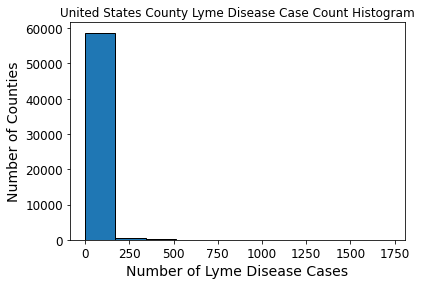

```python
import matplotlib.pyplot as plt
%matplotlib inline

plt.hist(LD_clean_df.CaseCount, edgecolor='black')

plt.xlabel('Number of Lyme Disease Cases')
plt.ylabel('Number of Counties')
plt.title('United States County Lyme Disease Case Count Histogram')

plt.show()
```

There are clearly a lot more cases in the lowest range shown above. The maximum number of cases in the dataset for a single county or county equivalent was 1,720 while the minimum number of cases was 0 (shown below).

```python
print("Maximum number of cases:", max(LD_clean_df.CaseCount))
print("Minimum number of cases:", min(LD_clean_df.CaseCount))
```

```
Maximum number of cases: 1720.0
Minimum number of cases: 0.0
```

Recall the maximum frequency of Lyme disease in a county or county equivalent was approximately 0.0158 and occurred in Columbia County, New York in 2002. The maximum case count of Lyme disease in a county or county equivalent was approximately 1,720 and occurred in Dutchess County, New York also in 2002. Its frequency was approximately 0.006. The maximum frequency and case count both occurred in New York which is a state in the Northeast.

```python
i = LD_clean_df['CaseCount'].argmax()
print(LD_clean_df.loc[i,'Ctyname'], ',' , LD_clean_df.loc[i,'Stname'])
print('Lyme disease case count:', LD_clean_df['CaseCount'].max())
```

```
Dutchess County , New York
Lyme disease case count: 1720.0
```

```python
LD_clean_df.iloc[[i]]
```

|  | Ctyname | Stname | STCODE | CTYCODE | Year | CaseCount | Population | Frequency | AREALAND | CENTLAT | CENTLON | Population Density | Percent Forest Area | Precipitation | Average Temperature | Maximum Temperature | Minimum Temperature |
| --- | --- | --- | --- | --- | --- | --- | --- | --- | --- | --- | --- | --- | --- | --- | --- | --- | --- |
| 34867 | Dutchess County | New York | 36.0 | 27.0 | 2002 | 1720.0 | 287700.0 | 0.005978 | 2.060721e+09 | 41.764859 | -73.742911 | 0.00014 | 0.628825 | 44.74 | 50.5 | 61.0 | 40.0 |

The 11 states that make up the United States Northeast Region are Connecticut, Delaware, Maine, Massachusetts, Maryland, New Hampshire, New Jersey, New York, Pennsylvania, Rhode Island, and Vermont. The Northeast and Connecticut county-level case count means were found.

```python
import statistics

print("Mean number of county cases in the Northeast:",
      statistics.mean(LD_clean_df.CaseCount.loc[(LD_clean_df['Stname']=='Connecticut') |
                          (LD_clean_df['Stname']=='Delaware') |
                          (LD_clean_df['Stname']=='Maine') |
                          (LD_clean_df['Stname']=='Massachusetts') |
                          (LD_clean_df['Stname']=='Maryland') |
                          (LD_clean_df['Stname']=='New Hampshire') |
                          (LD_clean_df['Stname']=='New Jersey') |
                          (LD_clean_df['Stname']=='New York') |
                          (LD_clean_df['Stname']=='Pennsylvania') |
                          (LD_clean_df['Stname']=='Rhode Island') |
                          (LD_clean_df['Stname']=='Vermont')]))
print("Mean number of county cases in Connecticut:",
      statistics.mean(LD_clean_df.CaseCount.loc[LD_clean_df['Stname']=='Connecticut']))
```

```
Mean number of county cases in the Northeast: 94.57290767903365
Mean number of county cases in Connecticut: 280.4078947368421
```

The mean number of yearly reported cases per county in the Northeast from 2000-2018 is approximately 95. The mean number of yearly reported cases per county in Connecticut from 2000-2018 is approximately 281 (rounded up since cannot have part of a person).

The two scatter plots below show the relationship between forest area and Lyme disease case count and frequency. The relationship between both scatterplots look moderately similar. It looks like the highest case counts and frequencies occurred where the percentage of forest area was around 60%. There was definitley not as many or as high case counts and frequencies where the percentage of forest area was below 30%.

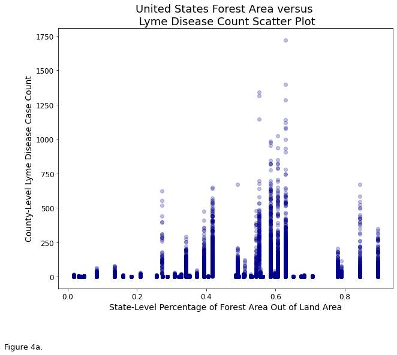

```python
from matplotlib.pyplot import figure
%matplotlib inline

# Figure
fig = figure(1, figsize=(10, 8))

# Plot
plt.scatter(x=LD_clean_df['Percent Forest Area'], y=LD_clean_df['CaseCount'],
            color='DarkBlue', alpha=0.25)

# Labels
plt.xlabel('State-Level Percentage of Forest Area Out of Land Area')
plt.ylabel('County-Level Lyme Disease Case Count')
plt.title('United States Forest Area versus \n Lyme Disease Count Scatter Plot', fontsize=18)

# Figure Number
plt.figtext(0, -.05, "Figure 4a.", fontsize=13)

plt.show()
```

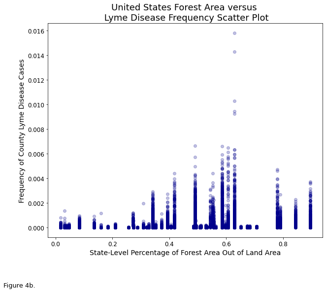

```python
from matplotlib.pyplot import figure
%matplotlib inline

# Figure
fig = figure(1, figsize=(10, 8))

# Plot
plt.scatter(x=LD_clean_df['Percent Forest Area'], y=LD_clean_df['Frequency'],
            color='DarkBlue', alpha=0.25)

# Labels
plt.xlabel('State-Level Percentage of Forest Area Out of Land Area')
plt.ylabel('Frequency of County Lyme Disease Cases')
plt.title('United States Forest Area versus \n Lyme Disease Frequency Scatter Plot', fontsize=18)

# Figure Number
plt.figtext(0, -.05, "Figure 4b.", fontsize=13)

plt.show()
```

Figure 4c shown below displays the same scatterplot as Figure 4b, but with different coloring. The coloring in the scatterplot shown below is based on the amount of precipitation each observation or county accumulated within the year. The coloring is described in the colorbar displayed on the right side of the figure.

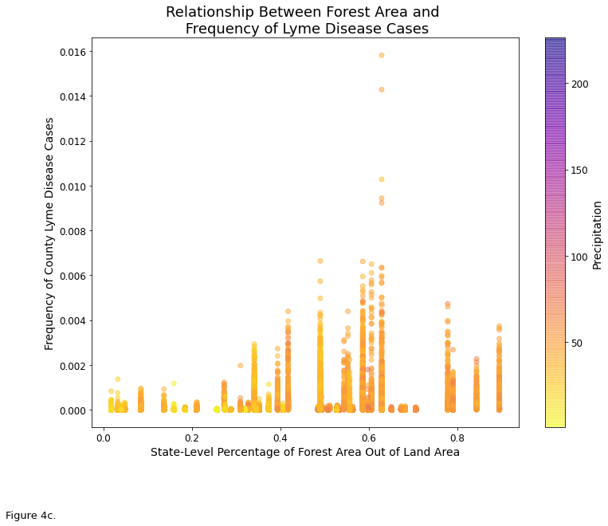

```python
import matplotlib.pyplot as plt
%matplotlib inline

# Figure
fig, ax1 = plt.subplots()
fig.set_size_inches(12, 9)

#c sequence
c = LD_clean_df['Precipitation']

# Plot
plt.scatter(x=LD_clean_df['Percent Forest Area'], y=LD_clean_df['Frequency'],
            c=c, cmap='plasma_r', alpha=0.5)

# Labels
ax1.set_title('Relationship Between Forest Area and \n Frequency of Lyme Disease Cases',
              fontsize=18)
ax1.set_xlabel('State-Level Percentage of Forest Area Out of Land Area')
ax1.set_ylabel('Frequency of County Lyme Disease Cases')

# Colorbar
cbar = plt.colorbar()
cbar.set_label('Precipitation')

# Figure Number
plt.figtext(0, -.05, "Figure 4c.", fontsize=13)

plt.show()
```

Below are some more visualizations that helped interpret the data.

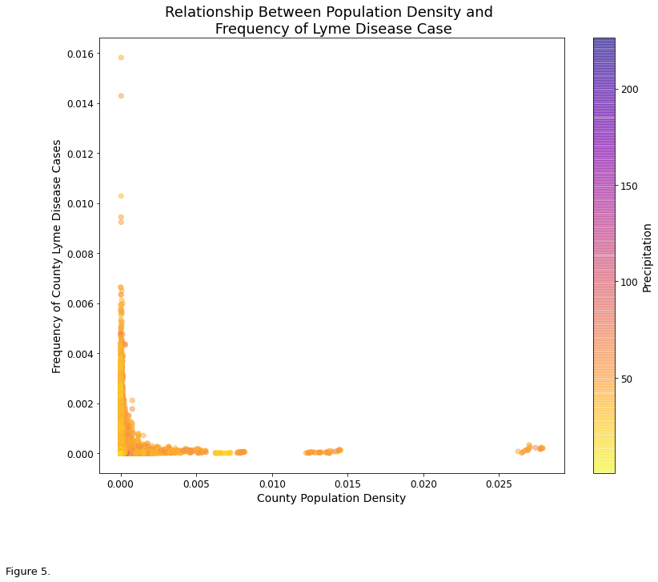

```python
import matplotlib.pyplot as plt
%matplotlib inline

# Figure
fig, ax1 = plt.subplots()
fig.set_size_inches(13, 10)

#c sequence
c = LD_clean_df['Precipitation']

# Plot
plt.scatter(x=LD_clean_df['Population Density'], y=LD_clean_df['Frequency'],
            c=c, cmap='plasma_r', alpha=0.5)

# Labels
ax1.set_title('Relationship Between Population Density and \n Frequency of Lyme Disease Case',
              fontsize=18)
ax1.set_xlabel('County Population Density')
ax1.set_ylabel('Frequency of County Lyme Disease Cases')

# Colorbar
cbar = plt.colorbar()
cbar.set_label('Precipitation')

# Figure Number
plt.figtext(0, -.05, "Figure 5.", fontsize=13)

plt.show()
```

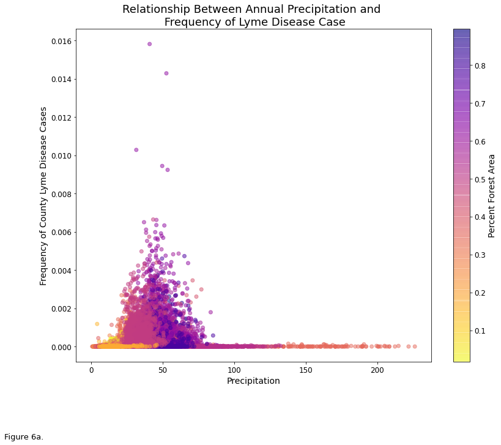

```python
import matplotlib.pyplot as plt
%matplotlib inline

# Figure
fig, ax1 = plt.subplots()
fig.set_size_inches(13, 10)

#c sequence
c = LD_clean_df['Percent Forest Area']

# Plot
plt.scatter(x=LD_clean_df['Precipitation'], y=LD_clean_df['Frequency'],
            c=c, cmap='plasma_r', alpha=0.5)

# Labels
ax1.set_title('Relationship Between Annual Precipitation and \n Frequency of Lyme Disease Case',
              fontsize=18)
ax1.set_xlabel('Precipitation')
ax1.set_ylabel('Frequency of County Lyme Disease Cases')

# Colorbar
cbar = plt.colorbar()
cbar.set_label('Percent Forest Area')

# Figure Number
plt.figtext(0, -.05, "Figure 6a.", fontsize=13)

plt.show()
```

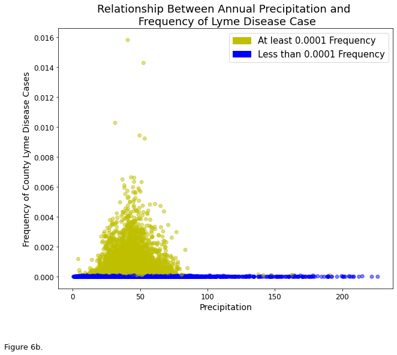

```python
import matplotlib.pyplot as plt
import matplotlib.patches as mpatches
%matplotlib inline

# Figure
fig, ax1 = plt.subplots()
fig.set_size_inches(10, 8)

#c sequence and color
color = np.where(LD_clean_df["Frequency"]>=0.0001,'y','b')

# Plot
plt.scatter(x=LD_clean_df['Precipitation'], y=LD_clean_df['Frequency'],
            c=color, alpha=0.5)

# Labels
ax1.set_title('Relationship Between Annual Precipitation and \n Frequency of Lyme Disease Case',
              fontsize=18)
ax1.set_xlabel('Precipitation')
ax1.set_ylabel('Frequency of County Lyme Disease Cases')

# Legend
yel_patch = mpatches.Patch(color='y', label='At least 0.0001 Frequency')
blu_patch = mpatches.Patch(color='b', label='Less than 0.0001 Frequency')
plt.legend(handles=[yel_patch, blu_patch], prop={'size': 15})

# Figure Number
plt.figtext(0, -.05, "Figure 6b.", fontsize=13)

plt.show()
```

Below describes the counts, means, standard deviations, minimums, quartiles, and maximums of some of the variables in the Lyme disease dataset.

```python
LD_clean_df.iloc[:,5:].describe()
```

|  | CaseCount | Population | Frequency | AREALAND | CENTLAT | CENTLON | Population Density | Percent Forest Area | Precipitation | Average Temperature | Maximum Temperature | Minimum Temperature |
| --- | --- | --- | --- | --- | --- | --- | --- | --- | --- | --- | --- | --- |
| count | 59584.000000 | 5.958400e+04 | 59584.000000 | 5.958400e+04 | 59584.000000 | 59584.000000 | 5.958400e+04 | 59584.000000 | 59584.000000 | 59584.000000 | 59584.000000 | 59584.000000 |
| mean | 9.096788 | 9.705477e+04 | 0.000082 | 2.909894e+09 | 38.477041 | -92.172289 | 9.975636e-05 | 0.412951 | 39.641565 | 54.901118 | 66.008115 | 43.787372 |
| std | 48.531688 | 3.129454e+05 | 0.000354 | 9.364881e+09 | 5.256585 | 12.674421 | 6.742124e-04 | 0.210403 | 16.864384 | 8.440346 | 8.814469 | 8.315460 |
| min | 0.000000 | 5.500000e+01 | 0.000000 | 5.141806e+06 | 25.039041 | -174.938398 | 1.413260e-08 | 0.017210 | 0.620000 | 13.600000 | 20.100000 | 6.900000 |
| 25% | 0.000000 | 1.106900e+04 | 0.000000 | 1.116657e+09 | 34.714036 | -98.208678 | 6.507519e-06 | 0.288057 | 27.927500 | 48.700000 | 59.500000 | 37.800000 |
| 50% | 0.000000 | 2.548500e+04 | 0.000000 | 1.595510e+09 | 38.395143 | -90.368520 | 1.712622e-05 | 0.393634 | 40.040000 | 54.900000 | 66.000000 | 43.800000 |
| 75% | 1.000000 | 6.562725e+04 | 0.000007 | 2.392091e+09 | 41.823456 | -83.425831 | 4.317556e-05 | 0.586066 | 49.880000 | 61.300000 | 72.900000 | 49.800000 |
| max | 1720.000000 | 1.012054e+07 | 0.015811 | 3.769299e+11 | 69.451496 | -67.608540 | 2.789184e-02 | 0.894676 | 226.290000 | 78.600000 | 90.000000 | 70.700000 |

The counties shown below would be considered high incidence counties that have less than 20% forest area in their respective state.

```python
LD_clean_df.loc[(LD_clean_df.Frequency>=0.0001) &
                (LD_clean_df['Percent Forest Area']<0.2)]
```

|  | Ctyname | Stname | STCODE | CTYCODE | Year | CaseCount | Population | Frequency | AREALAND | CENTLAT | CENTLON | Population Density | Percent Forest Area | Precipitation | Average Temperature | Maximum Temperature | Minimum Temperature |
| --- | --- | --- | --- | --- | --- | --- | --- | --- | --- | --- | --- | --- | --- | --- | --- | --- | --- |
| 11219 | Alexander County | Illinois | 17.0 | 3.0 | 2009 | 1.0 | 8295.0 | 0.000121 | 6.096329e+08 | 37.191486 | -89.337522 | 1.360655e-05 | 0.136440 | 51.80 | 57.0 | 66.9 | 47.2 |
| 11284 | Brown County | Illinois | 17.0 | 9.0 | 2017 | 1.0 | 6611.0 | 0.000151 | 7.918474e+08 | 39.961728 | -90.750324 | 8.348831e-06 | 0.136440 | 38.22 | 55.0 | 65.4 | 44.6 |
| 11311 | Calhoun County | Illinois | 17.0 | 13.0 | 2006 | 1.0 | 5174.0 | 0.000193 | 6.574172e+08 | 39.168947 | -90.667294 | 7.870192e-06 | 0.136440 | 32.21 | 56.3 | 66.8 | 45.7 |
| 11331 | Carroll County | Illinois | 17.0 | 15.0 | 2007 | 6.0 | 15734.0 | 0.000381 | 1.153440e+09 | 42.068735 | -89.934276 | 1.364094e-05 | 0.136440 | 36.48 | 49.6 | 59.7 | 39.4 |
| 11332 | Carroll County | Illinois | 17.0 | 15.0 | 2008 | 3.0 | 15638.0 | 0.000192 | 1.153440e+09 | 42.068735 | -89.934276 | 1.355771e-05 | 0.136440 | 45.59 | 46.8 | 57.0 | 36.5 |
| ... | ... | ... | ... | ... | ... | ... | ... | ... | ... | ... | ... | ... | ... | ... | ... | ... | ... |
| 45232 | Grant County | South Dakota | 46.0 | 51.0 | 2012 | 1.0 | 7397.0 | 0.000135 | 1.764956e+09 | 45.171960 | -96.767495 | 4.191040e-06 | 0.039387 | 19.74 | 47.1 | 58.5 | 35.8 |
| 45236 | Grant County | South Dakota | 46.0 | 51.0 | 2016 | 1.0 | 7219.0 | 0.000139 | 1.764956e+09 | 45.171960 | -96.767495 | 4.090187e-06 | 0.039387 | 27.41 | 46.5 | 56.7 | 36.2 |
| 45706 | Moody County | South Dakota | 46.0 | 101.0 | 2011 | 1.0 | 6499.0 | 0.000154 | 1.345187e+09 | 44.021914 | -96.670922 | 4.831298e-06 | 0.039387 | 27.67 | 44.0 | 54.4 | 33.6 |
| 59318 | Johnson County | Wyoming | 56.0 | 19.0 | 2000 | 1.0 | 7108.0 | 0.000141 | 1.075920e+10 | 44.037653 | -106.584396 | 6.606437e-07 | 0.184229 | 12.89 | 44.0 | 56.9 | 31.0 |
| 59326 | Johnson County | Wyoming | 56.0 | 19.0 | 2008 | 1.0 | 8460.0 | 0.000118 | 1.075920e+10 | 44.037653 | -106.584396 | 7.863035e-07 | 0.184229 | 16.93 | 42.4 | 55.0 | 29.7 |

411 rows × 17 columns

The New York counties shown below (New York counties with a frequency less than 0.0001) had higher population densities than the counties shown above which had frequencies greater than or equal to 0.0001 and forest area percentages less than 0.2. The population density might be able to account for some of that variation or partially explain why counties with lower percentages of forest areas in their state have a higher Lyme disease case frequency than some other counties that have higher state percentages of forest area.

```python
LD_clean_df[(LD_clean_df.Stname=='New York') & (LD_clean_df['Frequency']<0.0001)]
```

|  | Ctyname | Stname | STCODE | CTYCODE | Year | CaseCount | Population | Frequency | AREALAND | CENTLAT | CENTLON | Population Density | Percent Forest Area | Precipitation | Average Temperature | Maximum Temperature | Minimum Temperature |
| --- | --- | --- | --- | --- | --- | --- | --- | --- | --- | --- | --- | --- | --- | --- | --- | --- | --- |
| 34637 | Allegany County | New York | 36.0 | 3.0 | 2000 | 0.0 | 49819.0 | 0.000000 | 2.666244e+09 | 42.257150 | -78.027533 | 0.000019 | 0.628825 | 38.83 | 45.0 | 55.5 | 34.6 |
| 34638 | Allegany County | New York | 36.0 | 3.0 | 2001 | 1.0 | 50079.0 | 0.000020 | 2.666244e+09 | 42.257150 | -78.027533 | 0.000019 | 0.628825 | 29.99 | 46.6 | 57.4 | 35.8 |
| 34639 | Allegany County | New York | 36.0 | 3.0 | 2002 | 1.0 | 50014.0 | 0.000020 | 2.666244e+09 | 42.257150 | -78.027533 | 0.000019 | 0.628825 | 42.12 | 46.3 | 56.7 | 35.9 |
| 34640 | Allegany County | New York | 36.0 | 3.0 | 2003 | 2.0 | 50165.0 | 0.000040 | 2.666244e+09 | 42.257150 | -78.027533 | 0.000019 | 0.628825 | 46.66 | 44.2 | 54.8 | 33.6 |
| 34641 | Allegany County | New York | 36.0 | 3.0 | 2004 | 2.0 | 50311.0 | 0.000040 | 2.666244e+09 | 42.257150 | -78.027533 | 0.000019 | 0.628825 | 45.95 | 45.4 | 55.5 | 35.2 |
| ... | ... | ... | ... | ... | ... | ... | ... | ... | ... | ... | ... | ... | ... | ... | ... | ... | ... |
| 35783 | Yates County | New York | 36.0 | 123.0 | 2006 | 1.0 | 25025.0 | 0.000040 | 8.758021e+08 | 42.633423 | -77.105359 | 0.000029 | 0.628825 | 36.22 | 48.8 | 58.1 | 39.5 |
| 35784 | Yates County | New York | 36.0 | 123.0 | 2007 | 0.0 | 25234.0 | 0.000000 | 8.758021e+08 | 42.633423 | -77.105359 | 0.000029 | 0.628825 | 33.30 | 47.3 | 57.1 | 37.5 |
| 35785 | Yates County | New York | 36.0 | 123.0 | 2008 | 0.0 | 25352.0 | 0.000000 | 8.758021e+08 | 42.633423 | -77.105359 | 0.000029 | 0.628825 | 37.30 | 47.2 | 56.8 | 37.6 |
| 35786 | Yates County | New York | 36.0 | 123.0 | 2009 | 0.0 | 25303.0 | 0.000000 | 8.758021e+08 | 42.633423 | -77.105359 | 0.000029 | 0.628825 | 30.23 | 46.2 | 56.0 | 36.5 |
| 35787 | Yates County | New York | 36.0 | 123.0 | 2010 | 1.0 | 25348.0 | 0.000039 | 8.758021e+08 | 42.633423 | -77.105359 | 0.000029 | 0.628825 | 36.94 | 48.3 | 57.3 | 39.4 |

573 rows × 17 columns

Exploring Connecticut data:

```python
LD_clean_df[LD_clean_df.Stname=='Connecticut']
```

|  | Ctyname | Stname | STCODE | CTYCODE | Year | CaseCount | Population | Frequency | AREALAND | CENTLAT | CENTLON | Population Density | Percent Forest Area | Precipitation | Average Temperature | Maximum Temperature | Minimum Temperature |
| --- | --- | --- | --- | --- | --- | --- | --- | --- | --- | --- | --- | --- | --- | --- | --- | --- | --- |
| 5833 | Fairfield County | Connecticut | 9.0 | 1.0 | 2000 | 1342.0 | 884364.0 | 0.001517 | 1.618659e+09 | 41.224715 | -73.371249 | 0.000546 | 0.552436 | 48.34 | 49.6 | 59.3 | 39.9 |
| 5834 | Fairfield County | Connecticut | 9.0 | 1.0 | 2001 | 1146.0 | 889063.0 | 0.001289 | 1.618659e+09 | 41.224715 | -73.371249 | 0.000549 | 0.552436 | 40.45 | 51.4 | 61.5 | 41.2 |
| 5835 | Fairfield County | Connecticut | 9.0 | 1.0 | 2002 | 1313.0 | 892900.0 | 0.001470 | 1.618659e+09 | 41.224715 | -73.371249 | 0.000552 | 0.552436 | 49.80 | 51.8 | 61.7 | 41.8 |
| 5836 | Fairfield County | Connecticut | 9.0 | 1.0 | 2003 | 335.0 | 896342.0 | 0.000374 | 1.618659e+09 | 41.224715 | -73.371249 | 0.000554 | 0.552436 | 57.62 | 49.4 | 58.7 | 40.2 |
| 5837 | Fairfield County | Connecticut | 9.0 | 1.0 | 2004 | 330.0 | 897472.0 | 0.000368 | 1.618659e+09 | 41.224715 | -73.371249 | 0.000554 | 0.552436 | 49.97 | 50.4 | 59.9 | 41.0 |
| ... | ... | ... | ... | ... | ... | ... | ... | ... | ... | ... | ... | ... | ... | ... | ... | ... | ... |
| 5980 | Windham County | Connecticut | 9.0 | 15.0 | 2014 | 162.0 | 116769.0 | 0.001387 | 1.329038e+09 | 41.829858 | -71.987545 | 0.000088 | 0.552436 | 45.58 | 48.1 | 58.1 | 38.1 |
| 5981 | Windham County | Connecticut | 9.0 | 15.0 | 2015 | 197.0 | 116468.0 | 0.001691 | 1.329038e+09 | 41.829858 | -71.987545 | 0.000088 | 0.552436 | 37.91 | 49.0 | 59.6 | 38.3 |
| 5982 | Windham County | Connecticut | 9.0 | 15.0 | 2016 | 148.0 | 116052.0 | 0.001275 | 1.329038e+09 | 41.829858 | -71.987545 | 0.000087 | 0.552436 | 39.90 | 51.2 | 61.7 | 40.7 |
| 5983 | Windham County | Connecticut | 9.0 | 15.0 | 2017 | 122.0 | 116374.0 | 0.001048 | 1.329038e+09 | 41.829858 | -71.987545 | 0.000088 | 0.552436 | 47.20 | 50.5 | 60.3 | 40.8 |
| 5984 | Windham County | Connecticut | 9.0 | 15.0 | 2018 | 149.0 | 117027.0 | 0.001273 | 1.329038e+09 | 41.829858 | -71.987545 | 0.000088 | 0.552436 | 63.42 | 50.4 | 59.7 | 41.1 |

152 rows × 17 columns

Some Connecticut counties with low incidence:

```python
LD_clean_df.loc[(LD_clean_df.Stname=='Connecticut') & (LD_clean_df['Frequency']<0.0001)]
```

|  | Ctyname | Stname | STCODE | CTYCODE | Year | CaseCount | Population | Frequency | AREALAND | CENTLAT | CENTLON | Population Density | Percent Forest Area | Precipitation | Average Temperature | Maximum Temperature | Minimum Temperature |
| --- | --- | --- | --- | --- | --- | --- | --- | --- | --- | --- | --- | --- | --- | --- | --- | --- | --- |
| 5855 | Hartford County | Connecticut | 9.0 | 3.0 | 2003 | 59.0 | 873335.0 | 0.000068 | 1.903535e+09 | 41.806273 | -72.732804 | 0.000459 | 0.552436 | 56.95 | 48.5 | 58.6 | 38.3 |
| 5856 | Hartford County | Connecticut | 9.0 | 3.0 | 2004 | 73.0 | 874449.0 | 0.000083 | 1.903535e+09 | 41.806273 | -72.732804 | 0.000459 | 0.552436 | 47.11 | 49.2 | 59.4 | 38.9 |
| 5912 | New Haven County | Connecticut | 9.0 | 9.0 | 2003 | 71.0 | 841939.0 | 0.000084 | 1.565683e+09 | 41.348686 | -72.899626 | 0.000538 | 0.552436 | 58.17 | 48.7 | 58.1 | 39.2 |

The high number of unknowns in Connecticut could cause an issue with classification because if the "unknowns" were in the counties with low incidence, then they could be high incidence. For the rest of the Connecticut observations which are high, the "unknowns" would not affect their Incidence class label.

```python
LDcounts_uk_df.loc[LDcounts_uk_df.Stname=='Connecticut']
```

|  | index | Ctyname | Stname | STCODE | CTYCODE | Cases2000 | Cases2001 | Cases2002 | Cases2003 | Cases2004 | Cases2005 | Cases2006 | Cases2007 | Cases2008 | Cases2009 | Cases2010 | Cases2011 | Cases2012 | Cases2013 | Cases2014 | Cases2015 | Cases2016 | Cases2017 | Cases2018 |
| --- | --- | --- | --- | --- | --- | --- | --- | --- | --- | --- | --- | --- | --- | --- | --- | --- | --- | --- | --- | --- | --- | --- | --- | --- |
| 6 | 322 | Connecticut | Connecticut | 9 | 999 | 111 | 122 | 135 | 52 | 47 | 57 | 32 | 704 | 1635 | 1126 | 1448 | 1432 | 1402 | 597 | 49 | 33 | 20 | 68 | 16 |

```python
# if all Connecticut 2004 unknowns were from Hartford County
uk = LDcounts_uk_df.loc[LDcounts_uk_df.Stname=='Connecticut','Cases2004'].values[0]
k = LD_clean_df.loc[(LD_clean_df.Stname=='Connecticut') &
                    (LD_clean_df.Ctyname=='Hartford County') &
                    (LD_clean_df.Year==2004), 'CaseCount'].values[0]
p = LD_clean_df.loc[(LD_clean_df.Stname=='Connecticut') &
                    (LD_clean_df.Ctyname=='Hartford County') &
                    (LD_clean_df.Year==2004), 'Population'].values[0]
print('Frequency:', (uk+k)/p)
```

```
Frequency: 0.00013722927237609054
```

```python
import math

# if all Connecticut 2004 unknowns were from Hartford County
uk = LDcounts_uk_df.loc[LDcounts_uk_df.Stname=='Connecticut','Cases2004'].values[0]
k = LD_clean_df.loc[(LD_clean_df.Stname=='Connecticut') &
                    (LD_clean_df.Ctyname=='Hartford County') &
                    (LD_clean_df.Year==2004), 'CaseCount'].values[0]
p = LD_clean_df.loc[(LD_clean_df.Stname=='Connecticut') &
                    (LD_clean_df.Ctyname=='Hartford County') &
                    (LD_clean_df.Year==2004), 'Population'].values[0]
minUK = 0.0001*p-k #14.444900000000004
print('Minimum number of unknowns:', math.ceil(minUK))
# minUK/uk = 0.3073382978723405
print(math.ceil(minUK)/uk)
totp = sum(LD_clean_df.loc[(LD_clean_df.Stname=='Connecticut') &
                    (LD_clean_df.Year==2004), 'Population'])
print('Population Proportion:', p/totp)
```

```
Minimum number of unknowns: 15
0.3191489361702128
Population Proportion: 0.25012170725386673
```

There are eight counties in Connecticut. If a little less than 1/3 of the number of "unknowns" were from Hartford County, then Hartford County would have a high incidence of Lyme disease. 1/3 is greater than 1/8 of the number of unknowns and greater than the proportion of the Hartford County population in Connecticut which is about 1/4. Thus, it might not cause that much of an issue unless at least about 32% of Connecticut "unknowns" reside in Hartford County. This is just one example, and the number of "unknowns" could be a factor in other states and counties and county equivalents.